# Causal verbs: adult and child descriptive analysis

This workflow describes how often participants answer **Yes** about the earlier (**distal**) and later (**proximal**) agents in two causal-chain studies. Study 1 is the baseline chain. Study 2 compares intentional and accidental actions by the distal agent. The main talk figure shows Study 2 minus the Study 1 baseline for each age, measure and role. A second summary pools Study 2 child ages and compares participant-level Distal-minus-Proximal gaps between the Intentional and Accidental conditions. Raw Yes-response figures remain available as backups. Single Cause adds the one-agent comparison using children aged 3–6 and all 32 recovered adults. A new synthesis compares intention effects in Single Cause and Study 2 using children aged 3–6 in both studies. The historical Single Cause N=30 subset remains unidentified. Three additional stage-grouped synthesis figures show punishment by causal target, all four Single Cause judgments, and Caused/Lexical role mapping in Studies 1 and 2. They display raw Yes proportions at ages 3–4, 5–6 and Adults. This workflow prepares descriptive summaries and cumulative talk figures. The new Study 1 role-differentiation synthesis additionally fits exploratory participant-level associations, with and without categorical age adjustment.

**This is a new reproducible reconstruction from available data and documented design, not recovered original analysis code.** The old verbal plotting scripts remain missing. The new child exports are the snapshots supplied on September 20, 2026. Study 2 collection remains ongoing, and its adult comparison is an earlier pilot, not the missing preregistered main adult dataset.

The organization follows the read-only [counterfactual development Rmd](https://github.com/cicl-stanford/counterfactual_development/blob/a6aabb292549337bdeb220230f3471fd885b8fed/code/R/counterfactuals.Rmd), [cookie-task Rmd](https://github.com/explanation-lab/cookie-task/blob/295eb985903ec38af4f5ca07df50603729e21d8b/current/code/R/cookie_allocation.Rmd) and [running guide](https://github.com/explanation-lab/cookie-task/blob/295eb985903ec38af4f5ca07df50603729e21d8b/current/code/R/README.md), and [cause/burn development Rmd](https://github.com/davdrose/cause_burn_development/blob/48b6aa48e3dad0f3a991e0f5a4842563bfdcbb94/code/R/main.Rmd). Local reference revisions were respectively `a6aabb2`, `295eb98`, and `48b6aa4`. We follow cookie-task’s principle of selecting one attempt per child and computing summaries once for all builds. We do not import its study-specific eligibility rules or the reference projects’ inferential models.

## Scope and decisions to review

The Study 1 and Study 2 child preregistration documents require complete test responses from children aged 3–9 who answer without help. They also specify the first 30 eligible children per age cell (per condition in Study 2), ordered by completion timestamp. **The requested descriptive snapshot below retains all otherwise eligible unique children; it does not apply those sample caps.** Some cells exceed 30 and others fall below 30. This is not a finalized preregistered analysis. The exports provide session creation times, not completion times, and cannot independently establish whether adults helped with answers. The supplied eligibility/exclusion flags are respected; behavioral eligibility and the cap rule still need confirmation for a registered analysis.

Neither child preregistration nor the available study notes specifies how to choose among repeat attempts by the same child. We therefore use the requested deterministic reconstruction rule: among otherwise eligible attempts, retain the most answered test questions, breaking ties by the latest `date_created_utc`. Never combine trials across attempts. A Study 2 child who repeats in another condition still contributes only one attempt in total.

# Load packages

Knitting runs code from this file’s directory, `current/code/R/`. CSV values are read as text first, so identifiers and export labels are not silently changed. No packages are installed by this document.

```r
library(dplyr)       # select, filter, join, and summarize rows
library(tidyr)       # move between wide and long tables
library(readr)       # read CSV files
library(ggplot2)     # figures
library(knitr)       # report tables
```

Single Cause has no separate preregistration in the repository. Its section uses the supplied inclusion/withdrawal flags and audits the current snapshot.

# Settings

All presentation settings and snapshot expectations live here. Expected counts are checks on these particular exports, not values used to calculate results. A changed export stops the workflow so its inclusion decisions can be reviewed.

```r
knitr::opts_chunk$set(echo = TRUE, warning = TRUE, message = FALSE,
                     error = FALSE, cache = FALSE, fig.width = 16,
                     fig.height = 12.8, out.width = "100%")
theme_set(theme_classic(base_family = "sans"))
options(dplyr.summarise.inform = FALSE)

measure_order = c("Caused", "Lexical", "Fault", "Punish")
condition_order = c("Intentional", "Accidental")
role_order = c("Distal", "Proximal")
scenario_order = c("Bike", "Mirror")
child_ages = 3:9
adult_position = 10
age_breaks = c(child_ages, adult_position)
age_labels = c(as.character(child_ages), "Adult")

# In the raw figures, color identifies causal role. Use the exact ColorBrewer values
# directly, avoiding an extra package dependency for two fixed hex codes.
study1_role_colors = c(Distal = "#E41A1C", Proximal = "#377EB8") # Set1
study2_role_colors = study1_role_colors
study1_role_shapes = c(Distal = 21, Proximal = 22)
study1_role_offsets = c(Distal = -.06, Proximal = .06)
study2_role_offsets = c(Distal = -.10, Proximal = .10)
condition_shapes = c(Intentional = 21, Accidental = 24)
condition_lines = c(Intentional = "solid", Accidental = "dashed")
condition_offsets = c(Intentional = -.05, Accidental = .05)
# Define intention colors once for comparison, pooled-summary and Single Cause figures.
comparison_colors = c(Intentional = "#6A3D9A", Accidental = "#1B9E77")
comparison_offsets = c(Intentional = -.07, Accidental = .07)

bootstrap_seed = 20260920
bootstrap_replicates = 5000
study1_width = 16
study1_height = 12.8
# Keep the reference's measured 1920 x 1536 (5:4) aspect and 2 x 2 panels.
study2_width = 16
study2_height = 12.8
png_dpi = 240
study1_text_size = 30
study2_text_size = 30
plot_point_size = 4.2
plot_line_width = .9
ci_line_width = .65
comparison_width = 16
comparison_height = 9
comparison_text_size = 20
comparison_point_size = 2.8
comparison_adult_position = 10.8
comparison_min_y_limit = .5
comparison_y_step = .25
intention_width = 16
intention_height = 9
intention_text_size = 26
gap_y_step = 25
intention_offsets = c(Intentional = -.08, Accidental = .08)

study1_output = "../../figures/study1_baseline_causal_chains/talk"
study2_output = "../../figures/study2_intention_causal_chains/talk"
comparison_output = "../../figures/study_comparison_baseline_change"
single_output = "../../figures/single_cause/talk"
synthesis_output = "../../figures/study_comparison"
synthesis_ages = 3:6
synthesis_order = c("Single Cause", "Study 2 Distal", "Study 2 Proximal")
synthesis_colors = c("Single Cause" = "#666666",
                     "Study 2 Distal" = study2_role_colors[["Distal"]],
                     "Study 2 Proximal" = study2_role_colors[["Proximal"]])
synthesis_shapes = c("Single Cause" = 15, "Study 2 Distal" = 16, "Study 2 Proximal" = 17)
synthesis_offsets = c("Single Cause" = -.20, "Study 2 Distal" = 0, "Study 2 Proximal" = .20)
single_child_ages = 3:6
single_adult_position = 7.5
single_expected_ns = tibble(
  age = rep(3:6, each = 2), condition = rep(c("Accidental", "Intentional"), times = 4),
  n = c(12L, 14L, 14L, 10L, 10L, 13L, 10L, 13L))
study2_pilot_directory = paste0(
  "../../data/study2_intention_causal_chains/adults/",
  "adult_pilot_rounds_unordered")
study2_pilot_files = c(
  "adult_causation_and_punishment_new_updated_to_8_qs-responses.csv",
  "adult_causation_and_punishment_updated_to_8_qs_for-responses.csv",
  "causation_and_punishment_without_priming_test_verb-responses.csv",
  "exp2_new_pilot-responses.csv")
selected_pilot = "exp2_new_pilot-responses.csv"
snapshot_expectations = tibble(
  study = c("Study 1", "Study 2"), rows = c(3870L, 7523L),
  sessions = c(215L, 422L), children = c(212L, 416L),
  flagged_eligible = c(214L, 410L), retained_children = c(211L, 406L))

study1_build_names = c("build00_orientation", "build01_caused_adults",
                "build02_caused_children", "build03_lexical_adults",
                "build04_lexical_children", "build05_fault_adults",
                "build06_fault_children", "build07_punish_adults",
                "build08_full")
comparison_build_names = c("build00_orientation", "build01_caused",
                           "build02_lexical", "build03_fault", "build04_full")
single_build_names = c(
  "build00_orientation", "build01_caused_intentional_adults", "build02_caused_intentional_children",
  "build03_caused_accidental_adults", "build04_caused_accidental_children",
  "build05_lexical_intentional_adults", "build06_lexical_intentional_children",
  "build07_lexical_accidental_adults", "build08_lexical_accidental_children",
  "build09_fault_intentional_adults", "build10_fault_intentional_children",
  "build11_fault_accidental_adults", "build12_fault_accidental_children",
  "build13_punish_intentional_adults", "build14_punish_intentional_children",
  "build15_punish_accidental_adults", "build16_full")
study2_build_names = single_build_names
stage_order = c("3–4", "5–6", "Adults")
stage_target_order = c("Single Cause", "Chain: Distal", "Chain: Proximal")
stage_text_size = 22
# One fixed Set1 measure palette for the additional candidate syntheses.
# Existing role and condition palettes are unchanged.
measure_colors = c(Caused = "#E41A1C", Lexical = "#377EB8", Fault = "#4DAF4A", Punish = "#984EA3")
measure_shapes = c(Caused = 16, Lexical = 17, Fault = 15, Punish = 18)
sensitivity_offsets = c(Caused = -.06, Lexical = -.02, Fault = .02, Punish = .06)
stage_condition_offsets = c(Intentional = -.07, Accidental = .07)
dir.create(synthesis_output, recursive = TRUE, showWarnings = FALSE)
for (directory in c(study1_output, study2_output, comparison_output, single_output)) {
  dir.create(directory, recursive = TRUE, showWarnings = FALSE)
  dir.create(file.path(directory, "builds"),
             recursive = TRUE, showWarnings = FALSE)
}
```

# Helper functions

## Validate labels and recode yes/no

Unknown labels stop the analysis. Missing values are permitted only where we explicitly allow them, such as the empty Study 2 session placeholder. Missing responses never become “no”.

```r
check_labels = function(values, allowed, label, allow_missing = FALSE) {
  if ((!allow_missing && anyNA(values)) ||
      any(!is.na(values) & !values %in% allowed)) {
    stop(paste("Unexpected or missing", label, "- review the input."))
  }
}

yes_no = function(values) {
  check_labels(values, c("yes", "no"), "yes/no response", allow_missing = TRUE)
  case_when(values == "yes" ~ 1, values == "no" ~ 0, TRUE ~ NA_real_)
}
```

## Keep binary responses separate and average scenarios within participant

The input has one row per participant, scenario, measure, and agent: Yes = 1, No = 0. A response to one agent never changes the response to the other. “Both” contributes 1 to both role series; “neither” contributes 0 to both. No relative-distal transformation or endorsement-based exclusion is used.

`participant_means()` averages available Bike/Mirror answers **within each participant × measure × role**, keeping conditions separate. Its output has one row per participant and role-specific measure. A person with one available scenario has the same group weight as one with two. A missing answer affects only that question; if both scenarios are missing for a role/measure, only that participant mean is missing. Other roles and measures remain available.

`audit_patterns()` separately labels both/neither/distal-only/proximal-only patterns. A missing answer or absent partner row is labeled “missing answer.” This descriptive audit does not supply plotting values or determine inclusion. The existing session eligibility and repeat-attempt rules remain unchanged.

```r
check_response_rows = function(responses) {
  key = c("study", "population", "participant", "age", "condition",
          "scenario", "measure")
  check_labels(responses$population, c("Adults", "Children"), "population")
  check_labels(responses$scenario, scenario_order, "scenario")
  check_labels(responses$measure, measure_order, "measure")
  check_labels(responses$role, role_order, "agent role")
  check_labels(responses$condition, c("Baseline", condition_order), "condition")
  stopifnot(!anyNA(responses$participant),
            all(is.na(responses$endorsed) | responses$endorsed %in% 0:1),
            !anyDuplicated(responses[c(key, "role")]))
  invisible(TRUE)
}

audit_patterns = function(responses) {
  check_response_rows(responses)
  key = c("study", "population", "participant", "age", "condition", "scenario", "measure")
  responses %>%
    mutate(role = factor(role, levels = role_order)) %>%
    pivot_wider(id_cols = all_of(key), names_from = role,
                values_from = endorsed, names_expand = TRUE) %>%
    rename(distal_yes = Distal, proximal_yes = Proximal) %>%
    mutate(pattern = case_when(
      is.na(distal_yes) | is.na(proximal_yes) ~ "missing answer",
      distal_yes == 1 & proximal_yes == 1 ~ "both",
      distal_yes == 0 & proximal_yes == 0 ~ "neither",
      distal_yes == 1 ~ "distal only", TRUE ~ "proximal only"))
}

participant_means = function(responses) {
  check_response_rows(responses)
  responses %>%
    group_by(study, population, participant, age, condition, measure, role) %>%
    summarise(scenarios_available = sum(!is.na(endorsed)),
              yes_mean = if (all(is.na(endorsed))) NA_real_
                else mean(endorsed, na.rm = TRUE), .groups = "drop")
}
```

## Participant bootstrap

Each input row is already one participant’s mean for a measure and causal role. Within each plotted age/role/condition group, resample those participants with replacement 5,000 times. The 2.5th and 97.5th percentiles form the descriptive 95% interval. We do not resample trial rows or pool pilots. The later Study 1 relationship section separately fits exploratory associations and bootstraps their slopes. Family/household dependence is not modeled by these participant intervals.

```r
bootstrap_mean = function(values) {
  values = values[!is.na(values)]
  if (!length(values)) return(tibble(n = 0L, mean = NA_real_,
                                      lower = NA_real_, upper = NA_real_))
  draws = replicate(bootstrap_replicates,
                    mean(values[sample.int(length(values), replace = TRUE)]))
  tibble(n = length(values), mean = mean(values),
         lower = unname(quantile(draws, .025)),
         upper = unname(quantile(draws, .975)))
}

summarize_for_talk = function(means, seed) {
  stopifnot(!anyDuplicated(means[c("study", "population", "participant",
                                   "condition", "measure", "role")]))
  RNGkind("Mersenne-Twister", "Inversion", "Rejection")
  set.seed(seed)
  means %>%
    mutate(age_group = if_else(population == "Adults", "Adult", as.character(age)),
           measure = factor(measure, levels = measure_order),
           role = factor(role, levels = role_order)) %>%
    arrange(measure, role, condition, age_group, participant) %>%
    group_by(study, population, age_group, condition, measure, role) %>%
    summarise(eligible_n = n(), summary = list(bootstrap_mean(yes_mean)),
              .groups = "drop") %>%
    unnest_wider(summary) %>%
    mutate(x = match(age_group, age_labels) + min(child_ages) - 1)
}
```

## Presentation scaffolds and cumulative builds

All figures use the same computed summary rows throughout their builds. Small, fixed horizontal offsets separate overlapping roles/conditions; they never change with the number of revealed series. Child means are connected in age order; adults are a separate endpoint after the child ages, not part of a developmental line. Lines describe cross-sectional age groups, not within-child change.

The full legends, limits, factor levels, facets, and whitespace are specified even for Build 00. The theme is set once above; this helper only adjusts it.

```r
talk_theme = function(text_size) {
  theme(axis.text = element_text(size = text_size, color = "#242424"),
        axis.title = element_text(size = text_size + 2),
        axis.title.x = element_text(margin = margin(t = 14)),
        axis.title.y = element_text(margin = margin(r = 15)),
        axis.line = element_line(color = "#777777", linewidth = .5),
        axis.ticks = element_line(color = "#777777", linewidth = .5),
        strip.background = element_blank(),
        strip.text = element_text(size = text_size + 3, face = "bold"),
        panel.spacing = grid::unit(1.1, "cm"),
        legend.position = "bottom",
        legend.title = element_text(size = text_size - 4, face = "bold"),
        legend.text = element_text(size = text_size - 2),
        legend.key.width = grid::unit(1.5, "cm"),
        legend.spacing.x = grid::unit(.6, "cm"),
        legend.margin = margin(t = 12),
        plot.margin = margin(22, 24, 15, 18))
}

show_build = function(summary, step) {
  stopifnot(length(step) == 1L, step %in% 0:16)
  filter(summary, reveal_step <= step)
}

plot_study1 = function(summary, step = 8L) {
  visible = show_build(summary, step) %>%
    mutate(plot_x = x + unname(study1_role_offsets[as.character(role)]))
  ggplot(visible, aes(x = plot_x, y = mean, color = role,
                      fill = role, shape = role)) +
    geom_hline(yintercept = c(0, .25, .75, 1), linetype = "dotted", color = "#E0E0E0", linewidth = .45) +
    geom_hline(yintercept = .5, linetype = "dashed", color = "#888888", linewidth = .65) +
    geom_vline(xintercept = 9.5, linetype = "dotted", color = "#C0C0C0", linewidth = .5) +
    geom_line(data = filter(visible, population == "Children"),
              aes(group = role), linewidth = plot_line_width, show.legend = TRUE, na.rm = TRUE) +
    geom_linerange(aes(ymin = lower, ymax = upper),
                   linewidth = ci_line_width, show.legend = FALSE, na.rm = TRUE) +
    geom_point(size = plot_point_size, stroke = .8, show.legend = TRUE, na.rm = TRUE) +
    facet_wrap(~ measure, ncol = 2, drop = FALSE, axes = "all_x", axis.labels = "all_x") +
    scale_color_manual(name = NULL, values = study1_role_colors, limits = role_order, drop = FALSE) +
    scale_fill_manual(name = NULL, values = study1_role_colors, limits = role_order, drop = FALSE) +
    scale_shape_manual(name = NULL, values = study1_role_shapes, limits = role_order, drop = FALSE) +
    scale_x_continuous(breaks = age_breaks, labels = age_labels,
                       limits = c(2.6, 10.5), expand = expansion(mult = 0)) +
    scale_y_continuous(breaks = c(0, .25, .5, .75, 1),
                       labels = c("0%", "25%", "50%", "75%", "100%"),
                       limits = c(0, 1), expand = expansion(add = .035)) +
    labs(x = "Age", y = '"Yes" Responses (%)') +
    talk_theme(study1_text_size)
}

plot_study2 = function(summary, step = 16L) {
  visible = show_build(summary, step) %>%
    mutate(condition = factor(condition, levels = condition_order),
           plot_x = x + unname(study2_role_offsets[as.character(role)]) +
             unname(condition_offsets[as.character(condition)]),
           point_fill = if_else(condition == "Intentional",
                                unname(study2_role_colors[as.character(role)]), "white"))
  ggplot(visible, aes(x = plot_x, y = mean, color = role,
                      shape = condition, linetype = condition)) +
    geom_hline(yintercept = c(0, .25, .75, 1), linetype = "dotted", color = "#E0E0E0", linewidth = .45) +
    geom_hline(yintercept = .5, linetype = "dashed", color = "#888888", linewidth = .65) +
    geom_vline(xintercept = 9.5, linetype = "dotted", color = "#C0C0C0", linewidth = .5) +
    geom_line(data = filter(visible, population == "Children"),
              aes(group = interaction(role, condition)),
              linewidth = plot_line_width, show.legend = TRUE, na.rm = TRUE) +
    geom_linerange(aes(ymin = lower, ymax = upper),
                   linewidth = ci_line_width, show.legend = FALSE, na.rm = TRUE) +
    geom_point(aes(fill = point_fill), size = plot_point_size,
                stroke = .9, show.legend = TRUE, na.rm = TRUE) +
    facet_wrap(~ measure, ncol = 2, drop = FALSE, axes = "all_x", axis.labels = "all_x") +
    scale_color_manual(name = "Causal role", values = study2_role_colors,
                        limits = role_order, drop = FALSE) +
    scale_fill_identity(guide = "none") +
    scale_shape_manual(name = "Intention", values = condition_shapes, limits = condition_order, drop = FALSE) +
    scale_linetype_manual(name = "Intention", values = condition_lines, limits = condition_order, drop = FALSE) +
    guides(color = guide_legend(order = 1, override.aes = list(
             shape = 21, linetype = "solid", fill = unname(study2_role_colors))),
           shape = guide_legend(order = 2, override.aes = list(
             color = "#333333", fill = c("#333333", "white"))),
           linetype = guide_legend(order = 2)) +
    scale_x_continuous(breaks = age_breaks, labels = age_labels,
                       limits = c(2.6, 10.5), expand = expansion(mult = 0)) +
    scale_y_continuous(breaks = c(0, .25, .5, .75, 1),
                       labels = c("0%", "25%", "50%", "75%", "100%"),
                       limits = c(0, 1), expand = expansion(add = .035)) +
    labs(x = "Age", y = '\"Yes\" Responses (%)') +
    talk_theme(study2_text_size)
}

save_talk = function(plot, filename, width, height) {
  ggsave(paste0(filename, ".pdf"), plot, width = width, height = height,
         device = grDevices::pdf, useDingbats = FALSE, bg = "white")
  ggsave(paste0(filename, ".png"), plot, width = width, height = height,
         device = ragg::agg_png, dpi = png_dpi, bg = "white")
}

save_builds = function(summary, plot_function, output, width, height, build_names) {
  steps = seq_along(build_names) - 1L
  stopifnot(identical(show_build(summary, max(steps)), summary))
  builds = lapply(steps, function(step) plot_function(summary, step))
  for (step in steps) {
    save_talk(builds[[step + 1L]], file.path(output, "builds", build_names[step + 1L]),
              width, height)
  }
  names(builds) = build_names
  builds
}
```

# Study 1 — baseline causal chains

## Adults

### Data

The preregistered adult CSV has one row per adult and 16 yes/no fields: two stories × four measures × two agents. `workerid` contains the existing screened opaque participant code. All 100 adults are retained; this file has no error flags or missing test responses. Adult chronological ages are not supplied.

### Read

```r
df.study1.adults.raw = read_csv(
  "../../data/study1_baseline_causal_chains/adults/chains_baseline_full_run-responses.csv",
  col_types = cols(.default = col_character()))
stopifnot(nrow(df.study1.adults.raw) == 100L,
          !anyDuplicated(df.study1.adults.raw$workerid),
          all(is.na(df.study1.adults.raw$error)),
          all(df.study1.adults.raw$proliferate.condition == "all"))
```

### Wrangle

The materials establish roles independently in each story. In `../experiments/study1_baseline_causal_chains/children/slides/chains.pptx`, slide 6 has Andy run into Suzy, who falls into the fence. Slides 21–30 have Sophia frighten Bobby, who falls into the mirror. The adult slides tell the same stories, and `adults/js/trial.js` maps each character to its question image. Thus Andy and Sophia are distal; Suzy and Bobby are proximal. Randomized question order does not change these roles. Study 1 is labeled Baseline despite an unused/misleading `condition_type = "intentional"` constant in the saved adult HTML; the dataset’s condition is `all` and the baseline stories have no between-participant intention manipulation.

The lookup below states those roles explicitly. `cause` becomes Caused and `simple` becomes Lexical. Reshaping changes each adult row into 16 response rows.

```r
df.story.roles = tribble(
  ~scenario_key, ~character, ~scenario, ~role,
  "bike", "andy", "Bike", "Distal",
  "bike", "suzy", "Bike", "Proximal",
  "mirror", "bobby", "Mirror", "Proximal",
  "mirror", "sophia", "Mirror", "Distal")
df.adult.measures = tibble(question = c("cause", "simple", "fault", "punish"),
                          measure = measure_order)
df.adult.questions = crossing(df.story.roles, df.adult.measures) %>%
  mutate(field = paste(scenario_key, question, character, sep = "_"))

stopifnot(setequal(names(df.study1.adults.raw),
                  c("workerid", "proliferate.condition", "error", df.adult.questions$field)))
df.study1.adults.responses = df.study1.adults.raw %>%
  select(workerid, all_of(df.adult.questions$field)) %>%
  pivot_longer(-workerid, names_to = "field", values_to = "response_label") %>%
  left_join(df.adult.questions, by = "field", relationship = "many-to-one") %>%
  transmute(study = "Study 1", population = "Adults", participant = workerid,
            age = NA_integer_, condition = "Baseline", scenario, measure, role,
            endorsed = yes_no(response_label))
check_response_rows(df.study1.adults.responses)
df.study1.adults.patterns = audit_patterns(df.study1.adults.responses)
df.study1.adults.means = participant_means(df.study1.adults.responses)
```

### Checks and sample sizes

```r
kable(df.study1.adults.responses %>%
        summarise(adults = n_distinct(participant), response_rows = n()),
      caption = "Study 1 adults: participants, not independent trial rows")
```

Study 1 adults: participants, not independent trial rows

| adults | response_rows |
| --- | --- |
| 100 | 1600 |

```r
kable(df.story.roles, caption = "Verified story-role lookup")
```

Verified story-role lookup

| scenario_key | character | scenario | role |
| --- | --- | --- | --- |
| bike | andy | Bike | Distal |
| bike | suzy | Bike | Proximal |
| mirror | bobby | Mirror | Proximal |
| mirror | sophia | Mirror | Distal |

## Children

### Data

`exp4_raw_responses.csv` is the current supplied collected Study 1 export, copied without changing any values. Each row is an answered question, including two warmups per session. `child_hashed_id` identifies a child; `participant_hashed_id` is an account and is not the child unit. `response_uuid` and `response_id` identify an attempt. Hash codes, session IDs, and exact session times remain restricted research metadata in this private repository. Final scientific sample acceptance is still subject to review.

### Read

```r
df.study1.children.raw = read_csv(
  "../../data/study1_baseline_causal_chains/children/exp4_raw_responses.csv",
  col_types = cols(.default = col_character()))
df.study1.children.raw_counts = df.study1.children.raw %>%
  summarise(study = "Study 1", rows = n(), sessions = n_distinct(response_uuid),
            children = n_distinct(child_hashed_id))
stopifnot(identical(df.study1.children.raw_counts,
                   select(filter(snapshot_expectations, study == "Study 1"),
                          study, rows, sessions, children)))
stopifnot(all(df.study1.children.raw$included_in_summary == "no"))
kable(df.study1.children.raw_counts)
```

| study | rows | sessions | children |
| --- | --- | --- | --- |
| Study 1 | 3870 | 215 | 212 |

### Wrangle: validate labels and count attempts

Warmup rows do not enter scientific scores. `included_in_summary` is always no and is ignored. The exported `completed` flag is not an inclusion criterion. We count actual answered Bike/Mirror questions and compare them to the recorded test count. Each session’s metadata must be constant across its rows.

```r
df.study1.children.questions = crossing(
  df.story.roles,
  tibble(question = c("caused", "break", "fault", "punish"), measure = measure_order)) %>%
  mutate(question_type = paste(question, character, sep = "_"))
check_labels(df.study1.children.raw$question_type,
             c("warmup", df.study1.children.questions$question_type), "Study 1 question")
check_labels(df.study1.children.raw$scenario_key, c("warmup", "bike", "mirror"),
             "Study 1 scenario")
check_labels(df.study1.children.raw$response_label, c("yes", "no"), "Study 1 response")
check_labels(df.study1.children.raw$include_in_analysis, c("yes", "no"), "inclusion flag")
check_labels(df.study1.children.raw$true_completion_status, "complete", "completion status")
check_labels(df.study1.children.raw$withdrawn, c("True", "False"), "withdrawal flag")
stopifnot(all(df.study1.children.raw$study == "exp4"),
          all(df.study1.children.raw$eligibility == '["Eligible"]'),
          all(df.study1.children.raw$is_preview == "False"),
          all(df.study1.children.raw$participant_age_years %in% as.character(child_ages)),
          all(df.study1.children.raw$expected_test_questions_n == "16"),
          all(df.study1.children.raw$left_label == "yes"),
          all(df.study1.children.raw$right_label == "no"),
          all(df.study1.children.raw$response_index == if_else(
            df.study1.children.raw$response_label == "yes", "0", "1")))

df.study1.children.attempts = df.study1.children.raw %>%
  distinct(child_hashed_id, response_uuid, response_id, date_created_utc,
           participant_age_years, include_in_analysis, true_completion_status,
           withdrawn, analysis_exclusion_reason, eligibility, is_preview,
           answered_test_questions_n, answered_all_test_questions) %>%
  rename(participant = child_hashed_id) %>%
  mutate(age = as.integer(participant_age_years), condition = "Baseline",
         attempt_time = as.POSIXct(date_created_utc, format = "%Y-%m-%d %H:%M:%OS", tz = "UTC"))
df.study1.children.test_counts = df.study1.children.raw %>%
  group_by(response_uuid) %>%
  summarise(answered_tests = sum(scenario_key %in% c("bike", "mirror") &
                                  response_label %in% c("yes", "no")),
            warmups = sum(scenario_key == "warmup"), .groups = "drop")
df.study1.children.attempts = df.study1.children.attempts %>%
  left_join(df.study1.children.test_counts, by = "response_uuid", relationship = "one-to-one") %>%
  mutate(eligible = include_in_analysis == "yes" & true_completion_status == "complete" &
           answered_tests == 16L & answered_all_test_questions == "yes" &
           withdrawn == "False" & is.na(analysis_exclusion_reason) &
           eligibility == '["Eligible"]' & is_preview == "False")
stopifnot(!anyNA(df.study1.children.attempts$participant),
          !anyNA(df.study1.children.attempts$attempt_time),
          !anyDuplicated(df.study1.children.attempts$response_uuid),
          !anyDuplicated(df.study1.children.attempts$response_id),
          all(grepl("[+]00:00$", df.study1.children.attempts$date_created_utc)),
          all(df.study1.children.attempts$answered_tests ==
                as.integer(df.study1.children.attempts$answered_test_questions_n)),
          all(df.study1.children.attempts$warmups == 2L),
          identical(df.study1.children.attempts$eligible,
                    df.study1.children.attempts$include_in_analysis == "yes"))
```

### Wrangle: select one eligible attempt per child

One withdrawn session is excluded by the supplied flags. Among the remaining eligible attempts, sort by answered test questions and then session creation time, newest first. All eligible attempts here have 16 test answers, so time breaks the repeat-attempt ties. The output has one row per retained child. No age-cell cap is applied to this descriptive snapshot.

```r
df.study1.children.eligible = filter(df.study1.children.attempts, eligible)
stopifnot(!anyDuplicated(df.study1.children.eligible[
  c("participant", "answered_tests", "attempt_time")]))
df.study1.children.included = df.study1.children.eligible %>%
  arrange(participant, desc(answered_tests), desc(attempt_time)) %>%
  group_by(participant) %>% slice_head(n = 1) %>% ungroup()
df.study1.children.repeats = df.study1.children.attempts %>%
  add_count(participant, name = "attempts") %>% filter(attempts > 1L) %>%
  mutate(selected = response_uuid %in% df.study1.children.included$response_uuid) %>%
  arrange(participant, attempt_time) %>%
  select(participant, response_id, date_created_utc, condition, age, answered_tests,
         include_in_analysis, true_completion_status, withdrawn,
         analysis_exclusion_reason, selected)
kable(df.study1.children.repeats, caption = "All attempts by repeated Study 1 children")
```

All attempts by repeated Study 1 children

| participant | response_id | date_created_utc | condition | age | answered_tests | include_in_analysis | true_completion_status | withdrawn | analysis_exclusion_reason | selected |
| --- | --- | --- | --- | --- | --- | --- | --- | --- | --- | --- |
| 57CAWc | 456996 | 2026-07-02 21:09:56.433382+00:00 | Baseline | 9 | 16 | yes | complete | False | NA | FALSE |
| 57CAWc | 460625 | 2026-07-11 18:44:12.503198+00:00 | Baseline | 9 | 16 | yes | complete | False | NA | TRUE |
| EPNFMW | 465455 | 2026-07-22 18:39:20.941622+00:00 | Baseline | 5 | 16 | yes | complete | False | NA | FALSE |
| EPNFMW | 465459 | 2026-07-22 18:49:53.210238+00:00 | Baseline | 5 | 16 | yes | complete | False | NA | TRUE |
| KJ2CSD | 459729 | 2026-07-09 03:47:23.763493+00:00 | Baseline | 7 | 16 | yes | complete | False | NA | FALSE |
| KJ2CSD | 468882 | 2026-07-30 17:59:04.609593+00:00 | Baseline | 7 | 16 | yes | complete | False | NA | TRUE |

### Wrangle: make response rows and role-specific means

Keep only the selected sessions and their experimental questions. Join the explicit scenario/character lookup; an unexpected pairing stops the workflow. Each output row is one child’s binary answer about one agent. Average available scenario responses separately for each measure and role. Pattern labels are computed only for the audit and never filter or transform plotting responses.

```r
df.study1.children.responses = df.study1.children.raw %>%
  semi_join(df.study1.children.included, by = "response_uuid") %>%
  filter(scenario_key != "warmup") %>%
  left_join(df.study1.children.questions,
            by = c("scenario_key", "question_type"), relationship = "many-to-one") %>%
  transmute(study = "Study 1", population = "Children", participant = child_hashed_id,
            age = as.integer(participant_age_years), condition = "Baseline",
            scenario, measure, role, endorsed = yes_no(response_label))
stopifnot(!anyNA(select(df.study1.children.responses, -endorsed)),
          nrow(df.study1.children.responses) == 16L * nrow(df.study1.children.included))
df.study1.children.patterns = audit_patterns(df.study1.children.responses)
df.study1.children.means = participant_means(df.study1.children.responses)
```

### Checks and sample sizes

These Ns count unique children. “Neither” responses remain two valid no judgments. They are not the number of sessions or independent test trials. Snapshot expectations below stop a changed input for review; the displayed Ns are counted from the data, not assigned from those expectations.

```r
stopifnot(nrow(df.study1.children.eligible) ==
            snapshot_expectations$flagged_eligible[snapshot_expectations$study == "Study 1"],
          nrow(df.study1.children.included) ==
            snapshot_expectations$retained_children[snapshot_expectations$study == "Study 1"],
          !anyDuplicated(df.study1.children.included$participant),
          all(df.study1.children.included$age %in% child_ages))
df.study1.children.age_counts = df.study1.children.included %>% count(age, name = "children")
kable(df.study1.children.age_counts, caption = "Study 1 unique retained children by age")
```

Study 1 unique retained children by age

| age | children |
| --- | --- |
| 3 | 31 |
| 4 | 32 |
| 5 | 29 |
| 6 | 30 |
| 7 | 30 |
| 8 | 30 |
| 9 | 29 |

## Combined descriptive data

Adult and child schemas now match. Adults have missing chronological age, and are placed at the separate Adult category only for plotting. Each bootstrap group receives one available mean per participant, regardless of how either agent was judged or how many scenarios are available for that particular role and measure. The resulting table is computed once.

```r
df.study1.patterns = bind_rows(df.study1.adults.patterns, df.study1.children.patterns)
df.study1.means = bind_rows(df.study1.adults.means, df.study1.children.means)
df.study1.summary = summarize_for_talk(df.study1.means, bootstrap_seed) %>%
  # Reveal adults first, then children, within each measure.
  mutate(reveal_step = 2L * match(as.character(measure), measure_order) -
           as.integer(population == "Adults"))
kable(df.study1.summary %>% select(population, age_group, measure, role, eligible_n, n, mean, lower, upper),
      digits = 3, caption = "Study 1: available participant means and bootstrap 95% intervals")
```

Study 1: available participant means and bootstrap 95% intervals

| population | age_group | measure | role | eligible_n | n | mean | lower | upper |
| --- | --- | --- | --- | --- | --- | --- | --- | --- |
| Adults | Adult | Caused | Distal | 100 | 100 | 0.825 | 0.765 | 0.880 |
| Adults | Adult | Caused | Proximal | 100 | 100 | 0.375 | 0.295 | 0.455 |
| Adults | Adult | Lexical | Distal | 100 | 100 | 0.420 | 0.340 | 0.500 |
| Adults | Adult | Lexical | Proximal | 100 | 100 | 0.640 | 0.565 | 0.715 |
| Adults | Adult | Fault | Distal | 100 | 100 | 0.855 | 0.800 | 0.905 |
| Adults | Adult | Fault | Proximal | 100 | 100 | 0.140 | 0.090 | 0.195 |
| Adults | Adult | Punish | Distal | 100 | 100 | 0.695 | 0.625 | 0.765 |
| Adults | Adult | Punish | Proximal | 100 | 100 | 0.035 | 0.010 | 0.060 |
| Children | 3 | Caused | Distal | 31 | 31 | 0.613 | 0.484 | 0.742 |
| Children | 3 | Caused | Proximal | 31 | 31 | 0.597 | 0.468 | 0.726 |
| Children | 3 | Lexical | Distal | 31 | 31 | 0.484 | 0.355 | 0.597 |
| Children | 3 | Lexical | Proximal | 31 | 31 | 0.726 | 0.629 | 0.823 |
| Children | 3 | Fault | Distal | 31 | 31 | 0.548 | 0.419 | 0.677 |
| Children | 3 | Fault | Proximal | 31 | 31 | 0.532 | 0.403 | 0.661 |
| Children | 3 | Punish | Distal | 31 | 31 | 0.581 | 0.452 | 0.694 |
| Children | 3 | Punish | Proximal | 31 | 31 | 0.532 | 0.403 | 0.661 |
| Children | 4 | Caused | Distal | 32 | 32 | 0.531 | 0.391 | 0.672 |
| Children | 4 | Caused | Proximal | 32 | 32 | 0.469 | 0.344 | 0.594 |
| Children | 4 | Lexical | Distal | 32 | 32 | 0.422 | 0.312 | 0.531 |
| Children | 4 | Lexical | Proximal | 32 | 32 | 0.656 | 0.531 | 0.781 |
| Children | 4 | Fault | Distal | 32 | 32 | 0.641 | 0.516 | 0.766 |
| Children | 4 | Fault | Proximal | 32 | 32 | 0.406 | 0.281 | 0.547 |
| Children | 4 | Punish | Distal | 32 | 32 | 0.531 | 0.406 | 0.656 |
| Children | 4 | Punish | Proximal | 32 | 32 | 0.578 | 0.438 | 0.719 |
| Children | 5 | Caused | Distal | 29 | 29 | 0.517 | 0.379 | 0.655 |
| Children | 5 | Caused | Proximal | 29 | 29 | 0.448 | 0.310 | 0.586 |
| Children | 5 | Lexical | Distal | 29 | 29 | 0.259 | 0.121 | 0.397 |
| Children | 5 | Lexical | Proximal | 29 | 29 | 0.741 | 0.621 | 0.862 |
| Children | 5 | Fault | Distal | 29 | 29 | 0.603 | 0.483 | 0.724 |
| Children | 5 | Fault | Proximal | 29 | 29 | 0.414 | 0.293 | 0.534 |
| Children | 5 | Punish | Distal | 29 | 29 | 0.466 | 0.328 | 0.603 |
| Children | 5 | Punish | Proximal | 29 | 29 | 0.362 | 0.224 | 0.500 |
| Children | 6 | Caused | Distal | 30 | 30 | 0.750 | 0.617 | 0.867 |
| Children | 6 | Caused | Proximal | 30 | 30 | 0.300 | 0.167 | 0.433 |
| Children | 6 | Lexical | Distal | 30 | 30 | 0.183 | 0.100 | 0.283 |
| Children | 6 | Lexical | Proximal | 30 | 30 | 0.850 | 0.750 | 0.933 |
| Children | 6 | Fault | Distal | 30 | 30 | 0.583 | 0.433 | 0.733 |
| Children | 6 | Fault | Proximal | 30 | 30 | 0.283 | 0.150 | 0.417 |
| Children | 6 | Punish | Distal | 30 | 30 | 0.533 | 0.383 | 0.683 |
| Children | 6 | Punish | Proximal | 30 | 30 | 0.217 | 0.100 | 0.333 |
| Children | 7 | Caused | Distal | 30 | 30 | 0.850 | 0.750 | 0.933 |
| Children | 7 | Caused | Proximal | 30 | 30 | 0.333 | 0.200 | 0.483 |
| Children | 7 | Lexical | Distal | 30 | 30 | 0.200 | 0.083 | 0.333 |
| Children | 7 | Lexical | Proximal | 30 | 30 | 0.767 | 0.650 | 0.883 |
| Children | 7 | Fault | Distal | 30 | 30 | 0.850 | 0.733 | 0.950 |
| Children | 7 | Fault | Proximal | 30 | 30 | 0.133 | 0.033 | 0.250 |
| Children | 7 | Punish | Distal | 30 | 30 | 0.700 | 0.567 | 0.833 |
| Children | 7 | Punish | Proximal | 30 | 30 | 0.100 | 0.033 | 0.167 |
| Children | 8 | Caused | Distal | 30 | 30 | 0.783 | 0.683 | 0.883 |
| Children | 8 | Caused | Proximal | 30 | 30 | 0.350 | 0.200 | 0.500 |
| Children | 8 | Lexical | Distal | 30 | 30 | 0.167 | 0.067 | 0.283 |
| Children | 8 | Lexical | Proximal | 30 | 30 | 0.850 | 0.750 | 0.933 |
| Children | 8 | Fault | Distal | 30 | 30 | 0.883 | 0.783 | 0.967 |
| Children | 8 | Fault | Proximal | 30 | 30 | 0.167 | 0.067 | 0.283 |
| Children | 8 | Punish | Distal | 30 | 30 | 0.767 | 0.650 | 0.867 |
| Children | 8 | Punish | Proximal | 30 | 30 | 0.083 | 0.017 | 0.150 |
| Children | 9 | Caused | Distal | 29 | 29 | 0.862 | 0.741 | 0.948 |
| Children | 9 | Caused | Proximal | 29 | 29 | 0.466 | 0.310 | 0.638 |
| Children | 9 | Lexical | Distal | 29 | 29 | 0.103 | 0.034 | 0.207 |
| Children | 9 | Lexical | Proximal | 29 | 29 | 0.948 | 0.879 | 1.000 |
| Children | 9 | Fault | Distal | 29 | 29 | 0.828 | 0.690 | 0.948 |
| Children | 9 | Fault | Proximal | 29 | 29 | 0.241 | 0.103 | 0.397 |
| Children | 9 | Punish | Distal | 29 | 29 | 0.707 | 0.552 | 0.862 |
| Children | 9 | Punish | Proximal | 29 | 29 | 0.241 | 0.103 | 0.397 |

## Talk plots

The four panels show Caused, Lexical, Fault and Punish. Set1 red identifies Distal and Set1 blue identifies Proximal. Both child trajectories are solid lines; adult endpoints use the same role colors and shapes. The y-axis is the percentage of Yes responses for that particular agent, from 0% to 100%. A dashed horizontal line marks 50% in every panel and build. This is an endorsement percentage, with no comparison to the other agent. Numerical tables retain proportions from 0 to 1.

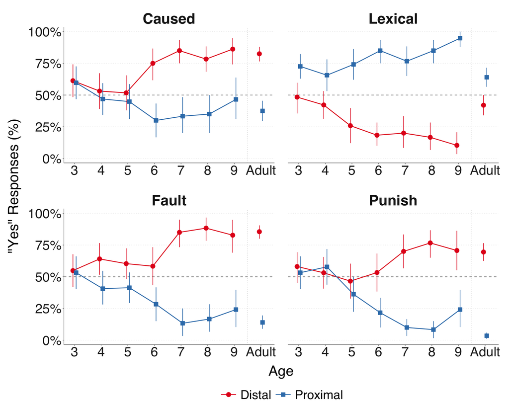

```r
p.study1.full = plot_study1(df.study1.summary)
save_talk(p.study1.full, file.path(study1_output, "study1_yes_responses_full"),
          study1_width, study1_height)
p.study1.full
```

## Talk builds

Build 00 contains only the complete scaffold. Each following pair adds adults then children for Caused, Lexical, Fault, and Punish. Build 08 uses the same summary rows and plotting function as the full figure. Every build is saved as both a vector PDF and a high-resolution PNG in `talk/builds/`.

```r
p.study1.builds = save_builds(df.study1.summary, plot_study1, study1_output,
                             study1_width, study1_height, study1_build_names)
kable(tibble(build = 0:8, filename = study1_build_names))
```

| build | filename |
| --- | --- |
| 0 | build00_orientation |
| 1 | build01_caused_adults |
| 2 | build02_caused_children |
| 3 | build03_lexical_adults |
| 4 | build04_lexical_children |
| 5 | build05_fault_adults |
| 6 | build06_fault_children |
| 7 | build07_punish_adults |
| 8 | build08_full |

# Study 2 — intention × causal chains

## Adults

### Data

All four files in `adult_pilot_rounds_unordered/` are earlier pilots. The preregistered main adult dataset remains missing. We audit each file separately and use **one** pilot for a talk/reference comparison. No participants are pooled across files and no scientific values are inferred from an image.

The current intentional and accidental adult `js/trial.js` files use the same 16 response names as Study 1. Their linked stories independently confirm Andy as the distal bike agent and Sophia as the distal mirror agent. See `../experiments/study2_intention_causal_chains/adults/slides/break_crack.pptx`: slides 4/11 and 30–32 describe Andy’s action and Suzy falling into the fence; slides 48/52 and 73–74 describe Sophia’s action and Bobby falling into the mirror. The current code is identified as v4 in the preserved source note, but a dataset-to-deployment revision mapping has not been recovered. Identical fields alone cannot establish which exact experiment version generated a pilot.

### Read

Each raw pilot has one row per adult. The loop reads the four explicitly named files and checks each file’s participant keys, fields, and condition labels. Its output is a named list of separate pilot tables, not a combined sample.

```r
df.study2.pilots.raw = setNames(lapply(study2_pilot_files, function(filename) {
  read_csv(file.path(study2_pilot_directory, filename),
            col_types = cols(.default = col_character()))
}), study2_pilot_files)

for (pilot in df.study2.pilots.raw) {
  stopifnot(setequal(names(pilot),
                    c("workerid", "proliferate.condition", "error", df.adult.questions$field)),
            !anyNA(pilot$workerid), !anyDuplicated(pilot$workerid), all(is.na(pilot$error)))
  check_labels(pilot$proliferate.condition, c("intentional", "accidental"), "adult condition")
}
```

### Wrangle and audit the four pilots

This explicit transformation repeats the adult field mapping for each pilot separately. `simple` is Lexical; each character keeps its verified role. `proliferate.condition` supplies the between-participant condition. We calculate role-specific yes-rates, the same outcome displayed in slide 17. Responses are averaged across scenarios within participant before averaging participants. Both/neither response patterns do not change the denominator.

```r
df.study2.pilots.responses = lapply(df.study2.pilots.raw, function(pilot) {
  pilot %>%
    select(workerid, proliferate.condition, all_of(df.adult.questions$field)) %>%
    pivot_longer(all_of(df.adult.questions$field), names_to = "field", values_to = "response_label") %>%
    left_join(df.adult.questions, by = "field", relationship = "many-to-one") %>%
    transmute(study = "Study 2", population = "Adults", participant = workerid,
              age = NA_integer_, condition = case_when(
                proliferate.condition == "intentional" ~ "Intentional",
                proliferate.condition == "accidental" ~ "Accidental"),
              scenario, measure, role, endorsed = yes_no(response_label))
})
invisible(lapply(df.study2.pilots.responses, check_response_rows))
df.study2.pilots.patterns = lapply(df.study2.pilots.responses, audit_patterns)
df.study2.pilots.means = lapply(df.study2.pilots.responses, participant_means)

df.study2.pilots.inventory = bind_rows(lapply(study2_pilot_files, function(filename) {
  pilot = df.study2.pilots.raw[[filename]]
  tibble(filename, N = nrow(pilot),
         Intentional = sum(pilot$proliferate.condition == "intentional"),
         Accidental = sum(pilot$proliferate.condition == "accidental"),
         available_fields = paste(names(pilot), collapse = ", "))
}))
df.study2.pilots.audit = bind_rows(lapply(study2_pilot_files, function(filename) {
  df.study2.pilots.means[[filename]] %>%
    group_by(condition, measure, role) %>%
    summarise(eligible_n = n(), contributing_n = sum(!is.na(yes_mean)),
              yes_mean = mean(yes_mean, na.rm = TRUE), .groups = "drop") %>%
    mutate(filename = filename, .before = 1)
}))
kable(df.study2.pilots.inventory, caption = "Separate earlier adult pilots; never pooled")
```

Separate earlier adult pilots; never pooled

| filename | N | Intentional | Accidental | available_fields |
| --- | --- | --- | --- | --- |
| adult_causation_and_punishment_new_updated_to_8_qs-responses.csv | 41 | 20 | 21 | workerid, proliferate.condition, bike_cause_andy, bike_cause_suzy, bike_fault_andy, bike_fault_suzy, bike_punish_andy, bike_punish_suzy, bike_simple_andy, bike_simple_suzy, mirror_cause_bobby, mirror_… |
| adult_causation_and_punishment_updated_to_8_qs_for-responses.csv | 42 | 21 | 21 | workerid, proliferate.condition, bike_cause_andy, bike_cause_suzy, bike_fault_andy, bike_fault_suzy, bike_punish_andy, bike_punish_suzy, bike_simple_andy, bike_simple_suzy, mirror_cause_bobby, mirror_… |
| causation_and_punishment_without_priming_test_verb-responses.csv | 40 | 20 | 20 | workerid, proliferate.condition, bike_cause_andy, bike_cause_suzy, bike_fault_andy, bike_fault_suzy, bike_punish_andy, bike_punish_suzy, bike_simple_andy, bike_simple_suzy, mirror_cause_bobby, mirror_… |
| exp2_new_pilot-responses.csv | 41 | 20 | 21 | workerid, proliferate.condition, bike_cause_andy, bike_cause_suzy, bike_fault_andy, bike_fault_suzy, bike_punish_andy, bike_punish_suzy, bike_simple_andy, bike_simple_suzy, mirror_cause_bobby, mirror_… |

```r
kable(df.study2.pilots.audit, digits = 4,
      caption = "Pilot comparison: role-specific Yes means after within-person scenario averaging")
```

Pilot comparison: role-specific Yes means after within-person scenario averaging

| filename | condition | measure | role | eligible_n | contributing_n | yes_mean |
| --- | --- | --- | --- | --- | --- | --- |
| adult_causation_and_punishment_new_updated_to_8_qs-responses.csv | Accidental | Caused | Distal | 21 | 21 | 0.8571 |
| adult_causation_and_punishment_new_updated_to_8_qs-responses.csv | Accidental | Caused | Proximal | 21 | 21 | 0.5000 |
| adult_causation_and_punishment_new_updated_to_8_qs-responses.csv | Accidental | Fault | Distal | 21 | 21 | 0.6905 |
| adult_causation_and_punishment_new_updated_to_8_qs-responses.csv | Accidental | Fault | Proximal | 21 | 21 | 0.2619 |
| adult_causation_and_punishment_new_updated_to_8_qs-responses.csv | Accidental | Lexical | Distal | 21 | 21 | 0.4048 |
| adult_causation_and_punishment_new_updated_to_8_qs-responses.csv | Accidental | Lexical | Proximal | 21 | 21 | 0.8095 |
| adult_causation_and_punishment_new_updated_to_8_qs-responses.csv | Accidental | Punish | Distal | 21 | 21 | 0.2381 |
| adult_causation_and_punishment_new_updated_to_8_qs-responses.csv | Accidental | Punish | Proximal | 21 | 21 | 0.0952 |
| adult_causation_and_punishment_new_updated_to_8_qs-responses.csv | Intentional | Caused | Distal | 20 | 20 | 0.9500 |
| adult_causation_and_punishment_new_updated_to_8_qs-responses.csv | Intentional | Caused | Proximal | 20 | 20 | 0.2750 |
| adult_causation_and_punishment_new_updated_to_8_qs-responses.csv | Intentional | Fault | Distal | 20 | 20 | 0.9750 |
| adult_causation_and_punishment_new_updated_to_8_qs-responses.csv | Intentional | Fault | Proximal | 20 | 20 | 0.0750 |
| adult_causation_and_punishment_new_updated_to_8_qs-responses.csv | Intentional | Lexical | Distal | 20 | 20 | 0.7500 |
| adult_causation_and_punishment_new_updated_to_8_qs-responses.csv | Intentional | Lexical | Proximal | 20 | 20 | 0.4750 |
| adult_causation_and_punishment_new_updated_to_8_qs-responses.csv | Intentional | Punish | Distal | 20 | 20 | 0.9500 |
| adult_causation_and_punishment_new_updated_to_8_qs-responses.csv | Intentional | Punish | Proximal | 20 | 20 | 0.0250 |
| adult_causation_and_punishment_updated_to_8_qs_for-responses.csv | Accidental | Caused | Distal | 21 | 21 | 0.9286 |
| adult_causation_and_punishment_updated_to_8_qs_for-responses.csv | Accidental | Caused | Proximal | 21 | 21 | 0.6190 |
| adult_causation_and_punishment_updated_to_8_qs_for-responses.csv | Accidental | Fault | Distal | 21 | 21 | 0.7857 |
| adult_causation_and_punishment_updated_to_8_qs_for-responses.csv | Accidental | Fault | Proximal | 21 | 21 | 0.2381 |
| adult_causation_and_punishment_updated_to_8_qs_for-responses.csv | Accidental | Lexical | Distal | 21 | 21 | 0.4048 |
| adult_causation_and_punishment_updated_to_8_qs_for-responses.csv | Accidental | Lexical | Proximal | 21 | 21 | 0.7381 |
| adult_causation_and_punishment_updated_to_8_qs_for-responses.csv | Accidental | Punish | Distal | 21 | 21 | 0.3333 |
| adult_causation_and_punishment_updated_to_8_qs_for-responses.csv | Accidental | Punish | Proximal | 21 | 21 | 0.1190 |
| adult_causation_and_punishment_updated_to_8_qs_for-responses.csv | Intentional | Caused | Distal | 21 | 21 | 0.9762 |
| adult_causation_and_punishment_updated_to_8_qs_for-responses.csv | Intentional | Caused | Proximal | 21 | 21 | 0.1429 |
| adult_causation_and_punishment_updated_to_8_qs_for-responses.csv | Intentional | Fault | Distal | 21 | 21 | 0.9762 |
| adult_causation_and_punishment_updated_to_8_qs_for-responses.csv | Intentional | Fault | Proximal | 21 | 21 | 0.0714 |
| adult_causation_and_punishment_updated_to_8_qs_for-responses.csv | Intentional | Lexical | Distal | 21 | 21 | 0.8333 |
| adult_causation_and_punishment_updated_to_8_qs_for-responses.csv | Intentional | Lexical | Proximal | 21 | 21 | 0.5238 |
| adult_causation_and_punishment_updated_to_8_qs_for-responses.csv | Intentional | Punish | Distal | 21 | 21 | 0.9762 |
| adult_causation_and_punishment_updated_to_8_qs_for-responses.csv | Intentional | Punish | Proximal | 21 | 21 | 0.0714 |
| causation_and_punishment_without_priming_test_verb-responses.csv | Accidental | Caused | Distal | 20 | 20 | 0.8250 |
| causation_and_punishment_without_priming_test_verb-responses.csv | Accidental | Caused | Proximal | 20 | 20 | 0.5000 |
| causation_and_punishment_without_priming_test_verb-responses.csv | Accidental | Fault | Distal | 20 | 20 | 0.6250 |
| causation_and_punishment_without_priming_test_verb-responses.csv | Accidental | Fault | Proximal | 20 | 20 | 0.1250 |
| causation_and_punishment_without_priming_test_verb-responses.csv | Accidental | Lexical | Distal | 20 | 20 | 0.4000 |
| causation_and_punishment_without_priming_test_verb-responses.csv | Accidental | Lexical | Proximal | 20 | 20 | 0.8250 |
| causation_and_punishment_without_priming_test_verb-responses.csv | Accidental | Punish | Distal | 20 | 20 | 0.2250 |
| causation_and_punishment_without_priming_test_verb-responses.csv | Accidental | Punish | Proximal | 20 | 20 | 0.0000 |
| causation_and_punishment_without_priming_test_verb-responses.csv | Intentional | Caused | Distal | 20 | 20 | 1.0000 |
| causation_and_punishment_without_priming_test_verb-responses.csv | Intentional | Caused | Proximal | 20 | 20 | 0.4250 |
| causation_and_punishment_without_priming_test_verb-responses.csv | Intentional | Fault | Distal | 20 | 20 | 0.9750 |
| causation_and_punishment_without_priming_test_verb-responses.csv | Intentional | Fault | Proximal | 20 | 20 | 0.0000 |
| causation_and_punishment_without_priming_test_verb-responses.csv | Intentional | Lexical | Distal | 20 | 20 | 0.6750 |
| causation_and_punishment_without_priming_test_verb-responses.csv | Intentional | Lexical | Proximal | 20 | 20 | 0.5500 |
| causation_and_punishment_without_priming_test_verb-responses.csv | Intentional | Punish | Distal | 20 | 20 | 0.9250 |
| causation_and_punishment_without_priming_test_verb-responses.csv | Intentional | Punish | Proximal | 20 | 20 | 0.0250 |
| exp2_new_pilot-responses.csv | Accidental | Caused | Distal | 21 | 21 | 0.7619 |
| exp2_new_pilot-responses.csv | Accidental | Caused | Proximal | 21 | 21 | 0.5952 |
| exp2_new_pilot-responses.csv | Accidental | Fault | Distal | 21 | 21 | 0.6429 |
| exp2_new_pilot-responses.csv | Accidental | Fault | Proximal | 21 | 21 | 0.2619 |
| exp2_new_pilot-responses.csv | Accidental | Lexical | Distal | 21 | 21 | 0.2619 |
| exp2_new_pilot-responses.csv | Accidental | Lexical | Proximal | 21 | 21 | 0.7143 |
| exp2_new_pilot-responses.csv | Accidental | Punish | Distal | 21 | 21 | 0.3095 |
| exp2_new_pilot-responses.csv | Accidental | Punish | Proximal | 21 | 21 | 0.0476 |
| exp2_new_pilot-responses.csv | Intentional | Caused | Distal | 20 | 20 | 0.9500 |
| exp2_new_pilot-responses.csv | Intentional | Caused | Proximal | 20 | 20 | 0.2500 |
| exp2_new_pilot-responses.csv | Intentional | Fault | Distal | 20 | 20 | 0.9750 |
| exp2_new_pilot-responses.csv | Intentional | Fault | Proximal | 20 | 20 | 0.0250 |
| exp2_new_pilot-responses.csv | Intentional | Lexical | Distal | 20 | 20 | 0.6250 |
| exp2_new_pilot-responses.csv | Intentional | Lexical | Proximal | 20 | 20 | 0.6000 |
| exp2_new_pilot-responses.csv | Intentional | Punish | Distal | 20 | 20 | 0.9250 |
| exp2_new_pilot-responses.csv | Intentional | Punish | Proximal | 20 | 20 | 0.0500 |

### Selected talk/reference pilot and limits of the match

We select **`exp2_new_pilot-responses.csv`** (N = 41: 20 Intentional and 21 Accidental). Its adult raw yes-rates visually align with all four panels of `../../figures/study2_intention_causal_chains/from_lab_talk_deck/slide17_img1.png` more closely than the other three pilots. For example, the selected pilot’s Intentional Caused distal/proximal rates are .95/.25, Lexical .625/.60, Fault .975/.025, and Punish .925/.05. The table below gives the exact values computed from the CSV for both conditions. These are evidence for the comparison choice, not recovered source-code or revision provenance.

The new figures plot these separate role-specific yes-rates. In particular, Accidental Punish includes **all 21 adults**: the distal mean is 13/42 = .309524 and the proximal mean is 2/42 = .047619 (two scenario responses per adult). Neither judgments are zeros for both roles, and are retained. These adult endpoints visually match the reference, although its generating script and exact deployment revision remain unverified. The presentation axes say only “Adult”; the input’s pilot provenance remains documented here and in the guide.

### Checks and sample sizes

```r
df.study2.adults.raw = df.study2.pilots.raw[[selected_pilot]]
df.study2.adults.responses = df.study2.pilots.responses[[selected_pilot]]
df.study2.adults.patterns = df.study2.pilots.patterns[[selected_pilot]]
df.study2.adults.means = df.study2.pilots.means[[selected_pilot]]
stopifnot(nrow(df.study2.adults.raw) == 41L,
          !anyNA(df.study2.adults.responses$condition))
kable(filter(df.study2.pilots.inventory, filename == selected_pilot) %>%
        select(-available_fields), caption = "Selected adult pilot (not the preregistered main sample)")
```

Selected adult pilot (not the preregistered main sample)

| filename | N | Intentional | Accidental |
| --- | --- | --- | --- |
| exp2_new_pilot-responses.csv | 41 | 20 | 21 |

```r
kable(filter(df.study2.pilots.audit, filename == selected_pilot) %>%
        select(condition, measure, role, yes_mean) %>%
        pivot_wider(names_from = role, values_from = yes_mean),
      digits = 6, caption = "CSV-derived raw yes-rates for visual comparison to slide 17")
```

CSV-derived raw yes-rates for visual comparison to slide 17

| condition | measure | Distal | Proximal |
| --- | --- | --- | --- |
| Accidental | Caused | 0.761905 | 0.595238 |
| Accidental | Fault | 0.642857 | 0.261905 |
| Accidental | Lexical | 0.261905 | 0.714286 |
| Accidental | Punish | 0.309524 | 0.047619 |
| Intentional | Caused | 0.950000 | 0.250000 |
| Intentional | Fault | 0.975000 | 0.025000 |
| Intentional | Lexical | 0.625000 | 0.600000 |
| Intentional | Punish | 0.925000 | 0.050000 |

## Children

### Data

`exp6_raw_responses.csv` is the supplied September 2026 snapshot. Collection is ongoing; this file does not establish completion of the registered sample. The CSV is byte-identical to the supplied download; only its `(2)` filename suffix was removed. Each row is a question response, with one empty-session placeholder. Child hash codes identify children; session IDs identify attempts.

### Read

```r
df.study2.children.raw = read_csv(
  "../../data/study2_intention_causal_chains/children/exp6_raw_responses.csv",
  col_types = cols(.default = col_character()))
df.study2.children.raw_counts = df.study2.children.raw %>%
  summarise(study = "Study 2", rows = n(), sessions = n_distinct(response_uuid),
            children = n_distinct(child_hashed_id))
stopifnot(identical(df.study2.children.raw_counts,
                   select(filter(snapshot_expectations, study == "Study 2"),
                          study, rows, sessions, children)))
stopifnot(all(df.study2.children.raw$completed == "False"),
          all(df.study2.children.raw$included_in_summary == "no"))
kable(df.study2.children.raw_counts)
```

| study | rows | sessions | children |
| --- | --- | --- | --- |
| Study 2 | 7523 | 422 | 416 |

### Wrangle: validate labels and count attempts

**Never filter Study 2 using `completed == TRUE`.** It is False even for usable sessions. Likewise, `included_in_summary` is no throughout and is ignored. Use the supplied inclusion flag, `true_completion_status`, actual and recorded test counts, withdrawal/exclusion information, age, eligibility, and preview status. All retained sessions must contain 16 answered test questions. One otherwise eligible session has all 16 test answers but no exported warmup rows; it is retained. Warmups are not test questions and their absence is not an additional exclusion rule. The export does not establish why they are absent.

The saved child task explicitly labels proximal/distal roles. Its question construction is in `../experiments/study2_intention_causal_chains/children/` `jspsych/chains_intentional_accidental_version.js`, lines 229–250. This mapping does not infer roles from response frequencies. The three missing group labels occur only in unusable early attempts, and the one fully blank question row is an incomplete-session placeholder; neither is turned into a scientific response.

```r
df.study2.children.questions = tribble(
  ~question_type, ~measure, ~role,
  "cause_proximal", "Caused", "Proximal",
  "cause_distal", "Caused", "Distal",
  "lexical_proximal", "Lexical", "Proximal",
  "lexical_distal", "Lexical", "Distal",
  "fault_proximal", "Fault", "Proximal",
  "fault_distal", "Fault", "Distal",
  "punish_proximal", "Punish", "Proximal",
  "punish_distal", "Punish", "Distal")
check_labels(df.study2.children.raw$question_type,
             c("warmup", df.study2.children.questions$question_type),
             "Study 2 question", allow_missing = TRUE)
check_labels(df.study2.children.raw$scenario_key, c("warmup", "bike", "mirror"),
             "Study 2 scenario", allow_missing = TRUE)
check_labels(df.study2.children.raw$response_label, c("yes", "no"),
             "Study 2 response", allow_missing = TRUE)
check_labels(df.study2.children.raw$group, c("intentional", "accidental"),
             "Study 2 condition", allow_missing = TRUE)
check_labels(df.study2.children.raw$include_in_analysis, c("yes", "no"), "inclusion flag")
check_labels(df.study2.children.raw$true_completion_status, c("complete", "incomplete"),
             "completion status")
check_labels(df.study2.children.raw$withdrawn, c("True", "False"), "withdrawal flag")
check_labels(df.study2.children.raw$eligibility,
             c('["Eligible"]', '["Ineligible_Participation"]'), "eligibility")
stopifnot(all(df.study2.children.raw$study == "exp6"),
          all(df.study2.children.raw$is_preview == "False"),
          all(df.study2.children.raw$participant_age_years %in% as.character(child_ages)),
          all(df.study2.children.raw$expected_test_questions_n == "16"),
          all(!is.na(df.study2.children.raw$group) |
                df.study2.children.raw$include_in_analysis == "no"),
          all(!is.na(df.study2.children.raw$question_type) |
                df.study2.children.raw$true_completion_status == "incomplete"))
df.study2.children.recorded = filter(df.study2.children.raw, !is.na(response_label))
stopifnot(all(df.study2.children.recorded$left_label == "yes"),
          all(df.study2.children.recorded$right_label == "no"),
          all(df.study2.children.recorded$response_index == if_else(
            df.study2.children.recorded$response_label == "yes", "0", "1")))

df.study2.children.attempts = df.study2.children.raw %>%
  distinct(child_hashed_id, response_uuid, response_id, date_created_utc, group,
           participant_age_years, include_in_analysis, true_completion_status,
           withdrawn, analysis_exclusion_reason, eligibility, is_preview,
           answered_test_questions_n, answered_all_test_questions) %>%
  rename(participant = child_hashed_id) %>%
  mutate(age = as.integer(participant_age_years), condition = case_when(
           group == "intentional" ~ "Intentional", group == "accidental" ~ "Accidental"),
         attempt_time = as.POSIXct(date_created_utc, format = "%Y-%m-%d %H:%M:%OS", tz = "UTC"))
df.study2.children.test_counts = df.study2.children.raw %>%
  group_by(response_uuid) %>%
  summarise(answered_tests = sum(scenario_key %in% c("bike", "mirror") &
                                  response_label %in% c("yes", "no")),
            warmups = sum(scenario_key %in% "warmup"), .groups = "drop")
df.study2.children.attempts = df.study2.children.attempts %>%
  left_join(df.study2.children.test_counts, by = "response_uuid", relationship = "one-to-one") %>%
  mutate(eligible = include_in_analysis == "yes" & true_completion_status == "complete" &
           answered_tests == 16L & answered_all_test_questions == "yes" &
           withdrawn == "False" & is.na(analysis_exclusion_reason) &
           eligibility == '["Eligible"]' & is_preview == "False")
stopifnot(!anyNA(df.study2.children.attempts$participant),
          !anyNA(df.study2.children.attempts$attempt_time),
          !anyDuplicated(df.study2.children.attempts$response_uuid),
          !anyDuplicated(df.study2.children.attempts$response_id),
          all(grepl("[+]00:00$", df.study2.children.attempts$date_created_utc)),
          all(df.study2.children.attempts$answered_tests ==
                as.integer(df.study2.children.attempts$answered_test_questions_n)),
          identical(df.study2.children.attempts$eligible,
                    df.study2.children.attempts$include_in_analysis == "yes"))
```

### Wrangle: select one eligible attempt per child

Twelve sessions fail the supplied analysis flag: six withdrawn, one ineligible, four with no answered tests, and one with 10 of 16 tests. The four repeated children with two eligible attempts each lose their earlier tied attempt. Two of these children crossed conditions; we retain the later eligible attempt only, without merging or treating the child as two people. The audit also shows repeated children whose other attempts were ineligible.

```r
df.study2.children.eligible = filter(df.study2.children.attempts, eligible)
stopifnot(!anyDuplicated(df.study2.children.eligible[
  c("participant", "answered_tests", "attempt_time")]))
df.study2.children.included = df.study2.children.eligible %>%
  arrange(participant, desc(answered_tests), desc(attempt_time)) %>%
  group_by(participant) %>% slice_head(n = 1) %>% ungroup()
df.study2.children.repeats = df.study2.children.attempts %>%
  add_count(participant, name = "attempts") %>% filter(attempts > 1L) %>%
  mutate(selected = response_uuid %in% df.study2.children.included$response_uuid) %>%
  arrange(participant, attempt_time) %>%
  select(participant, response_id, date_created_utc, condition, age, answered_tests,
         include_in_analysis, true_completion_status, withdrawn,
         analysis_exclusion_reason, selected)
kable(df.study2.children.repeats, caption = "All attempts by repeated Study 2 children")
```

All attempts by repeated Study 2 children

| participant | response_id | date_created_utc | condition | age | answered_tests | include_in_analysis | true_completion_status | withdrawn | analysis_exclusion_reason | selected |
| --- | --- | --- | --- | --- | --- | --- | --- | --- | --- | --- |
| BFTdAD | 481423 | 2026-09-04 04:33:22.818402+00:00 | Intentional | 6 | 16 | yes | complete | False | NA | FALSE |
| BFTdAD | 481725 | 2026-09-05 04:48:37.498574+00:00 | Accidental | 6 | 16 | yes | complete | False | NA | TRUE |
| DRWcAF | 483840 | 2026-09-12 16:36:37.316501+00:00 | Accidental | 4 | 0 | no | incomplete | False | incomplete_test_questions:0/16 | FALSE |
| DRWcAF | 483841 | 2026-09-12 16:41:55.340150+00:00 | Intentional | 4 | 16 | no | complete | True | withdrawn | FALSE |
| EQFd4U | 474691 | 2026-08-13 19:51:24.000736+00:00 | Intentional | 3 | 16 | yes | complete | False | NA | FALSE |
| EQFd4U | 479416 | 2026-08-28 20:43:34.674283+00:00 | Intentional | 3 | 16 | yes | complete | False | NA | TRUE |
| QGYMEG | 484574 | 2026-09-15 10:36:03.363464+00:00 | NA | 4 | 0 | no | incomplete | False | incomplete_test_questions:0/16 | FALSE |
| QGYMEG | 484575 | 2026-09-15 10:43:38.931771+00:00 | Intentional | 4 | 16 | yes | complete | False | NA | TRUE |
| TXLG3J | 466529 | 2026-07-25 11:48:42.410915+00:00 | Intentional | 7 | 16 | yes | complete | False | NA | FALSE |
| TXLG3J | 475268 | 2026-08-15 16:44:54.300013+00:00 | Accidental | 7 | 16 | yes | complete | False | NA | TRUE |
| VWPBSM | 469216 | 2026-07-31 02:58:52.857054+00:00 | Intentional | 9 | 16 | yes | complete | False | NA | FALSE |
| VWPBSM | 474013 | 2026-08-11 23:06:22.358286+00:00 | Intentional | 9 | 16 | yes | complete | False | NA | TRUE |

### Wrangle: make response rows and role-specific means

Keep experimental responses from each child’s one selected session. The exact question lookup supplies measure and role; `scenario_key` supplies Bike/Mirror and `group` supplies Intentional/Accidental. Any unmapped retained value stops the analysis. The common response schema feeds the same independent measure-by-role participant averages used in Study 1. Pair labels are only a descriptive audit, never an input to those means.

```r
df.study2.children.responses = df.study2.children.raw %>%
  semi_join(df.study2.children.included, by = "response_uuid") %>%
  filter(scenario_key %in% c("bike", "mirror")) %>%
  left_join(df.study2.children.questions, by = "question_type", relationship = "many-to-one") %>%
  transmute(study = "Study 2", population = "Children", participant = child_hashed_id,
            age = as.integer(participant_age_years), condition = case_when(
              group == "intentional" ~ "Intentional", group == "accidental" ~ "Accidental"),
            scenario = case_when(scenario_key == "bike" ~ "Bike", scenario_key == "mirror" ~ "Mirror"),
            measure, role, endorsed = yes_no(response_label))
stopifnot(!anyNA(select(df.study2.children.responses, -endorsed)),
          nrow(df.study2.children.responses) == 16L * nrow(df.study2.children.included))
df.study2.children.patterns = audit_patterns(df.study2.children.responses)
df.study2.children.means = participant_means(df.study2.children.responses)
```

### Checks and sample sizes

Ns below are unique retained children. No participant is omitted because they answered no to both agents. Some cells exceed the preregistered cap of 30; this is the requested uncapped descriptive snapshot. Session creation dates cannot substitute for the completion timestamps specified by that cap rule without an agreed change.

```r
stopifnot(nrow(df.study2.children.eligible) ==
            snapshot_expectations$flagged_eligible[snapshot_expectations$study == "Study 2"],
          nrow(df.study2.children.included) ==
            snapshot_expectations$retained_children[snapshot_expectations$study == "Study 2"],
          !anyDuplicated(df.study2.children.included$participant),
          !anyNA(df.study2.children.included$condition),
          all(df.study2.children.included$age %in% child_ages))
df.study2.children.age_counts = df.study2.children.included %>% count(age, name = "children")
df.study2.children.condition_age_counts = df.study2.children.included %>%
  count(age, condition, name = "children")
kable(df.study2.children.age_counts, caption = "Study 2 unique retained children by age")
```

Study 2 unique retained children by age

| age | children |
| --- | --- |
| 3 | 69 |
| 4 | 58 |
| 5 | 44 |
| 6 | 52 |
| 7 | 59 |
| 8 | 51 |
| 9 | 73 |

```r
kable(df.study2.children.condition_age_counts %>%
        pivot_wider(names_from = condition, values_from = children),
      caption = "Study 2 unique retained children by age and selected condition")
```

Study 2 unique retained children by age and selected condition

| age | Accidental | Intentional |
| --- | --- | --- |
| 3 | 32 | 37 |
| 4 | 35 | 23 |
| 5 | 25 | 19 |
| 6 | 24 | 28 |
| 7 | 30 | 29 |
| 8 | 23 | 28 |
| 9 | 31 | 42 |

## Combined descriptive data

The selected adult pilot and current child snapshot are kept distinct by population. No adult from the other pilots enters this summary. Bootstrap intervals resample participant means within the displayed group, exactly as in Study 1. Plots label the endpoint “Adult”; the pilot source is documented here.

```r
df.study2.patterns = bind_rows(df.study2.adults.patterns, df.study2.children.patterns)
df.study2.means = bind_rows(df.study2.adults.means, df.study2.children.means)
df.study2.summary = summarize_for_talk(df.study2.means, bootstrap_seed + 1L) %>%
  # Within each measure: Intentional adults/children, then Accidental adults/children.
  # Both causal roles appear together at each reveal.
  mutate(reveal_step = 4L * (match(as.character(measure), measure_order) - 1L) +
           2L * (match(condition, condition_order) - 1L) +
           if_else(population == "Adults", 1L, 2L))
kable(df.study2.summary %>%
        select(population, age_group, condition, measure, role, eligible_n, n, mean, lower, upper),
      digits = 3, caption = "Study 2: participant means and bootstrap 95% intervals; adults are pilot data")
```

Study 2: participant means and bootstrap 95% intervals; adults are pilot data

| population | age_group | condition | measure | role | eligible_n | n | mean | lower | upper |
| --- | --- | --- | --- | --- | --- | --- | --- | --- | --- |
| Adults | Adult | Accidental | Caused | Distal | 21 | 21 | 0.762 | 0.595 | 0.905 |
| Adults | Adult | Accidental | Caused | Proximal | 21 | 21 | 0.595 | 0.429 | 0.762 |
| Adults | Adult | Accidental | Lexical | Distal | 21 | 21 | 0.262 | 0.095 | 0.452 |
| Adults | Adult | Accidental | Lexical | Proximal | 21 | 21 | 0.714 | 0.524 | 0.881 |
| Adults | Adult | Accidental | Fault | Distal | 21 | 21 | 0.643 | 0.476 | 0.810 |
| Adults | Adult | Accidental | Fault | Proximal | 21 | 21 | 0.262 | 0.119 | 0.452 |
| Adults | Adult | Accidental | Punish | Distal | 21 | 21 | 0.310 | 0.143 | 0.476 |
| Adults | Adult | Accidental | Punish | Proximal | 21 | 21 | 0.048 | 0.000 | 0.143 |
| Adults | Adult | Intentional | Caused | Distal | 20 | 20 | 0.950 | 0.875 | 1.000 |
| Adults | Adult | Intentional | Caused | Proximal | 20 | 20 | 0.250 | 0.100 | 0.425 |
| Adults | Adult | Intentional | Lexical | Distal | 20 | 20 | 0.625 | 0.450 | 0.800 |
| Adults | Adult | Intentional | Lexical | Proximal | 20 | 20 | 0.600 | 0.400 | 0.775 |
| Adults | Adult | Intentional | Fault | Distal | 20 | 20 | 0.975 | 0.925 | 1.000 |
| Adults | Adult | Intentional | Fault | Proximal | 20 | 20 | 0.025 | 0.000 | 0.075 |
| Adults | Adult | Intentional | Punish | Distal | 20 | 20 | 0.925 | 0.800 | 1.000 |
| Adults | Adult | Intentional | Punish | Proximal | 20 | 20 | 0.050 | 0.000 | 0.125 |
| Children | 3 | Accidental | Caused | Distal | 32 | 32 | 0.453 | 0.328 | 0.594 |
| Children | 3 | Accidental | Caused | Proximal | 32 | 32 | 0.500 | 0.375 | 0.625 |
| Children | 3 | Accidental | Lexical | Distal | 32 | 32 | 0.359 | 0.234 | 0.484 |
| Children | 3 | Accidental | Lexical | Proximal | 32 | 32 | 0.703 | 0.578 | 0.812 |
| Children | 3 | Accidental | Fault | Distal | 32 | 32 | 0.562 | 0.438 | 0.688 |
| Children | 3 | Accidental | Fault | Proximal | 32 | 32 | 0.547 | 0.406 | 0.688 |
| Children | 3 | Accidental | Punish | Distal | 32 | 32 | 0.469 | 0.344 | 0.609 |
| Children | 3 | Accidental | Punish | Proximal | 32 | 32 | 0.469 | 0.344 | 0.594 |
| Children | 3 | Intentional | Caused | Distal | 37 | 37 | 0.514 | 0.392 | 0.635 |
| Children | 3 | Intentional | Caused | Proximal | 37 | 37 | 0.378 | 0.257 | 0.500 |
| Children | 3 | Intentional | Lexical | Distal | 37 | 37 | 0.500 | 0.378 | 0.622 |
| Children | 3 | Intentional | Lexical | Proximal | 37 | 37 | 0.500 | 0.365 | 0.622 |
| Children | 3 | Intentional | Fault | Distal | 37 | 37 | 0.608 | 0.500 | 0.716 |
| Children | 3 | Intentional | Fault | Proximal | 37 | 37 | 0.486 | 0.365 | 0.622 |

[output cut: 98 more lines]

## Talk plots

The reference image is 1920 × 1536 pixels. Both new figures keep its 5:4 aspect and 2 × 2 Caused/Lexical/Fault/Punish layout. Study 2 has four series per panel: Distal/Proximal crossed with Intentional/Accidental. Set1 red identifies Distal; Set1 blue identifies Proximal, matching Study 1. Intentional uses solid lines and filled circles; Accidental uses dashed lines and open triangles, with the same role colors. Legend keys explain role and intention separately.

Values are ordinary percentages of Yes responses, not conditional relative scores. Both/neither judgments remain in each role’s denominator. Child age means are connected without fitting curves, and adults remain separate endpoints labeled “Adult”. The y-axis runs from 0% to 100%, with a dashed horizontal line at 50% in every panel and build. Numerical tables retain proportions from 0 to 1.

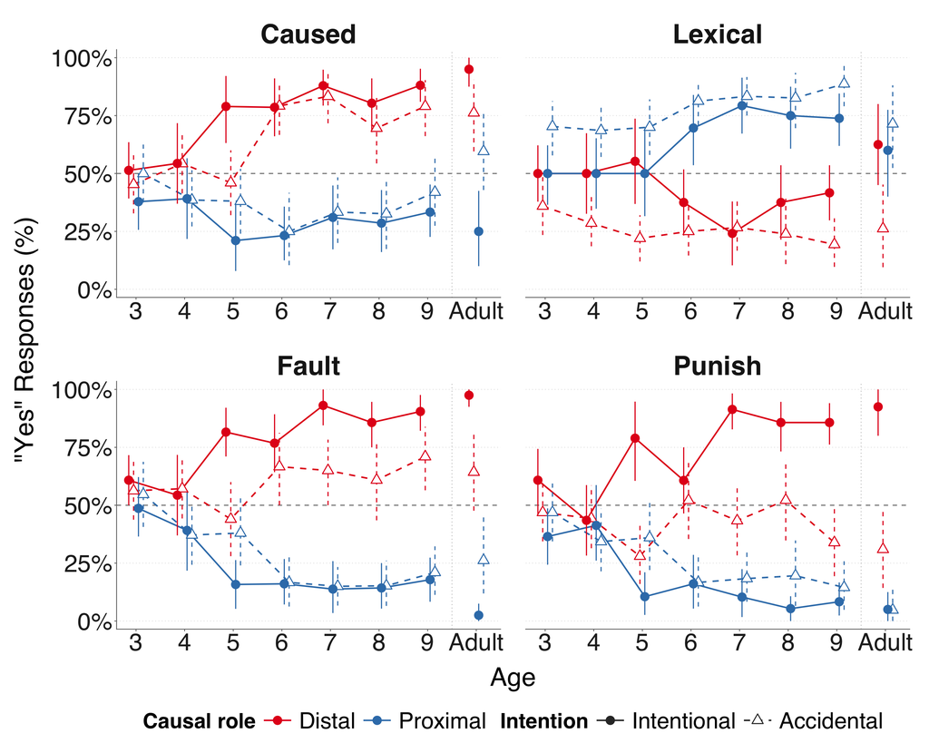

```r
p.study2.full = plot_study2(df.study2.summary)
save_talk(p.study2.full, file.path(study2_output, "study2_yes_responses_full"),
          study2_width, study2_height)
p.study2.full
```

## Talk builds

All four facets remain present from Build 00 onward. Within each measure, reveal Intentional adults, Intentional children, Accidental adults, then Accidental children; both roles appear together. Caused occupies 01–04, Lexical 05–08, Fault 09–12 and Punish 13–16. Build 16 equals the full figure. Earlier results stay fixed. Facets never drop, and no summary or bootstrap is recomputed during build rendering.

```r
p.study2.builds = save_builds(df.study2.summary, plot_study2, study2_output,
                             study2_width, study2_height, study2_build_names)
kable(tibble(build = 0:16, filename = study2_build_names))
```

| build | filename |
| --- | --- |
| 0 | build00_orientation |
| 1 | build01_caused_intentional_adults |
| 2 | build02_caused_intentional_children |
| 3 | build03_caused_accidental_adults |
| 4 | build04_caused_accidental_children |
| 5 | build05_lexical_intentional_adults |
| 6 | build06_lexical_intentional_children |
| 7 | build07_lexical_accidental_adults |
| 8 | build08_lexical_accidental_children |
| 9 | build09_fault_intentional_adults |
| 10 | build10_fault_intentional_children |
| 11 | build11_fault_accidental_adults |
| 12 | build12_fault_accidental_children |
| 13 | build13_punish_intentional_adults |
| 14 | build14_punish_intentional_children |
| 15 | build15_punish_accidental_adults |
| 16 | build16_full |

# Main talk comparison — change from the Study 1 baseline

Study 1 supplies the baseline judgments for the same causal-chain situations without an intentional/accidental manipulation. Match groups by **population, age category, measure and role**. Subtract that Study 1 mean from each Study 2 condition mean: `change = Study 2 proportion Yes - Study 1 proportion Yes`. The two conditions use exactly the same matching baseline. Never pair people across studies, pool age groups, or divide by the baseline.

The raw quantity is still each participant’s mean of available Bike/Mirror binary answers for that role and measure. Both/neither remain included, and missingness stays question-specific. Inclusion and repeat-attempt decisions are unchanged. The raw figures above remain backup outputs.

The percentage tick labels display changes in **percentage points**: 10% means ten points more Yes responses than baseline, 0 means the same mean, and -10 means ten points fewer. This is not percent change relative to the baseline denominator. Only Intentional and Accidental are drawn; the zero line represents Study 1.

This is a descriptive comparison of different study samples, not within-person change or an isolated causal estimate of adding intention information. Cohort or deployment differences can also contribute. In particular, Adult compares Study 1’s N=100 dataset with the selected Study 2 pilot (20 Intentional, 21 Accidental); the Study 2 preregistered adult dataset is still missing.

## Bootstrap both studies

For each age/measure/role cell, independently resample participants from Study 1, Study 2 Intentional and Study 2 Accidental, with replacement and the original sample size in each group. Each sampled value is already a participant mean. Reuse the same Study 1 bootstrap draw for both condition contrasts in each replicate. Subtract bootstrap means and take their 2.5th/97.5th percentiles. These are pointwise descriptive 95% intervals that include uncertainty in both studies; do not subtract the endpoints of the existing raw-mean intervals.

We treat the study samples as independent. Their retained participant codes do not overlap; the check below stops if this changes. Different anonymization schemes could still conceal shared people, and household dependence is not modeled. No confidence statement about an entire trajectory or a difference between the two change curves is made from these pointwise intervals.

```r
bootstrap_draws = function(values) {
  values = values[!is.na(values)]
  if (!length(values)) return(rep(NA_real_, bootstrap_replicates))
  replicate(bootstrap_replicates,
            mean(values[sample.int(length(values), replace = TRUE)]))
}

bootstrap_changes = function(baseline, intentional, accidental) {
  baseline_draws = bootstrap_draws(baseline)
  condition_values = list(Intentional = intentional, Accidental = accidental)
  bind_rows(lapply(condition_order, function(condition) {
    changes = bootstrap_draws(condition_values[[condition]]) - baseline_draws
    if (all(is.na(changes))) {
      return(tibble(condition, lower = NA_real_, upper = NA_real_))
    }
    tibble(condition, lower = unname(quantile(changes, .025)),
           upper = unname(quantile(changes, .975)))
  }))
}

df.comparison.id_overlap = tibble(population = c("Adults", "Children")) %>%
  rowwise() %>%
  mutate(shared_codes = length(intersect(
    df.study1.means$participant[df.study1.means$population == population],
    df.study2.means$participant[df.study2.means$population == population]))) %>%
  ungroup()
stopifnot(all(df.comparison.id_overlap$shared_codes == 0L))

# One row per matching cell, with separate lists of participant means.
df.comparison.samples = bind_rows(df.study1.means, df.study2.means) %>%
  mutate(age_group = if_else(population == "Adults", "Adult", as.character(age))) %>%
  arrange(study, population, age_group, measure, role, condition, participant) %>%
  group_by(population, age_group, measure, role) %>%
  summarise(baseline = list(yes_mean[study == "Study 1"]),
            intentional = list(yes_mean[study == "Study 2" & condition == "Intentional"]),
            accidental = list(yes_mean[study == "Study 2" & condition == "Accidental"]),
            .groups = "drop")

RNGkind("Mersenne-Twister", "Inversion", "Rejection")
set.seed(bootstrap_seed + 2L)
df.comparison.intervals = bind_rows(lapply(seq_len(nrow(df.comparison.samples)), function(i) {
  cell = df.comparison.samples[i, ]
  bind_cols(select(cell, population, age_group, measure, role),
            bootstrap_changes(cell$baseline[[1]], cell$intentional[[1]], cell$accidental[[1]]))
}))
```

## Compute and save every plotted value

The matching keys below prevent, for example, a distal adult comparison from using a proximal or child baseline. Means remain in proportion units in the CSV; columns ending in `_pp` multiply by 100 for the figure’s percentage-point units. The CSV contains all 128 plotted values, their two source means, both sample sizes, and bootstrap limits, written without display rounding. The compact table shows the same means to six decimal places.

```r
df.comparison.baseline = df.study1.summary %>%
  select(population, age_group, measure, role, baseline_n = n, baseline = mean)
df.comparison.summary = df.study2.summary %>%
  select(population, age_group, measure, role, condition, study2_n = n, study2_yes = mean) %>%
  left_join(df.comparison.baseline,
            by = c("population", "age_group", "measure", "role"), relationship = "many-to-one") %>%
  mutate(change = study2_yes - baseline) %>%
  left_join(df.comparison.intervals,
            by = c("population", "age_group", "measure", "role", "condition"),
            relationship = "one-to-one") %>%
  mutate(measure = factor(measure, levels = measure_order),
         role = factor(role, levels = role_order),
         condition = factor(condition, levels = condition_order),
         x = if_else(age_group == "Adult", comparison_adult_position,
                     as.numeric(match(age_group, age_labels) + min(child_ages) - 1)),
         reveal_step = match(as.character(measure), measure_order)) %>%
  arrange(role, measure, match(age_group, age_labels), condition)
stopifnot(nrow(df.comparison.summary) == 128L,
          !anyDuplicated(df.comparison.summary[c("population", "age_group", "measure", "role", "condition")]),
          all(is.finite(df.comparison.summary$change)),
          all(df.comparison.summary$baseline_n > 0), all(df.comparison.summary$study2_n > 0),
          all(df.comparison.summary$lower <= df.comparison.summary$upper))
# Use -50% to 50% unless an observed mean requires a wider symmetric range.
# Interval endpoints do not determine this requested display range.
comparison_y_limit = max(comparison_min_y_limit,
                         ceiling(max(abs(df.comparison.summary$change)) / comparison_y_step) * comparison_y_step)
comparison_y_breaks = seq(-comparison_y_limit, comparison_y_limit, comparison_y_step)

df.comparison.plotted_values = df.comparison.summary %>%
  select(population, age_group, measure, role, condition, baseline_n, study2_n,
         baseline, study2_yes, change, lower, upper) %>%
  mutate(change_pp = 100 * change, lower_pp = 100 * lower, upper_pp = 100 * upper)
write_csv(df.comparison.plotted_values,
          file.path(comparison_output, "baseline_change_plotted_means.csv"))

df.comparison.mean_table = df.comparison.summary %>%
  select(age_group, measure, role, baseline, condition, study2_yes, change) %>%
  pivot_wider(names_from = condition, values_from = c(study2_yes, change))
kable(df.comparison.mean_table, digits = 6,
      caption = "Study 2 minus Study 1: source means and changes in proportion units; CSV includes full precision, Ns and intervals")
```

Study 2 minus Study 1: source means and changes in proportion units; CSV includes full precision, Ns and intervals

| age_group | measure | role | baseline | study2_yes_Intentional | study2_yes_Accidental | change_Intentional | change_Accidental |
| --- | --- | --- | --- | --- | --- | --- | --- |
| 3 | Caused | Distal | 0.612903 | 0.513514 | 0.453125 | -0.099390 | -0.159778 |
| 4 | Caused | Distal | 0.531250 | 0.543478 | 0.542857 | 0.012228 | 0.011607 |
| 5 | Caused | Distal | 0.517241 | 0.789474 | 0.460000 | 0.272232 | -0.057241 |
| 6 | Caused | Distal | 0.750000 | 0.785714 | 0.791667 | 0.035714 | 0.041667 |
| 7 | Caused | Distal | 0.850000 | 0.879310 | 0.833333 | 0.029310 | -0.016667 |
| 8 | Caused | Distal | 0.783333 | 0.803571 | 0.695652 | 0.020238 | -0.087681 |
| 9 | Caused | Distal | 0.862069 | 0.880952 | 0.790323 | 0.018883 | -0.071746 |
| Adult | Caused | Distal | 0.825000 | 0.950000 | 0.761905 | 0.125000 | -0.063095 |
| 3 | Lexical | Distal | 0.483871 | 0.500000 | 0.359375 | 0.016129 | -0.124496 |
| 4 | Lexical | Distal | 0.421875 | 0.500000 | 0.285714 | 0.078125 | -0.136161 |
| 5 | Lexical | Distal | 0.258621 | 0.552632 | 0.220000 | 0.294011 | -0.038621 |
| 6 | Lexical | Distal | 0.183333 | 0.375000 | 0.250000 | 0.191667 | 0.066667 |
| 7 | Lexical | Distal | 0.200000 | 0.241379 | 0.266667 | 0.041379 | 0.066667 |
| 8 | Lexical | Distal | 0.166667 | 0.375000 | 0.239130 | 0.208333 | 0.072464 |
| 9 | Lexical | Distal | 0.103448 | 0.416667 | 0.193548 | 0.313218 | 0.090100 |
| Adult | Lexical | Distal | 0.420000 | 0.625000 | 0.261905 | 0.205000 | -0.158095 |
| 3 | Fault | Distal | 0.548387 | 0.608108 | 0.562500 | 0.059721 | 0.014113 |
| 4 | Fault | Distal | 0.640625 | 0.543478 | 0.571429 | -0.097147 | -0.069196 |
| 5 | Fault | Distal | 0.603448 | 0.815789 | 0.440000 | 0.212341 | -0.163448 |
| 6 | Fault | Distal | 0.583333 | 0.767857 | 0.666667 | 0.184524 | 0.083333 |
| 7 | Fault | Distal | 0.850000 | 0.931034 | 0.650000 | 0.081034 | -0.200000 |
| 8 | Fault | Distal | 0.883333 | 0.857143 | 0.608696 | -0.026190 | -0.274638 |
| 9 | Fault | Distal | 0.827586 | 0.904762 | 0.709677 | 0.077176 | -0.117909 |
| Adult | Fault | Distal | 0.855000 | 0.975000 | 0.642857 | 0.120000 | -0.212143 |
| 3 | Punish | Distal | 0.580645 | 0.608108 | 0.468750 | 0.027463 | -0.111895 |
| 4 | Punish | Distal | 0.531250 | 0.434783 | 0.442857 | -0.096467 | -0.088393 |
| 5 | Punish | Distal | 0.465517 | 0.789474 | 0.280000 | 0.323956 | -0.185517 |
| 6 | Punish | Distal | 0.533333 | 0.607143 | 0.520833 | 0.073810 | -0.012500 |
| 7 | Punish | Distal | 0.700000 | 0.913793 | 0.433333 | 0.213793 | -0.266667 |
| 8 | Punish | Distal | 0.766667 | 0.857143 | 0.521739 | 0.090476 | -0.244928 |
| 9 | Punish | Distal | 0.706897 | 0.857143 | 0.338710 | 0.150246 | -0.368187 |
| Adult | Punish | Distal | 0.695000 | 0.925000 | 0.309524 | 0.230000 | -0.385476 |
| 3 | Caused | Proximal | 0.596774 | 0.378378 | 0.500000 | -0.218396 | -0.096774 |
| 4 | Caused | Proximal | 0.468750 | 0.391304 | 0.385714 | -0.077446 | -0.083036 |
| 5 | Caused | Proximal | 0.448276 | 0.210526 | 0.380000 | -0.237750 | -0.068276 |
| 6 | Caused | Proximal | 0.300000 | 0.232143 | 0.250000 | -0.067857 | -0.050000 |
| 7 | Caused | Proximal | 0.333333 | 0.310345 | 0.333333 | -0.022989 | 0.000000 |
| 8 | Caused | Proximal | 0.350000 | 0.285714 | 0.326087 | -0.064286 | -0.023913 |
| 9 | Caused | Proximal | 0.465517 | 0.333333 | 0.419355 | -0.132184 | -0.046162 |
| Adult | Caused | Proximal | 0.375000 | 0.250000 | 0.595238 | -0.125000 | 0.220238 |
| 3 | Lexical | Proximal | 0.725806 | 0.500000 | 0.703125 | -0.225806 | -0.022681 |
| 4 | Lexical | Proximal | 0.656250 | 0.500000 | 0.685714 | -0.156250 | 0.029464 |
| 5 | Lexical | Proximal | 0.741379 | 0.500000 | 0.700000 | -0.241379 | -0.041379 |
| 6 | Lexical | Proximal | 0.850000 | 0.696429 | 0.812500 | -0.153571 | -0.037500 |
| 7 | Lexical | Proximal | 0.766667 | 0.793103 | 0.833333 | 0.026437 | 0.066667 |
| 8 | Lexical | Proximal | 0.850000 | 0.750000 | 0.826087 | -0.100000 | -0.023913 |
| 9 | Lexical | Proximal | 0.948276 | 0.738095 | 0.887097 | -0.210181 | -0.061179 |
| Adult | Lexical | Proximal | 0.640000 | 0.600000 | 0.714286 | -0.040000 | 0.074286 |
| 3 | Fault | Proximal | 0.532258 | 0.486486 | 0.546875 | -0.045772 | 0.014617 |
| 4 | Fault | Proximal | 0.406250 | 0.391304 | 0.371429 | -0.014946 | -0.034821 |
| 5 | Fault | Proximal | 0.413793 | 0.157895 | 0.380000 | -0.255898 | -0.033793 |
| 6 | Fault | Proximal | 0.283333 | 0.160714 | 0.166667 | -0.122619 | -0.116667 |
| 7 | Fault | Proximal | 0.133333 | 0.137931 | 0.150000 | 0.004598 | 0.016667 |
| 8 | Fault | Proximal | 0.166667 | 0.142857 | 0.152174 | -0.023810 | -0.014493 |
| 9 | Fault | Proximal | 0.241379 | 0.178571 | 0.209677 | -0.062808 | -0.031702 |
| Adult | Fault | Proximal | 0.140000 | 0.025000 | 0.261905 | -0.115000 | 0.121905 |
| 3 | Punish | Proximal | 0.532258 | 0.364865 | 0.468750 | -0.167393 | -0.063508 |
| 4 | Punish | Proximal | 0.578125 | 0.413043 | 0.342857 | -0.165082 | -0.235268 |
| 5 | Punish | Proximal | 0.362069 | 0.105263 | 0.360000 | -0.256806 | -0.002069 |
| 6 | Punish | Proximal | 0.216667 | 0.160714 | 0.166667 | -0.055952 | -0.050000 |
| 7 | Punish | Proximal | 0.100000 | 0.103448 | 0.183333 | 0.003448 | 0.083333 |
| 8 | Punish | Proximal | 0.083333 | 0.053571 | 0.195652 | -0.029762 | 0.112319 |
| 9 | Punish | Proximal | 0.241379 | 0.083333 | 0.145161 | -0.158046 | -0.096218 |
| Adult | Punish | Proximal | 0.035000 | 0.050000 | 0.047619 | 0.015000 | 0.012619 |

## Full comparison and cumulative builds

Columns are Caused, Lexical, Fault and Punish; rows are Distal and Proximal. Purple solid lines with filled circles show Intentional, and teal dashed lines with open triangles show Accidental. Child age means are connected; the Adult endpoint stays separate. All eight panels share a symmetric scale and a zero reference line. The role rows make a third baseline trajectory unnecessary. The current observed differences all fit within -50% to 50%. Four interval ends extend beyond this range and are simply clipped at the panel boundary, without arrowheads. The full interval bounds remain in the CSV. Coordinate zooming clips only the display; it never deletes the point or its entire interval.

Build 00 is the complete empty scaffold. Builds 01–04 add Caused, Lexical, Fault and Punish, respectively, for both roles and both conditions. Summaries, intervals, legend, offsets and geometry are fixed throughout; Build 04 equals the full figure. The comparison is the main talk figure; the two raw figures remain available for checking absolute endorsement levels.

```r
plot_comparison = function(summary, step = 4L) {
  stopifnot(step %in% 0:4)
  visible = show_build(summary, step) %>%
    mutate(plot_x = x + unname(comparison_offsets[as.character(condition)]))
  ggplot(visible, aes(x = plot_x, y = change, color = condition,
                      fill = condition, shape = condition, linetype = condition)) +
    geom_hline(yintercept = 0, color = "#666666", linewidth = .6) +
    geom_line(data = filter(visible, population == "Children"),
              aes(group = condition), linewidth = .8, show.legend = TRUE, na.rm = TRUE) +
    geom_linerange(aes(ymin = lower, ymax = upper), linetype = "solid",
                   linewidth = .45, alpha = .55, show.legend = FALSE, na.rm = TRUE) +
    geom_point(size = comparison_point_size, stroke = .75, show.legend = TRUE, na.rm = TRUE) +
    facet_grid(role ~ measure, drop = FALSE) +
    scale_color_manual(name = NULL, values = comparison_colors, limits = condition_order, drop = FALSE) +
    scale_fill_manual(name = NULL, values = c(Intentional = comparison_colors[["Intentional"]],
                                              Accidental = "white"),
                      limits = condition_order, drop = FALSE) +
    scale_shape_manual(name = NULL, values = condition_shapes, limits = condition_order, drop = FALSE) +
    scale_linetype_manual(name = NULL, values = condition_lines, limits = condition_order, drop = FALSE) +
    scale_x_continuous(breaks = c(child_ages, comparison_adult_position), labels = age_labels,
                       limits = c(2.6, comparison_adult_position + .9), expand = expansion(mult = 0)) +
    scale_y_continuous(breaks = comparison_y_breaks,
                       labels = paste0(100 * comparison_y_breaks, "%"),
                       expand = expansion(mult = 0)) +
    coord_cartesian(ylim = c(-comparison_y_limit, comparison_y_limit), expand = FALSE) +
    labs(x = "Age", y = "Change from baseline (%)") +
    talk_theme(comparison_text_size) +
    theme(panel.spacing = grid::unit(.6, "cm"),
          strip.text = element_text(size = comparison_text_size + 3, face = "bold"),
          strip.text.y = element_text(angle = 0),
          legend.title = element_blank(), legend.text = element_text(size = comparison_text_size))
}
p.comparison.full = plot_comparison(df.comparison.summary)
save_talk(p.comparison.full, file.path(comparison_output, "baseline_change_full"),
          comparison_width, comparison_height)
p.comparison.builds = save_builds(df.comparison.summary, plot_comparison, comparison_output,
                                  comparison_width, comparison_height, comparison_build_names)
kable(tibble(build = 0:4, filename = comparison_build_names))
```

| build | filename |
| --- | --- |
| 0 | build00_orientation |
| 1 | build01_caused |
| 2 | build02_lexical |
| 3 | build03_fault |
| 4 | build04_full |

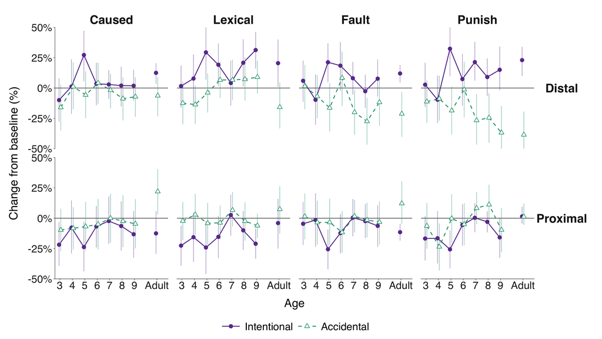

```r
p.comparison.full
```

# Study 2 distal-minus-proximal gaps — summary across child ages

This single-panel summary pools **Study 2 children aged 3–9**: 206 Intentional and 200 Accidental. The adult pilot remains in the raw and baseline-change figures and is excluded here. First average available Bike/Mirror Yes=1/No=0 responses within each child × measure × role. Then subtract that same child’s Proximal mean from their Distal mean and multiply by 100:

`gap_pp = 100 × (participant Distal Yes mean − participant Proximal Yes mean)`.

Zero means equal endorsement, positive values favor Distal, and negative values favor Proximal. Both/neither remain included. We never divide by total endorsement or by the Proximal mean. If either role has no available scenario responses, that child’s gap for that measure is missing; it is not replaced with zero. The current snapshot has both roles available for every child and measure. Source role means in the CSV use the same paired contributors.

Each child receives equal weight within condition, regardless of age. The conditions have different observed age compositions, so this remains an unadjusted pooled summary, not an age-standardized effect. Roles are paired within children; Intentional and Accidental are separate groups of children.

## Pair roles within child, then bootstrap participant gaps

Each bootstrap row contains all four gaps from one child. Independently resample child rows within each condition 5,000 times, keeping the role pairing and four judgments together. Percentile limits describe uncertainty in each condition’s mean Distal-minus-Proximal gap. Do not bootstrap the roles independently or subtract their marginal confidence-interval endpoints.

```r
df.gap.role_means = df.study2.means %>%
  filter(population == "Children", age %in% child_ages) %>%
  select(participant, age, condition, measure, role, yes_mean) %>%
  arrange(condition, participant, measure, role)
stopifnot(!anyDuplicated(df.gap.role_means[c("participant", "measure", "role")]))
df.gap.participants = df.gap.role_means %>%
  pivot_wider(names_from = role, values_from = yes_mean) %>%
  mutate(gap_pp = 100 * (Distal - Proximal))
df.gap.wide = df.gap.participants %>%
  select(participant, age, condition, measure, gap_pp) %>%
  pivot_wider(names_from = measure, values_from = gap_pp)
stopifnot(!anyDuplicated(df.gap.wide$participant),
          nrow(df.gap.wide) == nrow(df.study2.children.included),
          all(is.na(df.gap.participants$gap_pp) | abs(df.gap.participants$gap_pp) <= 100))
RNGkind("Mersenne-Twister", "Inversion", "Rejection")
set.seed(bootstrap_seed + 3L)
df.gap.intervals = bind_rows(lapply(condition_order, function(condition_name) {
  scores = df.gap.wide %>% filter(condition == condition_name) %>%
    select(all_of(measure_order)) %>% as.matrix()
  draws = replicate(bootstrap_replicates, {
    sampled = scores[sample.int(nrow(scores), replace = TRUE), , drop = FALSE]
    colMeans(sampled, na.rm = TRUE)
  })
  stopifnot(all(is.finite(draws)))
  tibble(condition = condition_name, measure = measure_order,
         lower_pp = apply(draws, 1, quantile, probs = .025),
         upper_pp = apply(draws, 1, quantile, probs = .975))
}))
```

## Exact values for all eight points

The CSV saves eligible and paired Ns, the paired contributors’ two source Yes proportions, the mean gap and its 95% limits. Columns ending in `_pp` are percentage points. Percentage tick labels denote these absolute differences, not relative percentage changes. No display rounding is applied to the CSV.

```r
df.gap.summary = df.gap.participants %>%
  group_by(measure, condition) %>%
  summarise(eligible_n = n(), n = sum(!is.na(gap_pp)),
            distal_yes = mean(Distal[!is.na(gap_pp)]),
            proximal_yes = mean(Proximal[!is.na(gap_pp)]),
            gap_pp = mean(gap_pp, na.rm = TRUE), .groups = "drop") %>%
  left_join(df.gap.intervals, by = c("measure", "condition"), relationship = "one-to-one") %>%
  mutate(population = "Children ages 3–9",
         measure = factor(measure, levels = measure_order),
         condition = factor(condition, levels = condition_order)) %>%
  select(population, measure, condition, eligible_n, n, distal_yes, proximal_yes,
         gap_pp, lower_pp, upper_pp) %>% arrange(measure, condition)
stopifnot(nrow(df.gap.summary) == 8L, all(df.gap.summary$n == df.gap.summary$eligible_n),
          all(is.finite(df.gap.summary$gap_pp)),
          all(df.gap.summary$lower_pp <= df.gap.summary$upper_pp),
          all(abs(df.gap.summary$gap_pp -
                    100 * (df.gap.summary$distal_yes - df.gap.summary$proximal_yes)) < 1e-12))
write_csv(df.gap.summary, file.path(comparison_output, "study2_distal_proximal_gap_summary_values.csv"))
kable(select(df.gap.summary, -population), digits = 6,
      caption = "Paired Distal-minus-Proximal gaps within each condition: source proportions and percentage-point estimates/95% intervals")
```

Paired Distal-minus-Proximal gaps within each condition: source proportions and percentage-point estimates/95% intervals

| measure | condition | eligible_n | n | distal_yes | proximal_yes | gap_pp | lower_pp | upper_pp |
| --- | --- | --- | --- | --- | --- | --- | --- | --- |
| Caused | Intentional | 206 | 206 | 0.745146 | 0.313107 | 43.20388 | 34.46602 | 51.69903 |
| Caused | Accidental | 200 | 200 | 0.647500 | 0.377500 | 27.00000 | 18.50000 | 35.50000 |
| Lexical | Intentional | 206 | 206 | 0.417476 | 0.650485 | -23.30097 | -32.76699 | -13.58616 |
| Lexical | Accidental | 200 | 200 | 0.262500 | 0.775000 | -51.25000 | -58.25000 | -43.99375 |
| Fault | Intentional | 206 | 206 | 0.781553 | 0.242718 | 53.88350 | 46.35922 | 61.16505 |
| Fault | Accidental | 200 | 200 | 0.602500 | 0.292500 | 31.00000 | 23.25000 | 39.25000 |
| Punish | Intentional | 206 | 206 | 0.733010 | 0.182039 | 55.09709 | 47.08738 | 62.86408 |
| Punish | Accidental | 200 | 200 | 0.427500 | 0.272500 | 15.50000 | 8.00000 | 23.00000 |

## Single-panel paired-point plot

Purple filled circles show Intentional and teal open triangles show Accidental. A thin neutral connector joins the two condition-specific gaps within each measure; no line joins different measures. The zero reference marks equal Distal and Proximal endorsement. Both means and all interval ends fit inside the displayed range, rounded outward to 25-point steps.

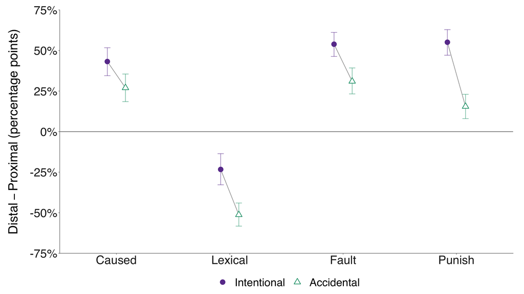

```r
df.gap.plot = df.gap.summary %>%
  mutate(plot_x = as.numeric(measure) + unname(intention_offsets[as.character(condition)]))
df.gap.pairs = df.gap.plot %>% select(measure, condition, gap_pp, plot_x) %>%
  pivot_wider(names_from = condition, values_from = c(gap_pp, plot_x)) %>%
  mutate(intentional_minus_accidental_pp = gap_pp_Intentional - gap_pp_Accidental)
gap_y_lower = floor(min(0, df.gap.summary$lower_pp) / gap_y_step) * gap_y_step
gap_y_upper = ceiling(max(0, df.gap.summary$upper_pp) / gap_y_step) * gap_y_step
p.gap.summary = ggplot(df.gap.plot,
  aes(x = plot_x, y = gap_pp, color = condition, fill = condition, shape = condition)) +
  geom_hline(yintercept = 0, color = "#777777", linewidth = .6) +
  geom_segment(data = df.gap.pairs,
                aes(x = plot_x_Intentional, xend = plot_x_Accidental,
                    y = gap_pp_Intentional, yend = gap_pp_Accidental),
                inherit.aes = FALSE, color = "#A0A0A0", linewidth = .6) +
  geom_errorbar(aes(ymin = lower_pp, ymax = upper_pp), width = .055,
                linewidth = .55, alpha = .65, show.legend = FALSE) +
  geom_point(size = 4.3, stroke = 1, show.legend = TRUE) +
  scale_color_manual(name = NULL, values = comparison_colors, limits = condition_order, drop = FALSE) +
  scale_fill_manual(name = NULL, values = c(Intentional = comparison_colors[["Intentional"]], Accidental = "white"),
                    limits = condition_order, drop = FALSE) +
  scale_shape_manual(name = NULL, values = condition_shapes, limits = condition_order, drop = FALSE) +
  scale_x_continuous(breaks = seq_along(measure_order), labels = measure_order,
                     limits = c(.5, length(measure_order) + .5), expand = expansion(mult = 0)) +
  scale_y_continuous(breaks = seq(gap_y_lower, gap_y_upper, gap_y_step),
                     labels = function(x) paste0(x, "%"), limits = c(gap_y_lower, gap_y_upper),
                     expand = expansion(mult = 0)) +
  labs(x = NULL, y = expression(plain("Distal") - plain("Proximal") ~ plain("(percentage points)"))) +
  talk_theme(intention_text_size)
save_talk(p.gap.summary, file.path(comparison_output, "study2_distal_proximal_gap_summary"),
          intention_width, intention_height)
p.gap.summary
```

## What the summary supports

Intentional has a larger (more positive) Distal-minus-Proximal gap than Accidental for every measure. The between-condition separation is greatest for Punish (39.60 percentage points), followed by Lexical (27.95), Fault (22.88) and Caused (16.20). Fault has a large positive Intentional gap, but the intentionality-related widening is not especially large for Fault relative to Lexical. Lexical gaps are negative in both conditions: children endorse Proximal more often there, although less strongly under Intentional. These are descriptive comparisons; the pointwise intervals do not formally test whether the between-condition separation differs across measures.

# Single Cause — one direct causal agent

The Single Cause comparison uses the same Intentional/Accidental manipulation and four judgments as Study 2, but one agent directly brings about the outcome. There is no distal/proximal choice or relative-attribution score. This section adds the supplied `exp7` child snapshot to the shared workflow. Historical figures, experiment files and adult data are left unchanged.

## Children: read and audit the export

The supplied raw CSV is copied without changing values. `child_hashed_id` is the participant unit; `response_uuid` identifies a session. Hash codes, session IDs and session dates remain restricted research metadata in the private repo. The export has two warmup answers plus eight test answers per session. `completed` is False throughout and is not an inclusion filter. `included_in_summary` is a row-level export flag and is never used for inclusion. The exported `expected_test_questions_n` and `answered_test_questions_n` both say 2, although actual Bike/Mirror rows show eight answers per session. Their meaning is unverified; we audit that discrepancy and count actual response rows rather than using these two fields as test-question totals.

```r
df.single.raw = read_csv("../../data/single_cause/children/exp7_raw_responses.csv",
                          col_types = cols(.default = col_character()))
df.single.raw_counts = df.single.raw %>%
  summarise(rows = n(), sessions = n_distinct(response_uuid),
            children = n_distinct(child_hashed_id))
if (!identical(as.integer(unlist(df.single.raw_counts[1, ], use.names = FALSE)), c(970L, 97L, 97L))) {
  stop("Single Cause export counts differ from the supplied snapshot; stop for review.")
}
check_labels(df.single.raw$study, "exp7", "Single Cause study")
check_labels(df.single.raw$group, tolower(condition_order), "Single Cause condition")
check_labels(df.single.raw$participant_age_years, as.character(single_child_ages), "Single Cause age")
check_labels(df.single.raw$scenario_key, c("warmup", "bike", "mirror"), "Single Cause scenario")
check_labels(df.single.raw$question_type, c("warmup", "cause", "lexical", "fault", "punish"), "Single Cause question")
check_labels(df.single.raw$response_label, c("yes", "no"), "Single Cause response", allow_missing = TRUE)
check_labels(df.single.raw$include_in_analysis, c("yes", "no"), "Single Cause inclusion flag")
check_labels(df.single.raw$withdrawn, c("True", "False"), "Single Cause withdrawal")
check_labels(df.single.raw$true_completion_status, "complete", "Single Cause completion")
stopifnot(all(df.single.raw$completed == "False"),
          all(df.single.raw$eligibility == '["Eligible"]'),
          all(df.single.raw$is_preview == "False"),
          all(df.single.raw$expected_test_questions_n == "2"),
          all(df.single.raw$left_label == "yes"), all(df.single.raw$right_label == "no"),
          all(df.single.raw$response_index == if_else(df.single.raw$response_label == "yes", "0", "1")),
          all((df.single.raw$scenario_key == "warmup") == (df.single.raw$question_type == "warmup")))
kable(df.single.raw_counts, caption = "Single Cause raw export: rows, sessions and unique children")
```

Single Cause raw export: rows, sessions and unique children

| rows | sessions | children |
| --- | --- | --- |
| 970 | 97 | 97 |

```r
# Distinct metadata must reduce to exactly one row per session.
df.single.sessions = df.single.raw %>%
  distinct(response_uuid, response_id, child_hashed_id, participant_age_years, group,
           include_in_analysis, true_completion_status, withdrawn, analysis_exclusion_reason,
           eligibility, is_preview, answered_test_questions_n, answered_all_test_questions) %>%
  rename(participant = child_hashed_id) %>%
  mutate(age = as.integer(participant_age_years),
         condition = if_else(group == "intentional", "Intentional", "Accidental"))
stopifnot(!anyDuplicated(df.single.sessions$response_uuid),
          !anyDuplicated(df.single.sessions$response_id), !anyNA(df.single.sessions$participant))
df.single.trial_counts = df.single.raw %>%
  group_by(response_uuid) %>%
  summarise(warmups = sum(scenario_key == "warmup"),
            test_rows = sum(scenario_key %in% c("bike", "mirror")),
            answered_tests = sum(scenario_key %in% c("bike", "mirror") & response_label %in% c("yes", "no")),
            .groups = "drop")
df.single.sessions = df.single.sessions %>%
  left_join(df.single.trial_counts, by = "response_uuid", relationship = "one-to-one") %>%
  mutate(included = include_in_analysis == "yes" & withdrawn == "False" &
           is.na(analysis_exclusion_reason) & true_completion_status == "complete" &
           eligibility == '["Eligible"]' & is_preview == "False")
stopifnot(all(df.single.sessions$warmups == 2L), all(df.single.sessions$test_rows == 8L),
          all(df.single.sessions$answered_tests == 8L),
          all(df.single.sessions$answered_test_questions_n == "2"),
          all(df.single.sessions$answered_all_test_questions == "yes"),
          identical(df.single.sessions$included, df.single.sessions$include_in_analysis == "yes"),
          sum(df.single.sessions$included) == 96L,
          sum(df.single.sessions$withdrawn == "True") == 1L,
          all(df.single.sessions$analysis_exclusion_reason[!df.single.sessions$included] == "withdrawn"))

# Do not silently select a new repeat-attempt rule if this export changes.
df.single.repeats = df.single.sessions %>% count(participant, name = "sessions") %>% filter(sessions > 1L)
kable(tibble(repeated_child_ids = nrow(df.single.repeats)), caption = "Repeat-child audit (all sessions, including excluded)")
```

Repeat-child audit (all sessions, including excluded)

| repeated_child_ids |
| --- |
| 0 |

```r
if (nrow(df.single.repeats) > 0L) stop("Single Cause repeat children found; stop for review.")
df.single.included = filter(df.single.sessions, included)
df.single.flow = tibble(
  stage = c("Raw sessions / unique children", "Withdrawn and flagged for exclusion", "Included sessions / unique children"),
  n = c(nrow(df.single.sessions), sum(!df.single.sessions$included), nrow(df.single.included)))
kable(df.single.flow, caption = "Single Cause inclusion flow")
```

Single Cause inclusion flow

| stage | n |
| --- | --- |
| Raw sessions / unique children | 97 |
| Withdrawn and flagged for exclusion | 1 |
| Included sessions / unique children | 96 |

```r
df.single.ns = df.single.included %>% count(age, condition, name = "n") %>% arrange(age, condition)
if (nrow(anti_join(df.single.ns, single_expected_ns, by = c("age", "condition", "n"))) > 0L ||
    nrow(anti_join(single_expected_ns, df.single.ns, by = c("age", "condition", "n"))) > 0L) {
  stop("Single Cause age-by-condition Ns differ from the supplied snapshot; stop for review.")
}
kable(df.single.ns, caption = "Included children by age and condition")
```

Included children by age and condition

| age | condition | n |
| --- | --- | --- |
| 3 | Accidental | 12 |
| 3 | Intentional | 14 |
| 4 | Accidental | 14 |
| 4 | Intentional | 10 |
| 5 | Accidental | 10 |
| 5 | Intentional | 13 |
| 6 | Accidental | 10 |
| 6 | Intentional | 13 |

```r
kable(df.single.raw %>% count(completed, true_completion_status, included_in_summary,
                             expected_test_questions_n, answered_test_questions_n),
      caption = "Export flag audit only: completed and included_in_summary do not select participants")
```

Export flag audit only: completed and included_in_summary do not select participants

| completed | true_completion_status | included_in_summary | expected_test_questions_n | answered_test_questions_n | n |
| --- | --- | --- | --- | --- | --- |
| False | complete | no | 2 | 2 | 778 |
| False | complete | yes | 2 | 2 | 192 |

## Recode and average within child

Only Bike/Mirror test rows from included sessions enter scores. The 194 raw warmup rows are excluded, including 192 from included sessions. The withdrawn session’s eight test answers are also excluded. This leaves 768 scientific response rows. Each child contributes four scenario-averaged scores. Missing answers would remain missing for that question and never become No; the current snapshot has both scenarios available for all 384 child-by-measure means.

```r
df.single.questions = tibble(question_type = c("cause", "lexical", "fault", "punish"),
                              measure = measure_order)
df.single.responses = df.single.raw %>%
  filter(scenario_key %in% c("bike", "mirror")) %>%
  inner_join(select(df.single.included, response_uuid, participant, age, condition),
             by = "response_uuid", relationship = "many-to-one") %>%
  left_join(df.single.questions, by = "question_type", relationship = "many-to-one") %>%
  transmute(participant, age, condition, scenario = scenario_key, measure,
            endorsed = yes_no(response_label))
stopifnot(nrow(df.single.responses) == 768L, !anyNA(df.single.responses$measure),
          !anyDuplicated(df.single.responses[c("participant", "scenario", "measure")]))
df.single.means = df.single.responses %>%
  group_by(participant, age, condition, measure) %>%
  summarise(scenarios_available = sum(!is.na(endorsed)),
            yes_mean = if (all(is.na(endorsed))) NA_real_ else mean(endorsed, na.rm = TRUE),
            .groups = "drop")
stopifnot(nrow(df.single.means) == 384L, all(df.single.means$scenarios_available == 2L))
kable(tibble(raw_warmup_rows_excluded = sum(df.single.raw$scenario_key == "warmup"),
             included_test_rows = nrow(df.single.responses), participant_measure_means = nrow(df.single.means)))
```

| raw_warmup_rows_excluded | included_test_rows | participant_measure_means |
| --- | --- | --- |
| 194 | 768 | 384 |

## Adults: use all 32 recovered complete records

The adult CSV has 32 unique participant codes, 16 per condition. All eight answers are present for every row, and every `error` field is blank. No row is identified as excluded or incomplete. The source note calls two rows “likely excluded/incomplete” but provides no IDs or rule. Slide 20 reports 30 adults, 15 per condition. Its embedded plot supplies no participant-level exclusion information. The saved experiment and conversion code define the eight questions but do not recover the historical exclusion decision.

We cannot defensibly identify the historical 30-person subset. **By explicit review decision, the current working plots use all 32 complete adults, 16 per condition.** We do not fabricate an exclusion rule or reverse-select rows to match the old slide. This is a documented working sample, not a recovered historical N=30 analysis. All source rows and historical images remain unchanged. Adults appear as a separate endpoint; they are not pooled into the child summaries. See the adult audit for inspected sources.

```r
df.single.adults.raw = read_csv("../../data/single_cause/adults/single_cause_pilot1-responses.csv",
                               col_types = cols(.default = col_character()))
single_adult_fields = c("bike_cause_andy", "bike_simple_andy", "bike_fault_andy", "bike_punish_andy",
                        "mirror_cause_sophia", "mirror_simple_sophia", "mirror_fault_sophia", "mirror_punish_sophia")
df.single.adults.audit = df.single.adults.raw %>%
  mutate(answered_tests = rowSums(as.data.frame(lapply(select(., all_of(single_adult_fields)),
                                                      function(x) x %in% c("yes", "no"))))) %>%
  group_by(condition = proliferate.condition) %>%
  summarise(rows = n(), unique_ids = n_distinct(workerid),
            complete_eight_answers = sum(answered_tests == 8L),
            nonblank_errors = sum(!is.na(error)), .groups = "drop")
stopifnot(nrow(df.single.adults.raw) == 32L, !anyDuplicated(df.single.adults.raw$workerid),
          all(df.single.adults.audit$rows == 16L), all(df.single.adults.audit$complete_eight_answers == 16L),
          all(df.single.adults.audit$nonblank_errors == 0L))
kable(df.single.adults.audit, caption = "Working adult sample: all 32 complete records, 16 per condition")
```

Working adult sample: all 32 complete records, 16 per condition

| condition | rows | unique_ids | complete_eight_answers | nonblank_errors |
| --- | --- | --- | --- | --- |
| accidental | 16 | 16 | 16 | 0 |
| intentional | 16 | 16 | 16 | 0 |

```r
check_labels(df.single.adults.raw$proliferate.condition, tolower(condition_order), "Single Cause adult condition")
df.single.adults.responses = df.single.adults.raw %>%
  select(participant = workerid, condition = proliferate.condition, all_of(single_adult_fields)) %>%
  pivot_longer(all_of(single_adult_fields), names_to = c("scenario", "question", "agent"),
               names_sep = "_", values_to = "response") %>%
  mutate(condition = if_else(condition == "intentional", "Intentional", "Accidental"),
         measure = recode(question, cause = "Caused", simple = "Lexical", fault = "Fault", punish = "Punish"),
         endorsed = yes_no(response))
df.single.adults.means = df.single.adults.responses %>%
  group_by(participant, condition, measure) %>%
  summarise(scenarios_available = sum(!is.na(endorsed)),
            yes_mean = mean(endorsed), .groups = "drop")
stopifnot(nrow(df.single.adults.means) == 128L,
          all(df.single.adults.means$scenarios_available == 2L),
          !anyNA(df.single.adults.means$yes_mean))
```

## Age-group summaries and developmental figure

Bootstrap the participant means within age × condition × measure with the shared 5,000-replicate helper and a fixed seed. Every child receives equal weight within their age/condition group. The figure uses four panels, 0–100% Yes responses and ages 3–6 plus an Adult endpoint (16 participants per condition). There are no empty ages 7–9. A dashed 50% reference matches Study 2; it is a visual midpoint, not a chance-model assumption. Adults and children are bootstrapped separately; the existing child estimates and intervals are unchanged. Intentional uses the existing named purple color, a solid line and filled circle; Accidental uses the existing teal color, a dashed line and open triangle. The shared 16 × 12.8-inch dimensions and typography match the raw chain figures.

```r
RNGkind("Mersenne-Twister", "Inversion", "Rejection")
set.seed(bootstrap_seed + 4L)
df.single.children.summary = df.single.means %>%
  mutate(measure = factor(measure, levels = measure_order),
         condition = factor(condition, levels = condition_order)) %>%
  arrange(measure, condition, age, participant) %>%
  group_by(age, condition, measure) %>%
  summarise(summary = list(bootstrap_mean(yes_mean)), .groups = "drop") %>% unnest_wider(summary) %>%
  mutate(population = "Children", age_group = as.character(age), x = as.numeric(age))
set.seed(bootstrap_seed + 7L)
df.single.adults.summary = df.single.adults.means %>%
  mutate(measure = factor(measure, levels = measure_order),
         condition = factor(condition, levels = condition_order)) %>%
  arrange(measure, condition, participant) %>% group_by(condition, measure) %>%
  summarise(summary = list(bootstrap_mean(yes_mean)), .groups = "drop") %>% unnest_wider(summary) %>%
  mutate(population = "Adults", age = NA_integer_, age_group = "Adult", x = single_adult_position)
df.single.summary = bind_rows(df.single.children.summary, df.single.adults.summary) %>%
  mutate(reveal_step = (as.integer(measure) - 1L) * 4L +
           (as.integer(condition) - 1L) * 2L + if_else(population == "Adults", 1L, 2L))
stopifnot(nrow(df.single.summary) == 40L, all(df.single.adults.summary$n == 16L))
write_csv(select(df.single.summary, population, age_group, age, condition, measure, n, mean, lower, upper),
          file.path(single_output, "single_cause_developmental_values.csv"))
kable(select(df.single.summary, population, age_group, condition, measure, n, mean, lower, upper), digits = 6,
      caption = "Every plotted child/adult mean and N (proportion units); CSV preserves full precision")
```

Every plotted child/adult mean and N (proportion units); CSV preserves full precision

| population | age_group | condition | measure | n | mean | lower | upper |
| --- | --- | --- | --- | --- | --- | --- | --- |
| Children | 3 | Intentional | Caused | 14 | 0.535714 | 0.357143 | 0.714286 |
| Children | 3 | Intentional | Lexical | 14 | 0.785714 | 0.607143 | 0.928571 |
| Children | 3 | Intentional | Fault | 14 | 0.785714 | 0.642857 | 0.892857 |
| Children | 3 | Intentional | Punish | 14 | 0.571429 | 0.392857 | 0.750000 |
| Children | 3 | Accidental | Caused | 12 | 0.541667 | 0.291667 | 0.791667 |
| Children | 3 | Accidental | Lexical | 12 | 0.916667 | 0.791667 | 1.000000 |
| Children | 3 | Accidental | Fault | 12 | 0.583333 | 0.375000 | 0.791667 |
| Children | 3 | Accidental | Punish | 12 | 0.541667 | 0.333333 | 0.750000 |
| Children | 4 | Intentional | Caused | 10 | 0.750000 | 0.550000 | 0.950000 |
| Children | 4 | Intentional | Lexical | 10 | 0.850000 | 0.700000 | 1.000000 |
| Children | 4 | Intentional | Fault | 10 | 0.650000 | 0.350000 | 0.900000 |
| Children | 4 | Intentional | Punish | 10 | 0.650000 | 0.350000 | 0.900000 |
| Children | 4 | Accidental | Caused | 14 | 0.428571 | 0.214286 | 0.642857 |
| Children | 4 | Accidental | Lexical | 14 | 0.928571 | 0.821429 | 1.000000 |
| Children | 4 | Accidental | Fault | 14 | 0.785714 | 0.571429 | 0.964286 |
| Children | 4 | Accidental | Punish | 14 | 0.607143 | 0.357143 | 0.821429 |
| Children | 5 | Intentional | Caused | 13 | 0.923077 | 0.807692 | 1.000000 |
| Children | 5 | Intentional | Lexical | 13 | 0.807692 | 0.615385 | 0.961538 |
| Children | 5 | Intentional | Fault | 13 | 0.846154 | 0.730769 | 0.961538 |
| Children | 5 | Intentional | Punish | 13 | 0.846154 | 0.615385 | 1.000000 |
| Children | 5 | Accidental | Caused | 10 | 0.450000 | 0.200000 | 0.700000 |
| Children | 5 | Accidental | Lexical | 10 | 0.850000 | 0.700000 | 1.000000 |
| Children | 5 | Accidental | Fault | 10 | 0.550000 | 0.250000 | 0.800000 |
| Children | 5 | Accidental | Punish | 10 | 0.450000 | 0.200000 | 0.700000 |
| Children | 6 | Intentional | Caused | 13 | 0.923077 | 0.807692 | 1.000000 |
| Children | 6 | Intentional | Lexical | 13 | 0.884615 | 0.769231 | 1.000000 |
| Children | 6 | Intentional | Fault | 13 | 0.884615 | 0.769231 | 1.000000 |
| Children | 6 | Intentional | Punish | 13 | 0.769231 | 0.576923 | 0.923077 |
| Children | 6 | Accidental | Caused | 10 | 0.450000 | 0.200000 | 0.750000 |
| Children | 6 | Accidental | Lexical | 10 | 0.900000 | 0.700000 | 1.000000 |
| Children | 6 | Accidental | Fault | 10 | 0.450000 | 0.200000 | 0.750000 |
| Children | 6 | Accidental | Punish | 10 | 0.300000 | 0.100000 | 0.500000 |
| Adults | Adult | Intentional | Caused | 16 | 0.968750 | 0.906250 | 1.000000 |
| Adults | Adult | Intentional | Lexical | 16 | 0.968750 | 0.906250 | 1.000000 |
| Adults | Adult | Intentional | Fault | 16 | 0.937500 | 0.812500 | 1.000000 |
| Adults | Adult | Intentional | Punish | 16 | 0.937500 | 0.843750 | 1.000000 |
| Adults | Adult | Accidental | Caused | 16 | 0.875000 | 0.718750 | 1.000000 |
| Adults | Adult | Accidental | Lexical | 16 | 0.968750 | 0.906250 | 1.000000 |
| Adults | Adult | Accidental | Fault | 16 | 0.562500 | 0.343750 | 0.781250 |
| Adults | Adult | Accidental | Punish | 16 | 0.031250 | 0.000000 | 0.093750 |

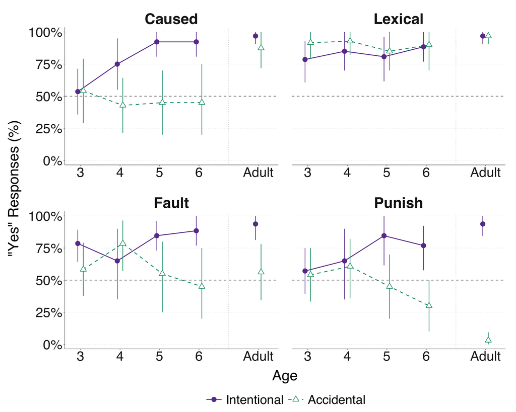

```r
plot_single = function(summary, step = 16L) {
  visible = show_build(summary, step) %>%
    mutate(plot_x = x + unname(comparison_offsets[as.character(condition)]))
  ggplot(visible, aes(x = plot_x, y = mean, color = condition, fill = condition,
                     shape = condition, linetype = condition)) +
    geom_hline(yintercept = c(0, .25, .75, 1), linetype = "dotted", color = "#E0E0E0", linewidth = .45) +
    geom_hline(yintercept = .5, linetype = "dashed", color = "#888888", linewidth = .65) +
    geom_vline(xintercept = 6.75, linetype = "dotted", color = "#C0C0C0", linewidth = .5) +
    geom_line(data = filter(visible, population == "Children"), aes(group = condition),
              linewidth = plot_line_width, show.legend = TRUE) +
    geom_linerange(aes(ymin = lower, ymax = upper), linetype = "solid",
                   linewidth = ci_line_width, show.legend = FALSE) +
    geom_point(size = plot_point_size, stroke = .9, show.legend = TRUE) +
    facet_wrap(~ measure, ncol = 2, drop = FALSE, axes = "all_x", axis.labels = "all_x") +
    scale_color_manual(name = NULL, values = comparison_colors, limits = condition_order, drop = FALSE) +
    scale_fill_manual(name = NULL, values = c(Intentional = comparison_colors[["Intentional"]], Accidental = "white"),
                      limits = condition_order, drop = FALSE) +
    scale_shape_manual(name = NULL, values = condition_shapes, limits = condition_order, drop = FALSE) +
    scale_linetype_manual(name = NULL, values = condition_lines, limits = condition_order, drop = FALSE) +
    scale_x_continuous(breaks = c(single_child_ages, single_adult_position),
                       labels = c(as.character(single_child_ages), "Adult"),
                       limits = c(2.6, single_adult_position + .5), expand = expansion(mult = 0)) +
    scale_y_continuous(breaks = seq(0, 1, .25), labels = function(x) paste0(100 * x, "%"),
                       limits = c(0, 1), expand = expansion(add = .035)) +
    labs(x = "Age", y = '\"Yes\" Responses (%)') + talk_theme(study2_text_size)
}
p.single.full = plot_single(df.single.summary)
save_talk(p.single.full, file.path(single_output, "single_cause_yes_responses_full"), study2_width, study2_height)
p.single.builds = save_builds(df.single.summary, plot_single, single_output,
                              study2_width, study2_height, single_build_names)
p.single.full
```

Build 00 is the blank scaffold. Each measure adds Intentional adults, then Intentional children, then Accidental adults, then Accidental children. Caused occupies 01–04, Lexical 05–08, Fault 09–12 and Punish 13–16. Axes, legends, panels and whitespace are fixed across all 17 builds; Build 16 is the full figure.

## Secondary summary: children pooled across ages 3–6

Pool the same participant means within condition and measure, without giving equal weight to age groups. This is an unadjusted summary of the supplied child sample (50 Intentional, 46 Accidental). Each point’s interval bootstraps participants, not trials. The thin connectors join condition means within each measure only; conditions are between participants, not within-child pairs.

```r
RNGkind("Mersenne-Twister", "Inversion", "Rejection")
set.seed(bootstrap_seed + 5L)
df.single.collapsed = df.single.means %>%
  mutate(measure = factor(measure, levels = measure_order),
         condition = factor(condition, levels = condition_order)) %>%
  arrange(measure, condition, participant) %>% group_by(measure, condition) %>%
  summarise(summary = list(bootstrap_mean(yes_mean)), .groups = "drop") %>% unnest_wider(summary) %>%
  mutate(plot_x = as.numeric(measure) + unname(intention_offsets[as.character(condition)]))
write_csv(select(df.single.collapsed, measure, condition, n, mean, lower, upper),
          file.path(single_output, "single_cause_intentionality_summary_values.csv"))
kable(select(df.single.collapsed, measure, condition, n, mean, lower, upper), digits = 6,
      caption = "Pooled child Yes proportions and pointwise 95% intervals")
```

Pooled child Yes proportions and pointwise 95% intervals

| measure | condition | n | mean | lower | upper |
| --- | --- | --- | --- | --- | --- |
| Caused | Intentional | 50 | 0.780000 | 0.690000 | 0.860000 |
| Caused | Accidental | 46 | 0.467391 | 0.336957 | 0.597826 |
| Lexical | Intentional | 50 | 0.830000 | 0.750000 | 0.900000 |
| Lexical | Accidental | 46 | 0.902174 | 0.836957 | 0.956522 |
| Fault | Intentional | 50 | 0.800000 | 0.710000 | 0.880000 |
| Fault | Accidental | 46 | 0.608696 | 0.489130 | 0.728261 |
| Punish | Intentional | 50 | 0.710000 | 0.600000 | 0.810000 |
| Punish | Accidental | 46 | 0.489130 | 0.369565 | 0.608696 |

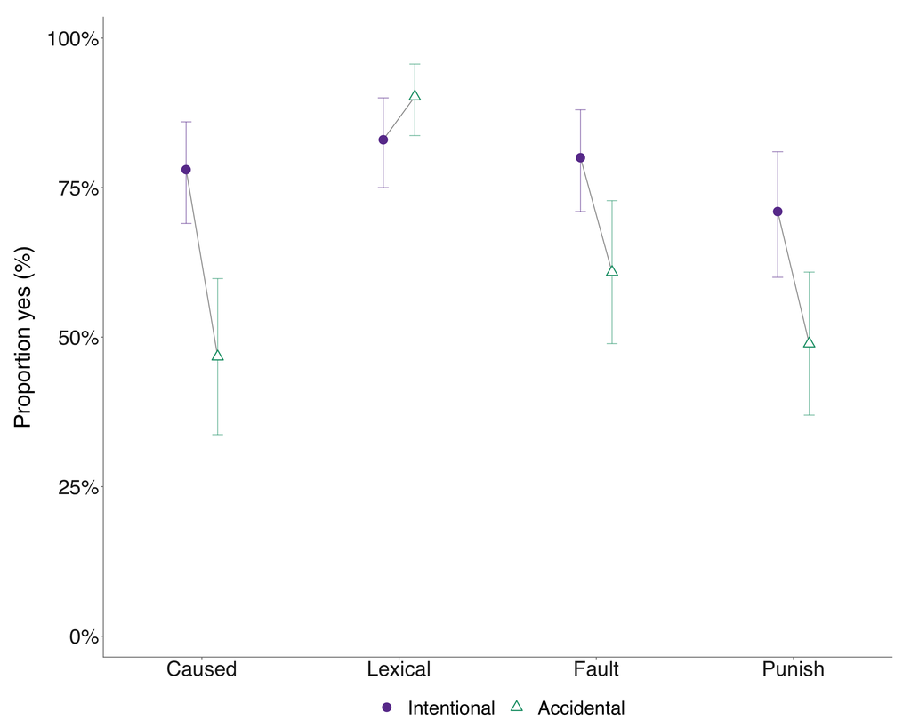

```r
df.single.pairs = df.single.collapsed %>% select(measure, condition, mean, plot_x) %>%
  pivot_wider(names_from = condition, values_from = c(mean, plot_x))
p.single.collapsed = ggplot(df.single.collapsed,
  aes(x = plot_x, y = mean, color = condition, fill = condition, shape = condition)) +
  geom_segment(data = df.single.pairs,
                aes(x = plot_x_Intentional, xend = plot_x_Accidental,
                    y = mean_Intentional, yend = mean_Accidental),
                inherit.aes = FALSE, color = "#A0A0A0", linewidth = .6) +
  geom_errorbar(aes(ymin = lower, ymax = upper), width = .055,
                linewidth = .55, alpha = .55, show.legend = FALSE) +
  geom_point(size = 4.3, stroke = 1, show.legend = TRUE) +
  scale_color_manual(name = NULL, values = comparison_colors, limits = condition_order, drop = FALSE) +
  scale_fill_manual(name = NULL, values = c(Intentional = comparison_colors[["Intentional"]], Accidental = "white"),
                    limits = condition_order, drop = FALSE) +
  scale_shape_manual(name = NULL, values = condition_shapes, limits = condition_order, drop = FALSE) +
  scale_x_continuous(breaks = seq_along(measure_order), labels = measure_order,
                     limits = c(.5, 4.5), expand = expansion(mult = 0)) +
  scale_y_continuous(breaks = seq(0, 1, .25), labels = function(x) paste0(100 * x, "%"),
                     limits = c(0, 1), expand = expansion(add = .035)) +
  labs(x = NULL, y = "Proportion yes (%)") + talk_theme(intention_text_size)
save_talk(p.single.collapsed, file.path(single_output, "single_cause_intentionality_summary"),
          intention_width, intention_height)
p.single.collapsed
```

# Cross-study synthesis: where intention changes judgments

This comparison uses **children aged 3–6 in both studies**: Single Cause (50 Intentional, 46 Accidental) and Study 2 (107 Intentional, 116 Accidental). Matching the available age range avoids comparing Single Cause ages 3–6 with Study 2 ages 3–9. Adults remain separate endpoints in the developmental plots; Study 1 is absent because it has no intentionality manipulation.

For each measure and causal structure, the plotted quantity is **100 × (mean Intentional Yes − mean Accidental Yes)**, in percentage points. Each child’s Yes/No responses are first averaged across available scenarios. We then weight participants equally within study and condition, not age groups equally. These are unadjusted descriptive effects for the matched age range; the studies still have different age compositions and cohorts. The plot does not isolate causal structure from all other between-study differences.

The two conditions contain different participants, so no individual child has an Intentional-minus-Accidental score. For each bootstrap replicate we sample participants independently within each study and condition, preserving all measures and both Study 2 roles together on each sampled participant row. We subtract the two bootstrapped condition means, using 5,000 replicates and their 2.5th and 97.5th percentiles for the 95% interval. Thus both conditions’ uncertainty enters each interval; trial rows are never independently resampled.

```r
df.synthesis.means = bind_rows(
  df.single.means %>% filter(age %in% synthesis_ages) %>%
    transmute(study = "Single Cause", structure = "Single Cause", participant, age,
              condition, measure, yes_mean),
  df.study2.means %>% filter(population == "Children", age %in% synthesis_ages) %>%
    transmute(study = "Study 2", structure = paste("Study 2", role), participant, age,
              condition, measure, yes_mean)) %>%
  mutate(structure = factor(structure, levels = synthesis_order),
         measure = factor(measure, levels = measure_order),
         condition = factor(condition, levels = condition_order))
stopifnot(!anyNA(df.synthesis.means$yes_mean),
          !anyDuplicated(df.synthesis.means[c("study", "participant", "condition", "structure", "measure")]))
df.synthesis.ns = df.synthesis.means %>% distinct(study, participant, age, condition) %>%
  count(study, condition, name = "n")
stopifnot(identical(df.synthesis.ns$n, c(50L, 46L, 107L, 116L)))
kable(df.synthesis.ns, caption = "Synthesis sample: children aged 3–6 only, equally weighted within condition")
```

Synthesis sample: children aged 3–6 only, equally weighted within condition

| study | condition | n |
| --- | --- | --- |
| Single Cause | Intentional | 50 |
| Single Cause | Accidental | 46 |
| Study 2 | Intentional | 107 |
| Study 2 | Accidental | 116 |

```r
# Wide rows keep each participant's four measures and (in Study 2) both roles together.
df.synthesis.wide = df.synthesis.means %>%
  mutate(score = paste(structure, measure, sep = "__")) %>%
  select(study, participant, condition, score, yes_mean) %>%
  pivot_wider(names_from = score, values_from = yes_mean) %>%
  arrange(study, condition, participant)
RNGkind("Mersenne-Twister", "Inversion", "Rejection")
set.seed(bootstrap_seed + 6L)
synthesis_intervals = list()
for (study_name in c("Single Cause", "Study 2")) {
  sample_rows = filter(df.synthesis.wide, study == study_name)
  score_columns = df.synthesis.means %>% filter(study == study_name) %>%
    transmute(score = paste(structure, measure, sep = "__")) %>% distinct() %>% pull(score)
  intentional = sample_rows %>% filter(condition == "Intentional") %>%
    select(all_of(score_columns)) %>% as.matrix()
  accidental = sample_rows %>% filter(condition == "Accidental") %>%
    select(all_of(score_columns)) %>% as.matrix()
  stopifnot(!anyNA(intentional), !anyNA(accidental))
  draws = replicate(bootstrap_replicates, {
    intentional_rows = sample.int(nrow(intentional), replace = TRUE)
    accidental_rows = sample.int(nrow(accidental), replace = TRUE)
    100 * (colMeans(intentional[intentional_rows, , drop = FALSE]) -
             colMeans(accidental[accidental_rows, , drop = FALSE]))
  })
  synthesis_intervals[[study_name]] = tibble(
    score = score_columns,
    lower_pp = apply(draws, 1, quantile, probs = .025),
    upper_pp = apply(draws, 1, quantile, probs = .975))
}
df.synthesis.intervals = bind_rows(synthesis_intervals) %>%
  separate_wider_delim(score, delim = "__", names = c("structure", "measure"))
df.synthesis.summary = df.synthesis.means %>% group_by(structure, measure, condition) %>%
  summarise(n = n(), yes = mean(yes_mean), .groups = "drop") %>%
  pivot_wider(names_from = condition, values_from = c(n, yes)) %>%
  mutate(effect_pp = 100 * (yes_Intentional - yes_Accidental)) %>%
  left_join(df.synthesis.intervals, by = c("structure", "measure"), relationship = "one-to-one") %>%
  mutate(population = "Children ages 3–6",
         structure = factor(structure, levels = synthesis_order),
         measure = factor(measure, levels = measure_order)) %>%
  select(population, measure, structure, n_Intentional, n_Accidental,
         yes_Intentional, yes_Accidental, effect_pp, lower_pp, upper_pp) %>%
  arrange(measure, structure)
stopifnot(nrow(df.synthesis.summary) == 12L,
          all(is.finite(df.synthesis.summary$effect_pp)),
          all(df.synthesis.summary$lower_pp <= df.synthesis.summary$upper_pp))
write_csv(df.synthesis.summary,
          file.path(synthesis_output, "study2_singlecause_intention_effect_comparison_values.csv"))
kable(df.synthesis.summary, digits = 6,
      caption = "Exact plotted intention effects: source Yes proportions, Ns and percentage-point estimates/95% intervals")
```

Exact plotted intention effects: source Yes proportions, Ns and percentage-point estimates/95% intervals

| population | measure | structure | n_Intentional | n_Accidental | yes_Intentional | yes_Accidental | effect_pp | lower_pp | upper_pp |
| --- | --- | --- | --- | --- | --- | --- | --- | --- | --- |
| Children ages 3–6 | Caused | Single Cause | 50 | 46 | 0.780000 | 0.467391 | 31.260870 | 15.391304 | 46.869565 |
| Children ages 3–6 | Caused | Study 2 Distal | 107 | 116 | 0.640187 | 0.551724 | 8.846278 | -1.648505 | 19.372382 |
| Children ages 3–6 | Caused | Study 2 Proximal | 107 | 116 | 0.313084 | 0.387931 | -7.484692 | -17.616923 | 2.682888 |
| Children ages 3–6 | Lexical | Single Cause | 50 | 46 | 0.830000 | 0.902174 | -7.217391 | -17.219565 | 2.956522 |
| Children ages 3–6 | Lexical | Study 2 Distal | 107 | 116 | 0.476636 | 0.284483 | 19.215276 | 9.619723 | 28.775479 |
| Children ages 3–6 | Lexical | Study 2 Proximal | 107 | 116 | 0.551402 | 0.719828 | -16.842572 | -26.401869 | -7.174509 |
| Children ages 3–6 | Fault | Single Cause | 50 | 46 | 0.800000 | 0.608696 | 19.130435 | 4.260870 | 34.173913 |
| Children ages 3–6 | Fault | Study 2 Distal | 107 | 116 | 0.672897 | 0.560345 | 11.255237 | 1.553940 | 20.883016 |
| Children ages 3–6 | Fault | Study 2 Proximal | 107 | 116 | 0.322430 | 0.379310 | -5.688044 | -15.674448 | 4.515791 |
| Children ages 3–6 | Punish | Single Cause | 50 | 46 | 0.710000 | 0.489130 | 22.086957 | 6.304348 | 38.133696 |
| Children ages 3–6 | Punish | Study 2 Distal | 107 | 116 | 0.602804 | 0.431034 | 17.176926 | 6.111022 | 27.811795 |
| Children ages 3–6 | Punish | Study 2 Proximal | 107 | 116 | 0.275701 | 0.344828 | -6.912665 | -16.831292 | 2.969707 |

## Grouped point-range figure

Single Cause uses gray squares, Study 2 Distal uses the existing red circles, and Study 2 Proximal uses the existing blue triangles. Offsets separate the three structures within each measure; there are no connecting lines. Zero means equal Yes endorsement between conditions. The range contains every point and interval end.

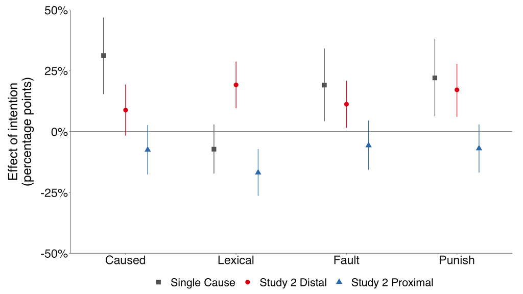

```r
df.synthesis.plot = df.synthesis.summary %>%
  mutate(plot_x = as.numeric(measure) + unname(synthesis_offsets[as.character(structure)]))
synthesis_y_lower = floor(min(0, df.synthesis.plot$lower_pp) / gap_y_step) * gap_y_step
synthesis_y_upper = ceiling(max(0, df.synthesis.plot$upper_pp) / gap_y_step) * gap_y_step
p.synthesis = ggplot(df.synthesis.plot, aes(x = plot_x, y = effect_pp, color = structure, shape = structure)) +
  geom_hline(yintercept = 0, color = "#777777", linewidth = .6) +
  geom_linerange(aes(ymin = lower_pp, ymax = upper_pp), linewidth = ci_line_width, show.legend = FALSE) +
  geom_point(size = 4.5, show.legend = TRUE) +
  scale_color_manual(name = NULL, values = synthesis_colors, limits = synthesis_order, drop = FALSE) +
  scale_shape_manual(name = NULL, values = synthesis_shapes, limits = synthesis_order, drop = FALSE) +
  scale_x_continuous(breaks = seq_along(measure_order), labels = measure_order,
                     limits = c(.5, 4.5), expand = expansion(mult = 0)) +
  scale_y_continuous(breaks = seq(synthesis_y_lower, synthesis_y_upper, gap_y_step),
                     labels = function(x) paste0(x, "%"), limits = c(synthesis_y_lower, synthesis_y_upper),
                     expand = expansion(mult = 0)) +
  labs(x = NULL, y = "Effect of intention\n(percentage points)") + talk_theme(intention_text_size)
save_talk(p.synthesis, file.path(synthesis_output, "study2_singlecause_intention_effect_comparison"),
          intention_width, intention_height)
p.synthesis
```

The intervals are pointwise, descriptive participant bootstraps. Their overlap or separation does not test whether effects differ across studies or measures. In this matched-age sample, Single Cause has the largest positive point estimate for Caused, Fault and Punish. Study 2 Distal is positive for all four measures, with Lexical slightly larger than Punish. Study 2 Proximal is negative for all four; its Lexical interval is below zero, so Proximal is not uniformly near zero. Punish therefore does not uniquely dominate this synthesis. These patterns do not establish a significant ordering of structures or measures.

# Developmental-stage synthesis figures

These **additional** figures show ordinary Yes-response proportions. They do not replace the baseline-change, Study 2 role-gap, pooled Single Cause or cross-study intention-effect figures above. None uses relative attribution. Both Yes contributes 1 to each role and Neither contributes 0 to each role.

## Samples, stages and source datasets

**3–4** includes only children aged 3 or 4; **5–6** includes only ages 5 or 6. Children aged 7–9 stay in the developmental figures but are not included in these new stage summaries. **Adults** remain a separate category, never pooled with children. Participants receive equal weights within study, stage and condition; the individual ages within a stage do not receive equal weights. Stages describe cross-sectional samples, not longitudinal change.

The same screened samples and selection rules used above are retained:

- Study 1 Baseline: exp4 child snapshot and preregistered adult data, N=100 adults.
- Study 2 Intentional/Accidental: exp6 child snapshot and the selected earlier adult pilot, N=20 Intentional and 21 Accidental adults. The main preregistered adult data remain missing.
- Single Cause: exp7 child snapshot and all 32 recovered complete adults, N=16 in each condition. The historical N=30 subset remains unidentified.

Each participant’s available Bike/Mirror responses are averaged **before** group averaging. One missing scenario answer does not become No or discard another role’s answer: the available scenario supplies that participant mean. If both scenarios are missing, that participant contributes no mean for that particular measure/role. Tables report both eligible and contributing Ns. The current samples have both scenarios for every plotted participant mean.

Intervals are the 2.5th and 97.5th percentiles of 5,000 bootstrap means, resampling participants within each displayed study/stage/condition/measure/role cell. They are pointwise intervals for individual means, not intervals or tests for the separation between endpoints. Thin connectors pair **group means**; Intentional and Accidental are different participants. Distal and Proximal are judgments made by the same participants within each chain condition. No trial rows are treated as independent observations.

```r
stage_group = function(population, age) {
  factor(case_when(population == "Adults" ~ "Adults",
                   age %in% 3:4 ~ "3–4", age %in% 5:6 ~ "5–6"), levels = stage_order)
}
df.stage.means = bind_rows(
  df.study1.means, df.study2.means,
  df.single.means %>% mutate(study = "Single Cause", population = "Children", role = "Direct"),
  df.single.adults.means %>% mutate(study = "Single Cause", population = "Adults", age = NA_integer_, role = "Direct")) %>%
  mutate(stage = stage_group(population, age)) %>% filter(!is.na(stage)) %>%
  mutate(measure = factor(measure, levels = measure_order),
         condition = factor(condition, levels = c("Baseline", condition_order)))
stopifnot(!anyDuplicated(df.stage.means[c("study", "participant", "condition", "measure", "role")]),
          all(df.stage.means$scenarios_available == 2L))
df.stage.ns = df.stage.means %>% distinct(study, stage, condition, participant) %>%
  count(study, stage, condition, name = "n")
kable(df.stage.ns, caption = "Exact participants by source study, developmental stage and condition")
```

Exact participants by source study, developmental stage and condition

| study | stage | condition | n |
| --- | --- | --- | --- |
| Single Cause | 3–4 | Intentional | 24 |
| Single Cause | 3–4 | Accidental | 26 |
| Single Cause | 5–6 | Intentional | 26 |
| Single Cause | 5–6 | Accidental | 20 |
| Single Cause | Adults | Intentional | 16 |
| Single Cause | Adults | Accidental | 16 |
| Study 1 | 3–4 | Baseline | 63 |
| Study 1 | 5–6 | Baseline | 59 |
| Study 1 | Adults | Baseline | 100 |
| Study 2 | 3–4 | Intentional | 60 |
| Study 2 | 3–4 | Accidental | 67 |
| Study 2 | 5–6 | Intentional | 47 |
| Study 2 | 5–6 | Accidental | 49 |
| Study 2 | Adults | Intentional | 20 |
| Study 2 | Adults | Accidental | 21 |

```r
# Compute each group once; shared endpoints use identical estimates and intervals
# wherever they appear in the three synthesis figures.
RNGkind("Mersenne-Twister", "Inversion", "Rejection")
set.seed(bootstrap_seed + 8L)
df.stage.summary = df.stage.means %>%
  arrange(study, stage, condition, measure, role, participant) %>%
  group_by(study, population, stage, condition, measure, role) %>%
  summarise(eligible_n = n(), summary = list(bootstrap_mean(yes_mean)), .groups = "drop") %>%
  unnest_wider(summary) %>%
  mutate(yes_pct = 100 * mean, lower_pct = 100 * lower, upper_pct = 100 * upper)
stopifnot(all(df.stage.summary$n == df.stage.summary$eligible_n),
          all(df.stage.summary$lower >= 0), all(df.stage.summary$upper <= 1))

# Reuse the established intention palette and filled-circle/open-triangle keys.
stage_condition_scales = function() {
  list(scale_color_manual(name = NULL, values = comparison_colors, limits = condition_order, drop = FALSE),
       scale_fill_manual(name = NULL, values = c(Intentional = comparison_colors[["Intentional"]], Accidental = "white"),
                         limits = condition_order, drop = FALSE),
       scale_shape_manual(name = NULL, values = condition_shapes, limits = condition_order, drop = FALSE))
}
percent_labels = function(x) paste0(100 * x, "%")
```

## Intention and causal role in punishment

For Single Cause and Chain: Distal, the condition varies the judged person’s own intention. For **Chain: Proximal**, it varies the **distal person’s intention**, not the proximal producer’s own intention. That distinction is essential to reading the three targets. The separate adult cohorts have the provenance and sample limitations above; this is not an isolated causal-structure experiment.

```r
df.punishment.summary = df.stage.summary %>%
  filter(study %in% c("Single Cause", "Study 2"), measure == "Punish") %>%
  mutate(target = factor(if_else(study == "Single Cause", "Single Cause", paste0("Chain: ", role)),
                         levels = stage_target_order)) %>% arrange(stage, target, condition)
stopifnot(nrow(df.punishment.summary) == 18L)
write_csv(df.punishment.summary, file.path(synthesis_output, "punishment_causal_structure_intention_values.csv"))
kable(select(df.punishment.summary, stage, target, condition, eligible_n, n, yes_pct, lower_pct, upper_pct),
      digits = 6, caption = "Punishment: exact group means, Ns and 95% intervals (%); CSV retains full precision")
```

Punishment: exact group means, Ns and 95% intervals (%); CSV retains full precision

| stage | target | condition | eligible_n | n | yes_pct | lower_pct | upper_pct |
| --- | --- | --- | --- | --- | --- | --- | --- |
| 3–4 | Single Cause | Intentional | 24 | 24 | 60.416667 | 43.750000 | 75.00000 |
| 3–4 | Single Cause | Accidental | 26 | 26 | 57.692308 | 42.307692 | 73.07692 |
| 3–4 | Chain: Distal | Intentional | 60 | 60 | 54.166667 | 43.333333 | 64.16667 |
| 3–4 | Chain: Distal | Accidental | 67 | 67 | 45.522388 | 35.820896 | 55.22388 |
| 3–4 | Chain: Proximal | Intentional | 60 | 60 | 38.333333 | 28.333333 | 48.33333 |
| 3–4 | Chain: Proximal | Accidental | 67 | 67 | 40.298507 | 30.597015 | 50.00000 |
| 5–6 | Single Cause | Intentional | 26 | 26 | 80.769231 | 67.307692 | 92.30769 |
| 5–6 | Single Cause | Accidental | 20 | 20 | 37.500000 | 20.000000 | 55.00000 |
| 5–6 | Chain: Distal | Intentional | 47 | 47 | 68.085106 | 56.382979 | 79.78723 |
| 5–6 | Chain: Distal | Accidental | 49 | 49 | 39.795918 | 28.571429 | 51.02041 |
| 5–6 | Chain: Proximal | Intentional | 47 | 47 | 13.829787 | 6.382979 | 22.34043 |
| 5–6 | Chain: Proximal | Accidental | 49 | 49 | 26.530612 | 16.326531 | 36.73469 |
| Adults | Single Cause | Intentional | 16 | 16 | 93.750000 | 84.375000 | 100.00000 |
| Adults | Single Cause | Accidental | 16 | 16 | 3.125000 | 0.000000 | 9.37500 |
| Adults | Chain: Distal | Intentional | 20 | 20 | 92.500000 | 80.000000 | 100.00000 |
| Adults | Chain: Distal | Accidental | 21 | 21 | 30.952381 | 14.285714 | 47.61905 |
| Adults | Chain: Proximal | Intentional | 20 | 20 | 5.000000 | 0.000000 | 12.50000 |
| Adults | Chain: Proximal | Accidental | 21 | 21 | 4.761905 | 0.000000 | 14.28571 |

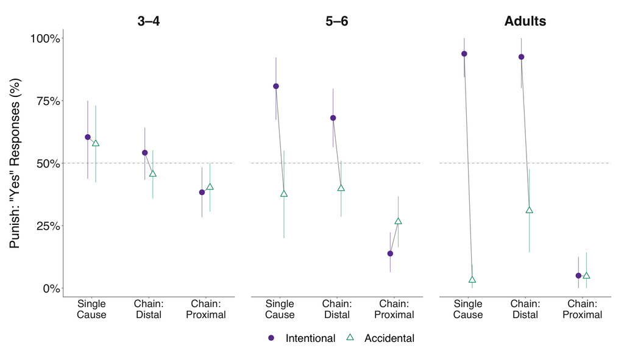

```r
df.punishment.plot = df.punishment.summary %>%
  mutate(plot_x = as.numeric(target) + unname(stage_condition_offsets[as.character(condition)]))
df.punishment.pairs = df.punishment.plot %>% select(stage, target, condition, mean, plot_x) %>%
  pivot_wider(names_from = condition, values_from = c(mean, plot_x))
p.punishment = ggplot(df.punishment.plot,
  aes(x = plot_x, y = mean, color = condition, fill = condition, shape = condition)) +
  geom_hline(yintercept = .5, linetype = "dashed", color = "#B0B0B0", linewidth = .5) +
  geom_segment(data = df.punishment.pairs,
               aes(x = plot_x_Intentional, xend = plot_x_Accidental, y = mean_Intentional, yend = mean_Accidental),
               inherit.aes = FALSE, color = "#A0A0A0", linewidth = .55) +
  geom_linerange(aes(ymin = lower, ymax = upper), linewidth = .45, alpha = .65, show.legend = FALSE) +
  geom_point(size = 3.8, stroke = .9) + stage_condition_scales() +
  facet_wrap(~ stage, nrow = 1, drop = FALSE) +
  scale_x_continuous(breaks = 1:3, labels = c("Single\nCause", "Chain:\nDistal", "Chain:\nProximal"),
                     limits = c(.5, 3.5), expand = expansion(mult = 0)) +
  scale_y_continuous(breaks = seq(0, 1, .25), labels = percent_labels,
                     limits = c(0, 1), expand = expansion(add = .035)) +
  labs(x = NULL, y = 'Punish: "Yes" Responses (%)') + talk_theme(stage_text_size) +
  theme(axis.text.x = element_text(size = 19))
save_talk(p.punishment, file.path(synthesis_output, "punishment_causal_structure_intention"),
          intention_width, intention_height)
p.punishment
```

## What changes when intention changes in Single Cause?

Direct physical production remains part of the Single Cause design in both conditions. Each horizontal connector joins Intentional and Accidental group means for one judgment, without connecting different measures. This displays the raw endorsement pattern rather than a derived effect score.

```r
df.single.stage.summary = df.stage.summary %>% filter(study == "Single Cause") %>%
  arrange(stage, measure, condition)
stopifnot(nrow(df.single.stage.summary) == 24L)
write_csv(df.single.stage.summary, file.path(synthesis_output, "single_cause_intention_dumbbells_values.csv"))
kable(select(df.single.stage.summary, stage, measure, condition, eligible_n, n, yes_pct, lower_pct, upper_pct),
      digits = 6, caption = "Single Cause: exact group means, Ns and 95% intervals (%); CSV retains full precision")
```

Single Cause: exact group means, Ns and 95% intervals (%); CSV retains full precision

| stage | measure | condition | eligible_n | n | yes_pct | lower_pct | upper_pct |
| --- | --- | --- | --- | --- | --- | --- | --- |
| 3–4 | Caused | Intentional | 24 | 24 | 62.50000 | 47.91667 | 77.08333 |
| 3–4 | Caused | Accidental | 26 | 26 | 48.07692 | 30.76923 | 65.38461 |
| 3–4 | Lexical | Intentional | 24 | 24 | 81.25000 | 68.75000 | 91.66667 |
| 3–4 | Lexical | Accidental | 26 | 26 | 92.30769 | 84.61539 | 98.07692 |
| 3–4 | Fault | Intentional | 24 | 24 | 72.91667 | 58.33333 | 87.50000 |
| 3–4 | Fault | Accidental | 26 | 26 | 69.23077 | 53.84615 | 84.61539 |
| 3–4 | Punish | Intentional | 24 | 24 | 60.41667 | 43.75000 | 75.00000 |
| 3–4 | Punish | Accidental | 26 | 26 | 57.69231 | 42.30769 | 73.07692 |
| 5–6 | Caused | Intentional | 26 | 26 | 92.30769 | 84.61539 | 98.07692 |
| 5–6 | Caused | Accidental | 20 | 20 | 45.00000 | 25.00000 | 65.00000 |
| 5–6 | Lexical | Intentional | 26 | 26 | 84.61539 | 73.07692 | 94.23077 |
| 5–6 | Lexical | Accidental | 20 | 20 | 87.50000 | 75.00000 | 97.50000 |
| 5–6 | Fault | Intentional | 26 | 26 | 86.53846 | 76.92308 | 94.23077 |
| 5–6 | Fault | Accidental | 20 | 20 | 50.00000 | 30.00000 | 70.00000 |
| 5–6 | Punish | Intentional | 26 | 26 | 80.76923 | 67.30769 | 92.30769 |
| 5–6 | Punish | Accidental | 20 | 20 | 37.50000 | 20.00000 | 55.00000 |
| Adults | Caused | Intentional | 16 | 16 | 96.87500 | 90.62500 | 100.00000 |
| Adults | Caused | Accidental | 16 | 16 | 87.50000 | 71.87500 | 100.00000 |
| Adults | Lexical | Intentional | 16 | 16 | 96.87500 | 90.62500 | 100.00000 |
| Adults | Lexical | Accidental | 16 | 16 | 96.87500 | 90.62500 | 100.00000 |
| Adults | Fault | Intentional | 16 | 16 | 93.75000 | 81.25000 | 100.00000 |
| Adults | Fault | Accidental | 16 | 16 | 56.25000 | 34.37500 | 78.12500 |
| Adults | Punish | Intentional | 16 | 16 | 93.75000 | 84.37500 | 100.00000 |
| Adults | Punish | Accidental | 16 | 16 | 3.12500 | 0.00000 | 9.37500 |

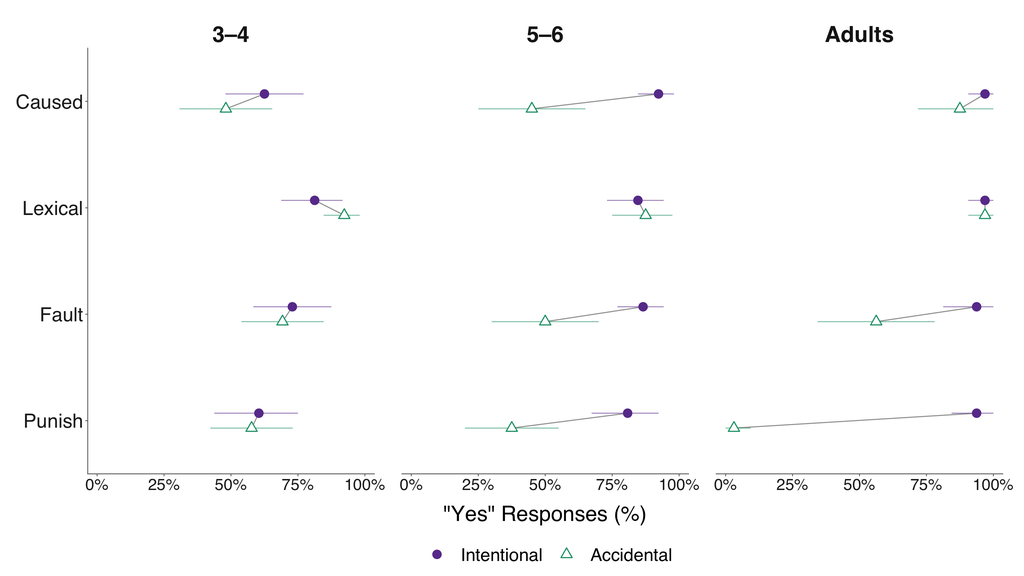

```r
df.single.stage.plot = df.single.stage.summary %>%
  mutate(plot_y = 5 - as.numeric(measure) - unname(stage_condition_offsets[as.character(condition)]))
df.single.stage.pairs = df.single.stage.plot %>% select(stage, measure, condition, mean, plot_y) %>%
  pivot_wider(names_from = condition, values_from = c(mean, plot_y))
p.single.stage = ggplot(df.single.stage.plot,
  aes(x = mean, y = plot_y, color = condition, fill = condition, shape = condition)) +
  geom_segment(data = df.single.stage.pairs,
               aes(x = mean_Intentional, xend = mean_Accidental, y = plot_y_Intentional, yend = plot_y_Accidental),
               inherit.aes = FALSE, color = "#A0A0A0", linewidth = .55) +
  geom_segment(aes(x = lower, xend = upper, yend = plot_y), linewidth = .45, alpha = .65, show.legend = FALSE) +
  geom_point(size = 3.8, stroke = .9) + stage_condition_scales() +
  facet_wrap(~ stage, nrow = 1, drop = FALSE) +
  scale_x_continuous(breaks = seq(0, 1, .25), labels = percent_labels,
                     limits = c(0, 1), expand = expansion(add = .035)) +
  scale_y_continuous(breaks = 1:4, labels = rev(measure_order),
                     limits = c(.5, 4.5), expand = expansion(mult = 0)) +
  labs(x = '"Yes" Responses (%)', y = NULL) + talk_theme(stage_text_size) +
  theme(axis.text.x = element_text(size = 18))
save_talk(p.single.stage, file.path(synthesis_output, "single_cause_intention_dumbbells"),
          intention_width, intention_height)
p.single.stage
```

## Causal language across structure and intention

Baseline is Study 1; Intentional and Accidental are Study 2. Each connector joins the Distal and Proximal group means at a single condition position. There are no lines between Baseline, Intentional and Accidental. Existing role colors identify Distal (red) and Proximal (blue), with role shapes only. This preserves the distinction between the earlier initiator and the direct producer without imposing a predicted Caused/Lexical mapping.

```r
df.role.mapping.summary = df.stage.summary %>%
  filter(study %in% c("Study 1", "Study 2"), measure %in% c("Caused", "Lexical")) %>%
  mutate(measure = factor(measure, levels = c("Caused", "Lexical")),
         role = factor(role, levels = role_order)) %>% arrange(measure, stage, condition, role)
stopifnot(nrow(df.role.mapping.summary) == 36L)
write_csv(df.role.mapping.summary, file.path(synthesis_output, "caused_lexical_role_mapping_values.csv"))
kable(select(df.role.mapping.summary, study, stage, measure, condition, role, eligible_n, n, yes_pct, lower_pct, upper_pct),
      digits = 6, caption = "Caused/Lexical role mapping: exact means, Ns and 95% intervals (%); CSV retains full precision")
```

Caused/Lexical role mapping: exact means, Ns and 95% intervals (%); CSV retains full precision

| study | stage | measure | condition | role | eligible_n | n | yes_pct | lower_pct | upper_pct |
| --- | --- | --- | --- | --- | --- | --- | --- | --- | --- |
| Study 1 | 3–4 | Caused | Baseline | Distal | 63 | 63 | 57.14286 | 47.61905 | 66.66667 |
| Study 1 | 3–4 | Caused | Baseline | Proximal | 63 | 63 | 53.17460 | 43.65079 | 61.90476 |
| Study 2 | 3–4 | Caused | Intentional | Distal | 60 | 60 | 52.50000 | 41.66667 | 63.33333 |
| Study 2 | 3–4 | Caused | Intentional | Proximal | 60 | 60 | 38.33333 | 28.33333 | 48.33333 |
| Study 2 | 3–4 | Caused | Accidental | Distal | 67 | 67 | 50.00000 | 41.04478 | 58.95522 |
| Study 2 | 3–4 | Caused | Accidental | Proximal | 67 | 67 | 44.02985 | 35.07463 | 52.98508 |
| Study 1 | 5–6 | Caused | Baseline | Distal | 59 | 59 | 63.55932 | 53.38983 | 72.88136 |
| Study 1 | 5–6 | Caused | Baseline | Proximal | 59 | 59 | 37.28814 | 27.94492 | 47.45763 |
| Study 2 | 5–6 | Caused | Intentional | Distal | 47 | 47 | 78.72340 | 69.14894 | 88.29787 |
| Study 2 | 5–6 | Caused | Intentional | Proximal | 47 | 47 | 22.34043 | 13.82979 | 31.91489 |
| Study 2 | 5–6 | Caused | Accidental | Distal | 49 | 49 | 62.24490 | 52.04082 | 72.44898 |
| Study 2 | 5–6 | Caused | Accidental | Proximal | 49 | 49 | 31.63265 | 20.40816 | 42.85714 |
| Study 1 | Adults | Caused | Baseline | Distal | 100 | 100 | 82.50000 | 76.50000 | 88.00000 |
| Study 1 | Adults | Caused | Baseline | Proximal | 100 | 100 | 37.50000 | 29.50000 | 45.50000 |
| Study 2 | Adults | Caused | Intentional | Distal | 20 | 20 | 95.00000 | 87.50000 | 100.00000 |
| Study 2 | Adults | Caused | Intentional | Proximal | 20 | 20 | 25.00000 | 10.00000 | 42.50000 |
| Study 2 | Adults | Caused | Accidental | Distal | 21 | 21 | 76.19048 | 59.52381 | 90.47619 |
| Study 2 | Adults | Caused | Accidental | Proximal | 21 | 21 | 59.52381 | 42.85714 | 76.19048 |
| Study 1 | 3–4 | Lexical | Baseline | Distal | 63 | 63 | 45.23810 | 36.50794 | 53.96825 |
| Study 1 | 3–4 | Lexical | Baseline | Proximal | 63 | 63 | 69.04762 | 61.11111 | 76.98413 |
| Study 2 | 3–4 | Lexical | Intentional | Distal | 60 | 60 | 50.00000 | 40.00000 | 60.00000 |
| Study 2 | 3–4 | Lexical | Intentional | Proximal | 60 | 60 | 50.00000 | 40.00000 | 60.00000 |
| Study 2 | 3–4 | Lexical | Accidental | Distal | 67 | 67 | 32.08955 | 23.88060 | 41.04478 |
| Study 2 | 3–4 | Lexical | Accidental | Proximal | 67 | 67 | 69.40299 | 61.19403 | 76.86567 |
| Study 1 | 5–6 | Lexical | Baseline | Distal | 59 | 59 | 22.03390 | 14.40678 | 30.50848 |
| Study 1 | 5–6 | Lexical | Baseline | Proximal | 59 | 59 | 79.66102 | 72.03390 | 87.28814 |
| Study 2 | 5–6 | Lexical | Intentional | Distal | 47 | 47 | 44.68085 | 32.97872 | 56.38298 |
| Study 2 | 5–6 | Lexical | Intentional | Proximal | 47 | 47 | 61.70213 | 50.00000 | 73.40426 |
| Study 2 | 5–6 | Lexical | Accidental | Distal | 49 | 49 | 23.46939 | 16.32653 | 30.61225 |
| Study 2 | 5–6 | Lexical | Accidental | Proximal | 49 | 49 | 75.51020 | 67.34694 | 83.67347 |
| Study 1 | Adults | Lexical | Baseline | Distal | 100 | 100 | 42.00000 | 33.50000 | 50.01250 |
| Study 1 | Adults | Lexical | Baseline | Proximal | 100 | 100 | 64.00000 | 56.50000 | 71.50000 |
| Study 2 | Adults | Lexical | Intentional | Distal | 20 | 20 | 62.50000 | 45.00000 | 80.00000 |
| Study 2 | Adults | Lexical | Intentional | Proximal | 20 | 20 | 60.00000 | 40.00000 | 77.50000 |
| Study 2 | Adults | Lexical | Accidental | Distal | 21 | 21 | 26.19048 | 9.52381 | 42.85714 |
| Study 2 | Adults | Lexical | Accidental | Proximal | 21 | 21 | 71.42857 | 52.38095 | 88.09524 |

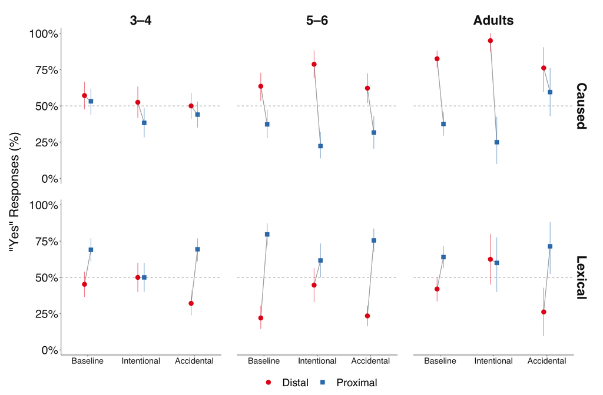

```r
df.role.mapping.plot = df.role.mapping.summary %>%
  mutate(plot_x = as.numeric(condition) + unname(study1_role_offsets[as.character(role)]))
df.role.mapping.pairs = df.role.mapping.plot %>% select(stage, measure, condition, role, mean, plot_x) %>%
  pivot_wider(names_from = role, values_from = c(mean, plot_x))
p.role.mapping = ggplot(df.role.mapping.plot, aes(x = plot_x, y = mean, color = role, fill = role, shape = role)) +
  geom_hline(yintercept = .5, linetype = "dashed", color = "#B0B0B0", linewidth = .5) +
  geom_segment(data = df.role.mapping.pairs,
               aes(x = plot_x_Distal, xend = plot_x_Proximal, y = mean_Distal, yend = mean_Proximal),
               inherit.aes = FALSE, color = "#A0A0A0", linewidth = .55) +
  geom_linerange(aes(ymin = lower, ymax = upper), linewidth = .45, alpha = .65, show.legend = FALSE) +
  geom_point(size = 3.4, stroke = .8) +
  scale_color_manual(name = NULL, values = study2_role_colors, limits = role_order, drop = FALSE) +
  scale_fill_manual(name = NULL, values = study2_role_colors, limits = role_order, drop = FALSE) +
  scale_shape_manual(name = NULL, values = study1_role_shapes, limits = role_order, drop = FALSE) +
  facet_grid(measure ~ stage, drop = FALSE) +
  scale_x_continuous(breaks = 1:3, labels = c("Baseline", "Intentional", "Accidental"),
                     limits = c(.5, 3.5), expand = expansion(mult = 0)) +
  scale_y_continuous(breaks = seq(0, 1, .25), labels = percent_labels,
                     limits = c(0, 1), expand = expansion(add = .035)) +
  labs(x = NULL, y = '"Yes" Responses (%)') + talk_theme(stage_text_size) +
  theme(axis.text.x = element_text(size = 16))
save_talk(p.role.mapping, file.path(synthesis_output, "caused_lexical_role_mapping"), intention_width, 10.5)
p.role.mapping
```

# Additional candidate synthesis plots

These six outputs are **additions**: each candidate has a main version without intervals and a backup with pointwise 95% participant-bootstrap intervals. Existing figures and builds keep their filenames, designs, data and availability. Both versions of a candidate use the same table, positions, scales and legend; only the interval layer differs. Every table below reports exactly the plotted values, with full precision retained in its new CSV.

The samples and source datasets are those documented in the developmental-stage section above. Ages **3 and 4 → 3–4**; ages **5 and 6 → 5–6**. Adults stay separate, and ages 7–9 do not enter these grouped candidates. Study 1 adults are N=100; Study 2 adults are the earlier pilot (N=20 Intentional, 21 Accidental); Single Cause uses all 32 recovered adults (N=16 per condition). The historical Single Cause N=30 exclusions and missing Study 2 main adult data remain unresolved.

Yes and No stay independent 1/0 endorsements for every role. Both Yes and Neither remain valid responses. No relative-distal score enters these figures. Available scenarios are averaged within participant before participants are averaged within a group. Missing answers never become No, and no participant’s other valid judgments are discarded because one question is missing.

```r
check_labels(df.stage.means$study, c("Study 1", "Study 2", "Single Cause"), "candidate source study")
stopifnot(all(df.stage.means$condition[df.stage.means$study == "Study 1"] == "Baseline"),
          all(df.stage.means$condition[df.stage.means$study != "Study 1"] %in% condition_order),
          setequal(as.character(df.stage.means$stage), stage_order),
          all(df.stage.means$population == "Adults" | df.stage.means$age %in% 3:6),
          !anyDuplicated(df.stage.means[c("study", "participant", "stage", "condition", "measure", "role")]),
          all(is.na(df.stage.means$yes_mean) | dplyr::between(df.stage.means$yes_mean, 0, 1)))
mean_available = function(values) {
  if (all(is.na(values))) NA_real_ else mean(values, na.rm = TRUE)
}
# Both candidate versions share a scale large enough for every point and interval.
# Differences of two binary-endorsement proportions have the range -100 to 100 pp.
candidate_difference_scale = function(limits = c(-100, 100)) {
  scale_y_continuous(breaks = seq(limits[1], limits[2], 50), labels = function(x) paste0(x, "%"),
                     limits = limits, expand = expansion(add = 3.5))
}
```

## Candidate 1: punishment, intention and causal target — horizontal

This reuses all 18 endpoint estimates and intervals from the existing vertical punishment figure. The connector is horizontal and joins only the two conditions for the same target. Purple filled circles mark Intentional and teal open triangles mark Accidental. Transparent triangle interiors keep an overlapping circle visible when means nearly coincide. For Chain: Proximal, the condition varies the **distal person’s intention**, not the proximal person’s own intention.

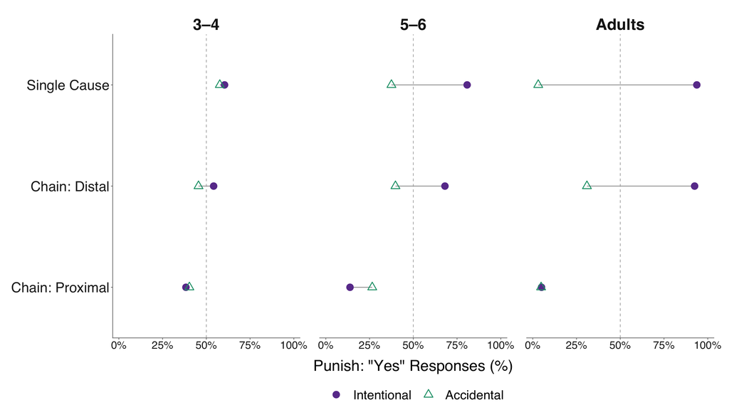

```r
df.punishment.horizontal = df.punishment.summary %>%
  mutate(target_y = 4 - as.numeric(target))
df.punishment.horizontal.pairs = df.punishment.horizontal %>%
  select(stage, target, target_y, condition, mean) %>%
  pivot_wider(names_from = condition, values_from = mean)
stopifnot(nrow(df.punishment.horizontal) == 18L,
          all(dplyr::between(df.punishment.horizontal$mean, 0, 1)),
          all(dplyr::between(df.punishment.horizontal$lower, 0, 1)),
          all(dplyr::between(df.punishment.horizontal$upper, 0, 1)))
plot_punishment_horizontal = function(with_ci = FALSE) {
  p = ggplot(df.punishment.horizontal,
              aes(x = mean, y = target_y, color = condition, fill = condition, shape = condition)) +
    geom_vline(xintercept = .5, linetype = "dashed", color = "#B0B0B0", linewidth = .5) +
    geom_segment(data = df.punishment.horizontal.pairs,
                 aes(x = Intentional, xend = Accidental, y = target_y, yend = target_y),
                 inherit.aes = FALSE, color = "#A0A0A0", linewidth = .6)
  if (with_ci) {
    p = p + geom_segment(aes(x = lower, xend = upper, yend = target_y),
                          linewidth = .5, alpha = .55, show.legend = FALSE)
  }
  p + geom_point(size = 4.2, stroke = 1) +
    scale_color_manual(name = NULL, values = comparison_colors, limits = condition_order, drop = FALSE) +
    scale_fill_manual(name = NULL, values = c(Intentional = comparison_colors[["Intentional"]], Accidental = NA),
                       limits = condition_order, drop = FALSE) +
    scale_shape_manual(name = NULL, values = condition_shapes, limits = condition_order, drop = FALSE) +
    facet_wrap(~ stage, nrow = 1, drop = FALSE) +
    scale_x_continuous(breaks = seq(0, 1, .25), labels = percent_labels,
                       limits = c(0, 1), expand = expansion(add = .035)) +
    scale_y_continuous(breaks = 1:3, labels = rev(stage_target_order),
                       limits = c(.5, 3.5), expand = expansion(mult = 0)) +
    labs(x = 'Punish: "Yes" Responses (%)', y = NULL) + talk_theme(stage_text_size) +
    theme(axis.text.x = element_text(size = 17))
}
p.punishment.horizontal = plot_punishment_horizontal()
p.punishment.horizontal.ci = plot_punishment_horizontal(with_ci = TRUE)
save_talk(p.punishment.horizontal, file.path(synthesis_output, "punishment_causal_structure_horizontal"), 16, 9)
save_talk(p.punishment.horizontal.ci, file.path(synthesis_output, "punishment_causal_structure_horizontal_with_ci"), 16, 9)
p.punishment.horizontal
```

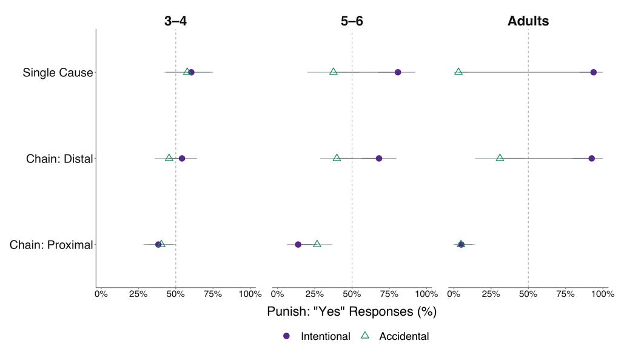

```r
p.punishment.horizontal.ci
```

```r
df.punishment.horizontal.values = df.punishment.summary %>%
  select(study, population, stage, target, condition, measure, eligible_n, n, yes_pct, lower_pct, upper_pct)
write_csv(df.punishment.horizontal.values,
          file.path(synthesis_output, "punishment_causal_structure_horizontal_values.csv"))
kable(df.punishment.horizontal.values, digits = 6,
      caption = "Horizontal punishment candidate: mean %, N and backup 95% CI; identical endpoints to the vertical figure")
```

Horizontal punishment candidate: mean %, N and backup 95% CI; identical endpoints to the vertical figure

| study | population | stage | target | condition | measure | eligible_n | n | yes_pct | lower_pct | upper_pct |
| --- | --- | --- | --- | --- | --- | --- | --- | --- | --- | --- |
| Single Cause | Children | 3–4 | Single Cause | Intentional | Punish | 24 | 24 | 60.416667 | 43.750000 | 75.00000 |
| Single Cause | Children | 3–4 | Single Cause | Accidental | Punish | 26 | 26 | 57.692308 | 42.307692 | 73.07692 |
| Study 2 | Children | 3–4 | Chain: Distal | Intentional | Punish | 60 | 60 | 54.166667 | 43.333333 | 64.16667 |
| Study 2 | Children | 3–4 | Chain: Distal | Accidental | Punish | 67 | 67 | 45.522388 | 35.820896 | 55.22388 |
| Study 2 | Children | 3–4 | Chain: Proximal | Intentional | Punish | 60 | 60 | 38.333333 | 28.333333 | 48.33333 |
| Study 2 | Children | 3–4 | Chain: Proximal | Accidental | Punish | 67 | 67 | 40.298507 | 30.597015 | 50.00000 |
| Single Cause | Children | 5–6 | Single Cause | Intentional | Punish | 26 | 26 | 80.769231 | 67.307692 | 92.30769 |
| Single Cause | Children | 5–6 | Single Cause | Accidental | Punish | 20 | 20 | 37.500000 | 20.000000 | 55.00000 |
| Study 2 | Children | 5–6 | Chain: Distal | Intentional | Punish | 47 | 47 | 68.085106 | 56.382979 | 79.78723 |
| Study 2 | Children | 5–6 | Chain: Distal | Accidental | Punish | 49 | 49 | 39.795918 | 28.571429 | 51.02041 |
| Study 2 | Children | 5–6 | Chain: Proximal | Intentional | Punish | 47 | 47 | 13.829787 | 6.382979 | 22.34043 |
| Study 2 | Children | 5–6 | Chain: Proximal | Accidental | Punish | 49 | 49 | 26.530612 | 16.326531 | 36.73469 |
| Single Cause | Adults | Adults | Single Cause | Intentional | Punish | 16 | 16 | 93.750000 | 84.375000 | 100.00000 |
| Single Cause | Adults | Adults | Single Cause | Accidental | Punish | 16 | 16 | 3.125000 | 0.000000 | 9.37500 |
| Study 2 | Adults | Adults | Chain: Distal | Intentional | Punish | 20 | 20 | 92.500000 | 80.000000 | 100.00000 |
| Study 2 | Adults | Adults | Chain: Distal | Accidental | Punish | 21 | 21 | 30.952381 | 14.285714 | 47.61905 |
| Study 2 | Adults | Adults | Chain: Proximal | Intentional | Punish | 20 | 20 | 5.000000 | 0.000000 | 12.50000 |
| Study 2 | Adults | Adults | Chain: Proximal | Accidental | Punish | 21 | 21 | 4.761905 | 0.000000 | 14.28571 |

## Candidate 2: Caused versus Lexical role preference

For each participant × scenario × measure, subtract the Proximal binary answer from the Distal binary answer. Then average the available **paired-scenario differences within participant**, and finally average those participant means within source study, stage, condition and measure. Both Yes and Neither yield zero; Distal-only yields +1 and Proximal-only yields −1. Multiply by 100 to show percentage points. A scenario missing either role cannot supply a paired difference; other complete scenarios and other judgments remain available. Participants with no complete pair for one measure are omitted only from that measure’s mean, with eligible/contributing Ns reported separately.

The bootstrap resamples each participant’s paired-role mean, preserving the within-person role pairing. It does not subtract separately bootstrapped role means or calculate Distal/(Distal+Proximal). Lines connect experimental-context group means, not repeated measurements of the same people across conditions or studies. The new fixed Set1 measure palette is shared with Candidate 3.

```r
role_preference_means = function(responses) {
  check_response_rows(responses)
  responses %>%
    mutate(role = factor(role, levels = role_order)) %>%
    pivot_wider(id_cols = c(study, population, participant, age, condition, scenario, measure),
                 names_from = role, values_from = endorsed, names_expand = TRUE) %>%
    mutate(scenario_difference = Distal - Proximal) %>%
    group_by(study, population, participant, age, condition, measure) %>%
    summarise(paired_scenarios = sum(!is.na(scenario_difference)),
              role_difference = mean_available(scenario_difference), .groups = "drop")
}
df.role.preference.responses = bind_rows(
  df.study1.adults.responses, df.study1.children.responses,
  df.study2.adults.responses, df.study2.children.responses) %>%
  filter(measure %in% c("Caused", "Lexical"), population == "Adults" | age %in% 3:6)
check_labels(df.role.preference.responses$study, c("Study 1", "Study 2"), "role-preference study")
df.role.preference.means = role_preference_means(df.role.preference.responses) %>%
  mutate(stage = stage_group(population, age),
         condition = factor(condition, levels = c("Baseline", condition_order)),
         measure = factor(measure, levels = c("Caused", "Lexical")))
stopifnot(!anyDuplicated(df.role.preference.means[c("study", "participant", "condition", "measure")]),
          !anyNA(df.role.preference.means$stage),
          all(df.role.preference.means$paired_scenarios %in% 0:2),
          all(is.na(df.role.preference.means$role_difference) |
                dplyr::between(df.role.preference.means$role_difference, -1, 1)))
RNGkind("Mersenne-Twister", "Inversion", "Rejection")
set.seed(bootstrap_seed + 9L)
df.role.preference.summary = df.role.preference.means %>%
  arrange(study, stage, condition, measure, participant) %>%
  group_by(study, population, stage, condition, measure) %>%
  summarise(eligible_n = n(), summary = list(bootstrap_mean(role_difference)), .groups = "drop") %>%
  unnest_wider(summary) %>%
  transmute(study, population, stage, condition, measure, eligible_n, n,
            mean_pp = 100 * mean, lower_pp = 100 * lower, upper_pp = 100 * upper) %>%
  arrange(stage, measure, condition)
stopifnot(nrow(df.role.preference.summary) == 18L,
          all(dplyr::between(df.role.preference.summary$mean_pp, -100, 100)),
          all(dplyr::between(df.role.preference.summary$lower_pp, -100, 100)),
          all(dplyr::between(df.role.preference.summary$upper_pp, -100, 100)),
          all(df.role.preference.summary$n <= df.role.preference.summary$eligible_n),
          nrow(count(df.role.preference.summary, stage, condition, measure)) == 18L)
```

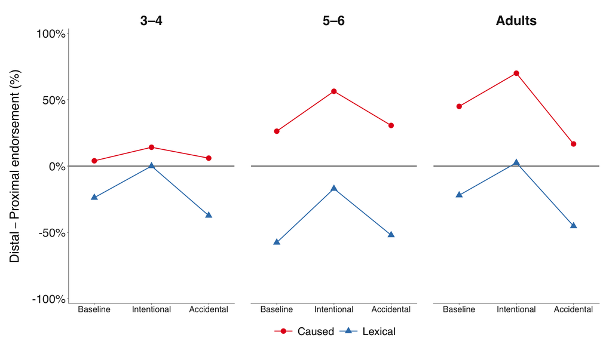

```r
plot_role_preference = function(with_ci = FALSE) {
  p = ggplot(df.role.preference.summary,
              aes(x = condition, y = mean_pp, color = measure, shape = measure, group = measure)) +
    geom_hline(yintercept = 0, color = "#666666", linewidth = .85) +
    geom_line(linewidth = .8)
  if (with_ci) {
    p = p + geom_linerange(aes(ymin = lower_pp, ymax = upper_pp),
                            linewidth = .55, alpha = .6, show.legend = FALSE)
  }
  p + geom_point(size = 4.5) +
    facet_wrap(~ stage, nrow = 1, drop = FALSE) +
    scale_color_manual(name = NULL, values = measure_colors, limits = c("Caused", "Lexical"), drop = FALSE) +
    scale_shape_manual(name = NULL, values = measure_shapes, limits = c("Caused", "Lexical"), drop = FALSE) +
    scale_x_discrete(limits = c("Baseline", condition_order), drop = FALSE, expand = expansion(add = .45)) +
    candidate_difference_scale() +
    labs(x = NULL, y = expression(plain("Distal") - plain("Proximal") ~ plain("endorsement (%)"))) +
    talk_theme(stage_text_size) + theme(axis.text.x = element_text(size = 16))
}
p.role.preference = plot_role_preference()
p.role.preference.ci = plot_role_preference(with_ci = TRUE)
save_talk(p.role.preference, file.path(synthesis_output, "caused_lexical_role_preference"), 16, 9)
save_talk(p.role.preference.ci, file.path(synthesis_output, "caused_lexical_role_preference_with_ci"), 16, 9)
p.role.preference
```

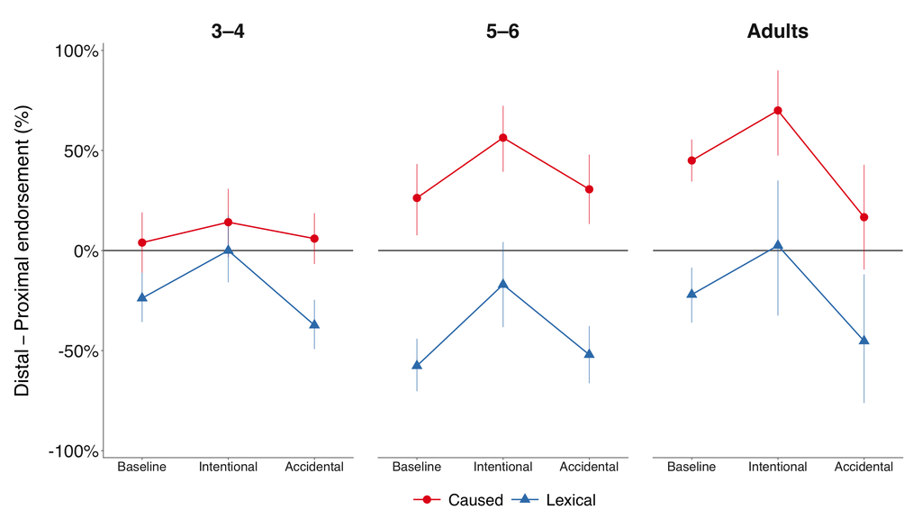

```r
p.role.preference.ci
```

```r
write_csv(df.role.preference.summary, file.path(synthesis_output, "caused_lexical_role_preference_values.csv"))
kable(df.role.preference.summary, digits = 6,
      caption = "Paired Distal-minus-Proximal endorsement: mean and backup 95% CI in percentage points; N counts participants")
```

Paired Distal-minus-Proximal endorsement: mean and backup 95% CI in percentage points; N counts participants

| study | population | stage | condition | measure | eligible_n | n | mean_pp | lower_pp | upper_pp |
| --- | --- | --- | --- | --- | --- | --- | --- | --- | --- |
| Study 1 | Children | 3–4 | Baseline | Caused | 63 | 63 | 3.968254 | -11.111111 | 19.047619 |
| Study 2 | Children | 3–4 | Intentional | Caused | 60 | 60 | 14.166667 | -3.333333 | 30.833333 |
| Study 2 | Children | 3–4 | Accidental | Caused | 67 | 67 | 5.970149 | -6.716418 | 18.656716 |
| Study 1 | Children | 3–4 | Baseline | Lexical | 63 | 63 | -23.809524 | -35.714286 | -11.111111 |
| Study 2 | Children | 3–4 | Intentional | Lexical | 60 | 60 | 0.000000 | -15.854167 | 17.500000 |
| Study 2 | Children | 3–4 | Accidental | Lexical | 67 | 67 | -37.313433 | -49.253731 | -24.626866 |
| Study 1 | Children | 5–6 | Baseline | Caused | 59 | 59 | 26.271186 | 7.627119 | 43.220339 |
| Study 2 | Children | 5–6 | Intentional | Caused | 47 | 47 | 56.382979 | 39.361702 | 72.340426 |
| Study 2 | Children | 5–6 | Accidental | Caused | 49 | 49 | 30.612245 | 13.265306 | 47.959184 |
| Study 1 | Children | 5–6 | Baseline | Lexical | 59 | 59 | -57.627119 | -70.338983 | -44.067797 |
| Study 2 | Children | 5–6 | Intentional | Lexical | 47 | 47 | -17.021277 | -38.297872 | 4.255319 |
| Study 2 | Children | 5–6 | Accidental | Lexical | 49 | 49 | -52.040816 | -66.326531 | -37.755102 |
| Study 1 | Adults | Adults | Baseline | Caused | 100 | 100 | 45.000000 | 34.500000 | 55.500000 |
| Study 2 | Adults | Adults | Intentional | Caused | 20 | 20 | 70.000000 | 47.500000 | 90.000000 |
| Study 2 | Adults | Adults | Accidental | Caused | 21 | 21 | 16.666667 | -9.523810 | 42.857143 |
| Study 1 | Adults | Adults | Baseline | Lexical | 100 | 100 | -22.000000 | -36.000000 | -8.500000 |
| Study 2 | Adults | Adults | Intentional | Lexical | 20 | 20 | 2.500000 | -32.500000 | 35.000000 |
| Study 2 | Adults | Adults | Accidental | Lexical | 21 | 21 | -45.238095 | -76.190476 | -11.904762 |

## Candidate 3: Single Cause sensitivity to intention across judgments

The effect is **100 × (Intentional group mean Yes − Accidental group mean Yes)**. The inputs are scenario-averaged participant means from Single Cause only. The two conditions contain different people, so the difference is between group means, not a within-person intention difference. Adults are the same working N=32 sample; these plots do not identify the historical N=30 exclusions.

For each stage, independently resample whole Intentional and Accidental participants 5,000 times and subtract the sampled group means. All four judgments stay together on each participant’s sampled row. A missing measure mean is ignored only for that measure, not for a participant’s other valid judgments. The table gives eligible and contributing Ns separately for the two conditions, plus source means and the resulting difference. The backup uses percentile intervals from the differences, including uncertainty in both groups. Lines describe separate cross-sectional age samples, not within-person change. Small fixed horizontal offsets separate overlapping measure points.

```r
df.single.sensitivity.means = df.stage.means %>% filter(study == "Single Cause")
check_labels(df.single.sensitivity.means$condition, condition_order, "Single Cause sensitivity condition")
stopifnot(setequal(as.character(df.single.sensitivity.means$stage), stage_order),
          !anyDuplicated(df.single.sensitivity.means[c("participant", "stage", "condition", "measure")]))
df.single.sensitivity.wide = df.single.sensitivity.means %>%
  select(stage, condition, participant, measure, yes_mean) %>%
  pivot_wider(names_from = measure, values_from = yes_mean) %>% arrange(stage, condition, participant)
RNGkind("Mersenne-Twister", "Inversion", "Rejection")
set.seed(bootstrap_seed + 10L)
sensitivity_intervals = list()
for (stage_name in stage_order) {
  rows = filter(df.single.sensitivity.wide, stage == stage_name)
  intentional = rows %>% filter(condition == "Intentional") %>% select(all_of(measure_order)) %>% as.matrix()
  accidental = rows %>% filter(condition == "Accidental") %>% select(all_of(measure_order)) %>% as.matrix()
  stopifnot(nrow(intentional) > 0L, nrow(accidental) > 0L)
  draws = replicate(bootstrap_replicates, {
    i = sample.int(nrow(intentional), replace = TRUE)
    a = sample.int(nrow(accidental), replace = TRUE)
    100 * (apply(intentional[i, , drop = FALSE], 2, mean_available) -
             apply(accidental[a, , drop = FALSE], 2, mean_available))
  })
  sensitivity_intervals[[stage_name]] = tibble(stage = stage_name, measure = measure_order,
    lower_pp = apply(draws, 1, quantile, probs = .025, na.rm = TRUE),
    upper_pp = apply(draws, 1, quantile, probs = .975, na.rm = TRUE))
}
df.single.sensitivity.summary = df.single.sensitivity.means %>%
  group_by(stage, condition, measure) %>%
  summarise(eligible_n = n(), n = sum(!is.na(yes_mean)), yes_mean = mean_available(yes_mean), .groups = "drop") %>%
  pivot_wider(names_from = condition, values_from = c(eligible_n, n, yes_mean)) %>%
  mutate(mean_pp = 100 * (yes_mean_Intentional - yes_mean_Accidental)) %>%
  left_join(bind_rows(sensitivity_intervals), by = c("stage", "measure"), relationship = "one-to-one") %>%
  mutate(study = "Single Cause", contrast = "Intentional minus Accidental",
         stage = factor(stage, levels = stage_order), measure = factor(measure, levels = measure_order)) %>%
  select(study, stage, contrast, measure, eligible_n_Intentional, eligible_n_Accidental,
         n_Intentional, n_Accidental, yes_mean_Intentional, yes_mean_Accidental, mean_pp, lower_pp, upper_pp) %>%
  arrange(stage, measure)
stopifnot(nrow(df.single.sensitivity.summary) == 12L,
          !anyDuplicated(df.single.sensitivity.summary[c("stage", "measure")]),
          all(df.single.sensitivity.summary$n_Intentional > 0L), all(df.single.sensitivity.summary$n_Accidental > 0L),
          all(dplyr::between(df.single.sensitivity.summary$mean_pp, -100, 100)),
          all(dplyr::between(df.single.sensitivity.summary$lower_pp, -100, 100)),
          all(dplyr::between(df.single.sensitivity.summary$upper_pp, -100, 100)))
```

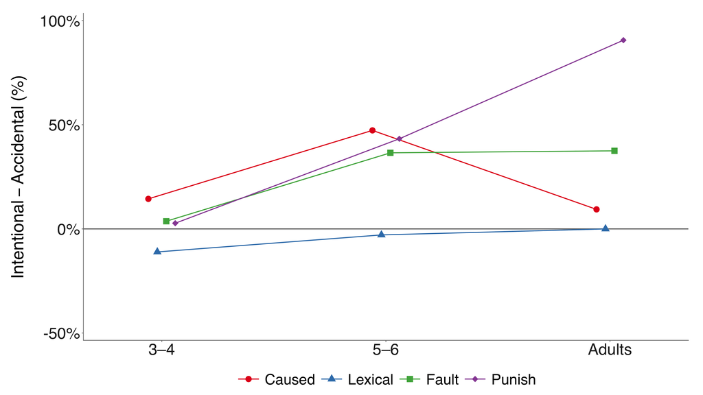

```r
df.single.sensitivity.plot = df.single.sensitivity.summary %>%
  mutate(plot_x = as.numeric(stage) + unname(sensitivity_offsets[as.character(measure)]))
plot_single_sensitivity = function(with_ci = FALSE) {
  p = ggplot(df.single.sensitivity.plot,
              aes(x = plot_x, y = mean_pp, color = measure, shape = measure, group = measure)) +
    geom_hline(yintercept = 0, color = "#666666", linewidth = .75) +
    geom_line(linewidth = .8)
  if (with_ci) {
    p = p + geom_linerange(aes(ymin = lower_pp, ymax = upper_pp),
                            linewidth = .55, alpha = .6, show.legend = FALSE)
  }
  p + geom_point(size = 4.5) +
    scale_color_manual(name = NULL, values = measure_colors, limits = measure_order, drop = FALSE) +
    scale_shape_manual(name = NULL, values = measure_shapes, limits = measure_order, drop = FALSE) +
    scale_x_continuous(breaks = 1:3, labels = stage_order, limits = c(.65, 3.35), expand = expansion(mult = 0)) +
    candidate_difference_scale(limits = c(-50, 100)) +
    labs(x = NULL, y = expression(plain("Intentional") - plain("Accidental") ~ plain("(%)"))) +
    talk_theme(intention_text_size)
}
stopifnot(all(df.single.sensitivity.summary$lower_pp >= -50),
          all(df.single.sensitivity.summary$upper_pp <= 100))
p.single.sensitivity = plot_single_sensitivity()
p.single.sensitivity.ci = plot_single_sensitivity(with_ci = TRUE)
save_talk(p.single.sensitivity, file.path(synthesis_output, "single_cause_intention_sensitivity"), 16, 9)
save_talk(p.single.sensitivity.ci, file.path(synthesis_output, "single_cause_intention_sensitivity_with_ci"), 16, 9)
p.single.sensitivity
```

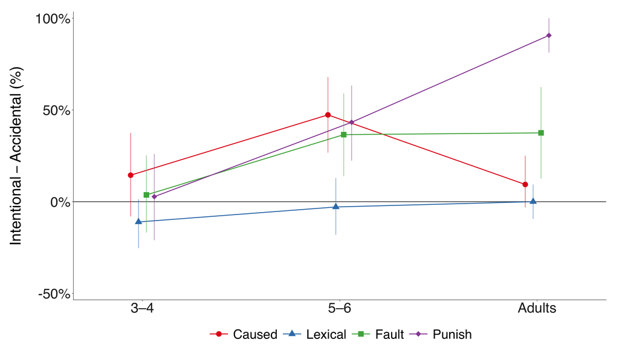

```r
p.single.sensitivity.ci
```

```r
write_csv(df.single.sensitivity.summary, file.path(synthesis_output, "single_cause_intention_sensitivity_values.csv"))
kable(select(df.single.sensitivity.summary, study, stage, contrast, measure,
              n_Intentional, n_Accidental, mean_pp, lower_pp, upper_pp), digits = 6,
      caption = "Single Cause intention sensitivity: mean difference and backup 95% CI in percentage points; separate condition Ns")
```

Single Cause intention sensitivity: mean difference and backup 95% CI in percentage points; separate condition Ns

| study | stage | contrast | measure | n_Intentional | n_Accidental | mean_pp | lower_pp | upper_pp |
| --- | --- | --- | --- | --- | --- | --- | --- | --- |
| Single Cause | 3–4 | Intentional minus Accidental | Caused | 24 | 26 | 14.423077 | -8.012821 | 37.500000 |
| Single Cause | 3–4 | Intentional minus Accidental | Lexical | 24 | 26 | -11.057692 | -25.320513 | 1.282051 |
| Single Cause | 3–4 | Intentional minus Accidental | Fault | 24 | 26 | 3.685897 | -16.830929 | 25.164263 |
| Single Cause | 3–4 | Intentional minus Accidental | Punish | 24 | 26 | 2.724359 | -20.993590 | 25.961538 |
| Single Cause | 5–6 | Intentional minus Accidental | Caused | 26 | 20 | 47.307692 | 26.730769 | 67.884615 |
| Single Cause | 5–6 | Intentional minus Accidental | Lexical | 26 | 20 | -2.884615 | -18.081731 | 12.884615 |
| Single Cause | 5–6 | Intentional minus Accidental | Fault | 26 | 20 | 36.538462 | 13.846154 | 59.038462 |
| Single Cause | 5–6 | Intentional minus Accidental | Punish | 26 | 20 | 43.269231 | 22.302885 | 63.269231 |
| Single Cause | Adults | Intentional minus Accidental | Caused | 16 | 16 | 9.375000 | -3.125000 | 25.000000 |
| Single Cause | Adults | Intentional minus Accidental | Lexical | 16 | 16 | 0.000000 | -9.375000 | 9.375000 |
| Single Cause | Adults | Intentional minus Accidental | Fault | 16 | 16 | 37.500000 | 12.500000 | 62.500000 |
| Single Cause | Adults | Intentional minus Accidental | Punish | 16 | 16 | 90.625000 | 81.250000 | 100.000000 |

# Presentation V2 — development from left to right

These are additional presentation versions of the three candidates above. The participant-first calculations, inclusion rules, age groups, source datasets, weights, adult samples and bootstrap intervals are unchanged. Each V2 table is checked against its earlier candidate CSV. No old figure or build is replaced. All new files go to `../../figures/study_comparison/presentation_v2/`.

The visual reference is cookie-task’s final Study 1 victim figure and Builds 00–04 in `current/figures/study1/change_from_45_final/`. Before implementing this section, both those PDFs and the actual `conference_theme()`, `plot_change_from_45_v2()`, `plot_change_from_45_final()` and `plot_final_developmental_change()` helpers in its `cookie_allocation.Rmd` were inspected. The resolved final theme, not an earlier prototype, supplies the constants below. This Rmd has no runtime dependency on cookie-task.

## Shared presentation settings and helper

The reference scales its 12-inch conference typography by **22/12** for the 22 × 8.5-inch canvas. This gives 44 pt base/tick/panel text, 47⅔ pt long axis titles, and 42⅙ pt legends. Panels have equal flexible widths with 1⅚ cm gaps. The childhood band ends exactly at the second child tick; Adults have the same one-unit spacing as the two childhood groups. No extra gap or opacity reduction is introduced. The reference’s final line figure uses no gtable edits; its separate bar helper’s .45-inch top spacer is not used here.

Long axis titles are wrapped over two lines to retain the reference’s large font. V2 C keeps the existing measure colors and geometric shapes, using their fillable equivalents so all marks can have the reference’s black outlines. The complete legend stays visible even when every data mark has alpha zero.

```r
talk_v2 = list(
  width = 22, height = 8.5, dpi = png_dpi, text_scale = 22 / 12,
  base_size = 11 * 22 / 12, tick_size = 24 * 22 / 12,
  panel_title_size = 24 * 22 / 12, axis_title_size = 26 * 22 / 12,
  legend_size = 23 * 22 / 12, panel_spacing_cm = 22 / 12,
  legend_key_cm = .85 * 22 / 12,
  line_width = 2.1, point_size = 6.2, point_stroke = 1.15,
  reference_width = 1, axis_width = .65, ci_width = .85,
  childhood_fill = "#F3F3F3", childhood_end = 2, x_padding = .25)
presentation_v2_output = file.path(synthesis_output, "presentation_v2")
dir.create(presentation_v2_output, recursive = TRUE, showWarnings = FALSE)

# Intentionally matched to cookie-task's FINAL conference-figure design:
# conference_theme(long_axis_title = TRUE, figure_width = 22), followed by
# plot_final_developmental_change()'s strip size, right margin and panel spacing.
theme_causal_verbs_talk = function() {
  s = talk_v2$text_scale
  theme_classic(base_family = "", base_size = talk_v2$base_size,
                base_line_size = .5, base_rect_size = .5) +
    theme(text = element_text(size = talk_v2$tick_size),
          axis.text = element_text(size = talk_v2$tick_size, color = "black"),
          axis.title = element_text(size = talk_v2$axis_title_size),
          strip.text = element_text(size = talk_v2$panel_title_size),
          strip.background = element_blank(),
          axis.line = element_line(linewidth = talk_v2$axis_width),
          axis.ticks = element_line(linewidth = talk_v2$axis_width),
          panel.spacing = grid::unit(talk_v2$panel_spacing_cm, "cm"),
          legend.position = "bottom", legend.justification = "center", legend.box.just = "center",
          legend.text = element_text(size = talk_v2$legend_size),
          legend.key.size = grid::unit(talk_v2$legend_key_cm, "cm"),
          plot.margin = margin(5, 14, 12, 12) * s + margin(r = talk_v2$tick_size / 2))
}

talk_v2_conditions = list(
  order = condition_order, colors = comparison_colors,
  fills = c(Intentional = comparison_colors[["Intentional"]], Accidental = NA),
  shapes = condition_shapes, lines = condition_lines)
talk_v2_contexts = list(
  order = c("Baseline", condition_order),
  colors = c(Baseline = "#666666", comparison_colors),
  fills = c(Baseline = "#666666", Intentional = comparison_colors[["Intentional"]], Accidental = NA),
  shapes = c(Baseline = 22, condition_shapes),
  lines = c(Baseline = "dotted", condition_lines))
talk_v2_measures = list(
  order = measure_order, colors = measure_colors, fills = measure_colors,
  shapes = c(Caused = 21, Lexical = 24, Fault = 22, Punish = 23),
  lines = setNames(rep("solid", 4), measure_order))
```

Every plot uses the same helper. Build visibility is encoded as alpha, leaving all panel levels, scales, legends and positions fixed. A connecting segment appears only when **both** its endpoints have been revealed. Main builds never contain an interval layer. CI backups use the same stored intervals and are saved separately; their ranges expand only when necessary to show every bound.

```r
plot_causal_verbs_talk = function(values, panel_order, style, y_limits, y_breaks,
                                  y_label, reference, step, with_ci = FALSE, x_offsets = NULL,
                                  mark_settings = talk_v2) {
  stopifnot(!anyDuplicated(values[c("panel", "series", "stage")]),
            setequal(as.character(values$stage), stage_order),
            all(values$series %in% style$order), all(values$panel %in% panel_order),
            all(dplyr::between(values$mean, y_limits[1], y_limits[2])))
  if (with_ci) stopifnot(all(values$lower >= y_limits[1]), all(values$upper <= y_limits[2]))
  points = values %>%
    mutate(panel = factor(panel, levels = panel_order),
           series = factor(series, levels = style$order),
           x = match(as.character(stage), stage_order), visible = as.numeric(reveal_step <= step))
  x_limits = c(1, 3)
  x_expansion = expansion(add = talk_v2$x_padding)
  band_end = talk_v2$childhood_end
  if (!is.null(x_offsets)) {
    # Optional fixed offsets separate overlapping measures in the NEW one-panel
    # family. Existing figures take the unchanged no-offset path.
    stopifnot(setequal(names(x_offsets), style$order), all(abs(x_offsets) < talk_v2$x_padding))
    points = points %>% mutate(x = x + unname(x_offsets[as.character(series)]))
    x_limits = c(1 - talk_v2$x_padding, 3 + talk_v2$x_padding)
    x_expansion = expansion(mult = 0)
    band_end = talk_v2$childhood_end + max(x_offsets)
  }
  segments = points %>% arrange(panel, series, x) %>% group_by(panel, series) %>%
    mutate(end_x = lead(x), end_y = lead(mean), end_step = lead(reveal_step)) %>% ungroup() %>%
    filter(!is.na(end_x)) %>% mutate(visible = as.numeric(pmax(reveal_step, end_step) <= step))
  p = ggplot(points, aes(x = x, y = mean, group = series)) +
    annotate("rect", xmin = -Inf, xmax = band_end, ymin = -Inf, ymax = Inf,
             fill = talk_v2$childhood_fill, color = NA) +
    geom_hline(yintercept = reference, color = "black", linetype = "dashed",
               linewidth = talk_v2$reference_width) +
    geom_segment(data = segments,
                 aes(xend = end_x, yend = end_y, color = series, linetype = series, alpha = visible),
                 linewidth = mark_settings$line_width, show.legend = TRUE)
  if (with_ci) {
    p = p + geom_linerange(aes(ymin = lower, ymax = upper, color = series, alpha = visible),
                            linewidth = talk_v2$ci_width, show.legend = FALSE)
  }
  p + geom_point(aes(fill = series, shape = series, alpha = visible),
                 size = mark_settings$point_size, color = "black", stroke = mark_settings$point_stroke,
                 show.legend = TRUE) +
    facet_wrap(~ panel, nrow = 1, drop = FALSE) +
    scale_alpha_identity(guide = "none") +
    scale_color_manual(NULL, values = style$colors, limits = style$order, drop = FALSE) +
    scale_fill_manual(NULL, values = style$fills, limits = style$order, drop = FALSE) +
    scale_shape_manual(NULL, values = style$shapes, limits = style$order, drop = FALSE) +
    scale_linetype_manual(NULL, values = style$lines, limits = style$order, drop = FALSE) +
    scale_x_continuous(breaks = 1:3, labels = stage_order, limits = x_limits,
                       expand = x_expansion) +
    scale_y_continuous(limits = y_limits, breaks = y_breaks,
                       labels = function(x) paste0(x, "%"), expand = expansion(mult = 0)) +
    labs(x = NULL, y = y_label) +
    guides(color = guide_legend(nrow = 1, override.aes = list(alpha = 1)),
           fill = guide_legend(nrow = 1), shape = guide_legend(nrow = 1), linetype = guide_legend(nrow = 1)) +
    theme_causal_verbs_talk()
}

save_presentation_v2 = function(plot, filename, width = talk_v2$width, height = talk_v2$height) {
  ggsave(paste0(filename, ".pdf"), plot = plot, width = width, height = height,
         device = grDevices::cairo_pdf, bg = "white")
  ggsave(paste0(filename, ".png"), plot = plot, width = width, height = height,
         device = ragg::agg_png, dpi = talk_v2$dpi, bg = "white")
}

save_presentation_v2_family = function(plot_function, stem, build_folder, build_names,
                                        width = talk_v2$width, height = talk_v2$height) {
  directory = file.path(presentation_v2_output, "builds", build_folder)
  dir.create(directory, recursive = TRUE, showWarnings = FALSE)
  final_step = length(build_names) - 1L
  main = plot_function(final_step)
  backup = plot_function(final_step, with_ci = TRUE)
  filename = file.path(presentation_v2_output, stem)
  save_presentation_v2(main, filename, width, height)
  save_presentation_v2(backup, paste0(filename, "_with_ci"), width, height)
  builds = lapply(0:final_step, function(step) {
    plot = plot_function(step)
    build_filename = file.path(directory, build_names[step + 1L])
    if (step == final_step) {
      stopifnot(identical(ggplot_build(plot)$data, ggplot_build(main)$data))
      # The last reveal is the full figure, including identical exported bytes.
      for (extension in c(".pdf", ".png")) {
        stopifnot(file.copy(paste0(filename, extension), paste0(build_filename, extension), overwrite = TRUE))
      }
    } else save_presentation_v2(plot, build_filename, width, height)
    plot
  })
  list(main = main, backup = backup, builds = builds)
}
```

## V2 A: punishment by causal target

Panels are Single Cause, Chain: Distal and Chain: Proximal. The unchanged 18 punishment means are percentages of Yes responses. Intention refers to the distal agent in the Proximal panel, as before. The axis spans 0–100%, with a 50% reference. Intentional and Accidental childhood trajectories enter first; the last reveal adds adult points and their connecting segments.

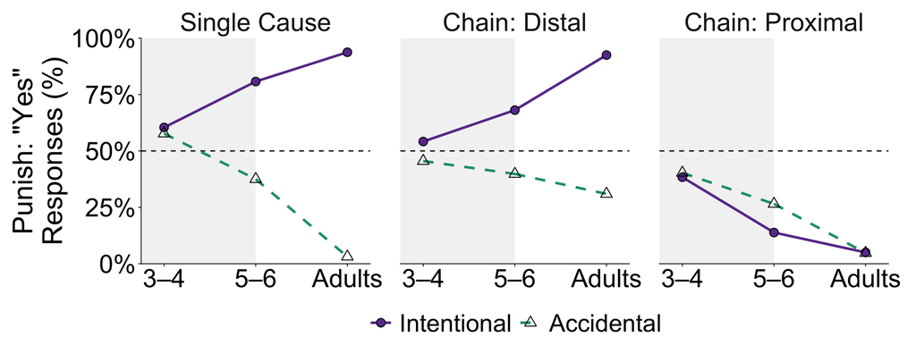

```r
df.v2.punishment = df.punishment.horizontal.values %>%
  transmute(panel = as.character(target), series = as.character(condition), stage,
            mean = yes_pct, lower = lower_pct, upper = upper_pct,
            reveal_step = if_else(stage == "Adults", 3L, match(condition, condition_order)))
plot_punishment_talk_v2 = function(step = 3L, with_ci = FALSE) {
  plot_causal_verbs_talk(df.v2.punishment, stage_target_order, talk_v2_conditions,
                         c(0, 100), seq(0, 100, 25), 'Punish: "Yes"\nResponses (%)', 50, step, with_ci)
}
p.v2.punishment = save_presentation_v2_family(
  plot_punishment_talk_v2, "punishment_causal_structure_talk_v2", "punishment_causal_structure",
  c("build00_blank", "build01_intentional_childhood", "build02_add_accidental_childhood", "build03_add_adults_full"))
p.v2.punishment$main
```

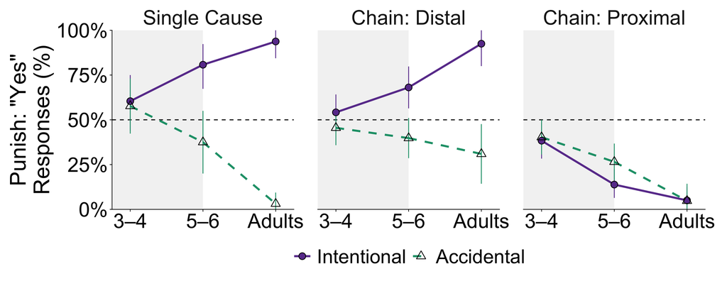

```r
p.v2.punishment$backup
```

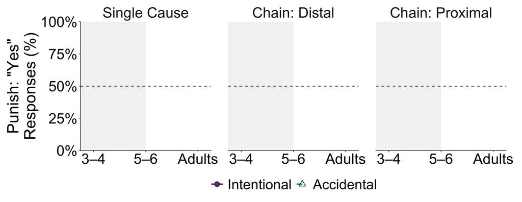

```r
p.v2.punishment$builds[[1]]
```

## V2 B: Caused and Lexical role preference

The unchanged role preference is participant/scenario paired Distal minus Proximal, expressed in percentage points. The two panels separate measures; Baseline, Intentional and Accidental now develop from left to right. The main range is ±80% (five major ticks), containing every mean with at least 10 points of padding. The CI backup expands to ±100% to show all existing bounds intact. No interval is truncated and no numerical value is changed.

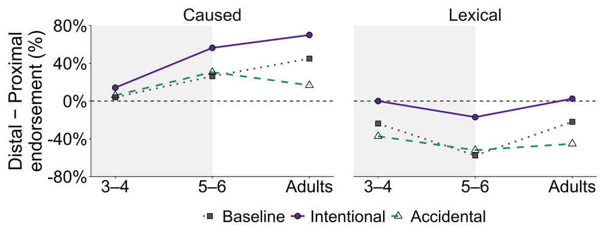

```r
df.v2.preference = df.role.preference.summary %>%
  transmute(panel = as.character(measure), series = as.character(condition), stage,
            mean = mean_pp, lower = lower_pp, upper = upper_pp,
            reveal_step = if_else(stage == "Adults", 4L, match(condition, talk_v2_contexts$order)))
plot_role_preference_talk_v2 = function(step = 4L, with_ci = FALSE) {
  limit = if (with_ci) 100 else 80
  plot_causal_verbs_talk(df.v2.preference, c("Caused", "Lexical"), talk_v2_contexts,
                         c(-limit, limit), seq(-limit, limit, length.out = 5),
                         "Distal − Proximal\nendorsement (%)", 0, step, with_ci)
}
p.v2.preference = save_presentation_v2_family(
  plot_role_preference_talk_v2, "caused_lexical_role_preference_talk_v2", "caused_lexical_role_preference",
  c("build00_blank", "build01_baseline_childhood", "build02_add_intentional_childhood",
    "build03_add_accidental_childhood", "build04_add_adults_full"))
p.v2.preference$main
```

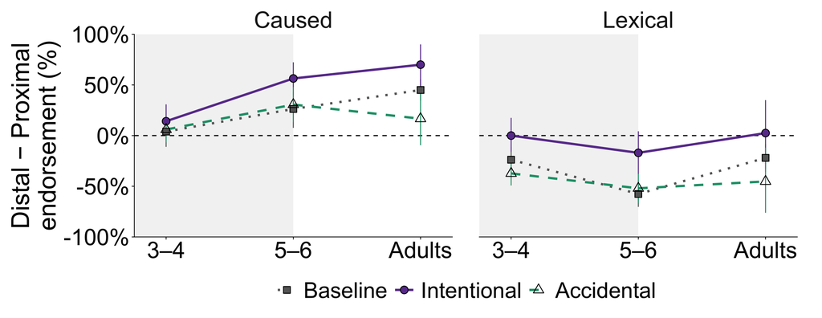

```r
p.v2.preference$backup
```

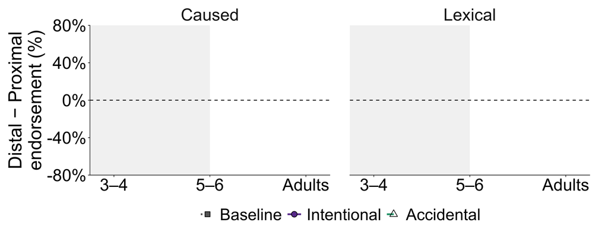

```r
p.v2.preference$builds[[1]]
```

## V2 C: Single Cause intention sensitivity

The unchanged Intentional-minus-Accidental contrasts have one trajectory per measure panel. The main range is −25% to +100%, which contains all observed means. The separate CI backup starts at −30%, since one existing lower bound is −25.320513 percentage points; all bounds remain visible. Main builds reveal the four childhood trajectories in measure order, then all adults together.

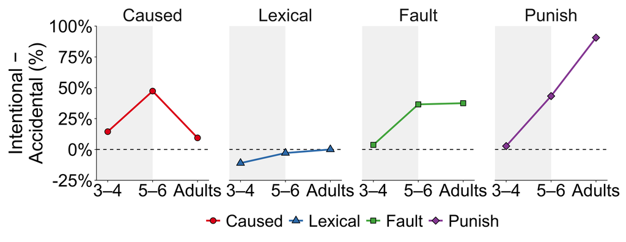

```r
df.v2.sensitivity = df.single.sensitivity.summary %>%
  transmute(panel = as.character(measure), series = as.character(measure), stage,
            mean = mean_pp, lower = lower_pp, upper = upper_pp,
            reveal_step = if_else(stage == "Adults", 5L, match(measure, measure_order)))
plot_single_sensitivity_talk_v2 = function(step = 5L, with_ci = FALSE) {
  plot_causal_verbs_talk(df.v2.sensitivity, measure_order, talk_v2_measures,
                         c(if (with_ci) -30 else -25, 100), seq(-25, 100, 25),
                         "Intentional −\nAccidental (%)", 0, step, with_ci)
}
p.v2.sensitivity = save_presentation_v2_family(
  plot_single_sensitivity_talk_v2, "single_cause_intention_sensitivity_talk_v2", "single_cause_intention_sensitivity",
  c("build00_blank", "build01_caused_childhood", "build02_add_lexical_childhood",
    "build03_add_fault_childhood", "build04_add_punish_childhood", "build05_add_adults_full"))
p.v2.sensitivity$main
```

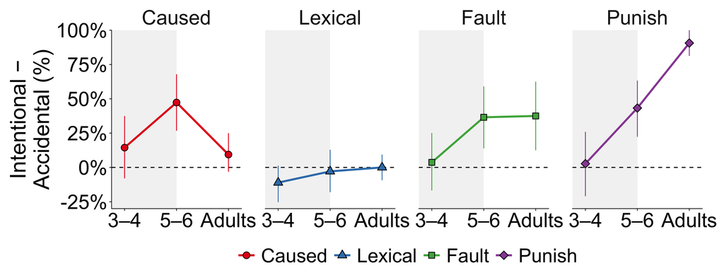

```r
p.v2.sensitivity$backup
```

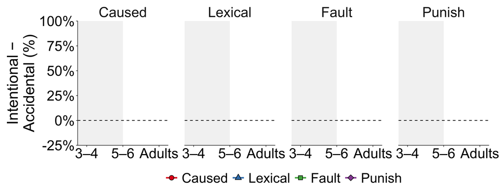

```r
p.v2.sensitivity$builds[[1]]
```

## V2 numerical identity and fixed-build checks

These files repeat the earlier candidate tables exactly, retaining their means, Ns and 95% intervals. They are included beside the V2 figures for convenience; the Rmd does not rerun scoring or bootstrapping for the redesign.

```r
v2_tables = list(
  punishment_causal_structure = df.punishment.horizontal.values,
  caused_lexical_role_preference = df.role.preference.summary,
  single_cause_intention_sensitivity = df.single.sensitivity.summary)
v2_source_stems = c("punishment_causal_structure_horizontal", "caused_lexical_role_preference", "single_cause_intention_sensitivity")
for (i in seq_along(v2_tables)) {
  destination = file.path(presentation_v2_output, paste0(names(v2_tables)[i], "_talk_v2_values.csv"))
  source = file.path(synthesis_output, paste0(v2_source_stems[i], "_values.csv"))
  original = read_csv(source, show_col_types = FALSE)
  stopifnot(identical(names(original), names(v2_tables[[i]])))
  for (column in names(original)) {
    value = v2_tables[[i]][[column]]
    if (is.factor(value)) value = as.character(value)
    same_value = all.equal(unname(value), unname(original[[column]]), tolerance = 1e-12)
    if (!isTRUE(same_value)) stop("V2 numerical mismatch in ", names(v2_tables)[i], ": ", column,
                                 " — ", paste(same_value, collapse = "; "))
  }
  # Keep the original full-precision CSV bytes rather than round-trip its decimals.
  stopifnot(file.copy(source, destination, overwrite = TRUE),
            identical(readLines(source), readLines(destination)))
}
# Check all visibility transitions while retaining identical physical geometry.
check_presentation_builds = function(family, expected_points) {
  full_built = ggplot_build(family$main)
  full_grob = ggplotGrob(family$main)
  counts = integer(length(family$builds))
  for (i in seq_along(family$builds)) {
    plot = family$builds[[i]]
    built = ggplot_build(plot)
    grob = ggplotGrob(plot)
    stopifnot(identical(built$layout$layout, full_built$layout$layout),
              identical(grob$layout, full_grob$layout),
              isTRUE(all.equal(grid::convertWidth(grob$widths, "cm", valueOnly = TRUE),
                               grid::convertWidth(full_grob$widths, "cm", valueOnly = TRUE))),
              isTRUE(all.equal(grid::convertHeight(grob$heights, "cm", valueOnly = TRUE),
                               grid::convertHeight(full_grob$heights, "cm", valueOnly = TRUE))))
    for (panel in seq_along(built$layout$panel_params)) {
      stopifnot(identical(built$layout$panel_params[[panel]]$x.range, full_built$layout$panel_params[[panel]]$x.range),
                identical(built$layout$panel_params[[panel]]$y.range, full_built$layout$panel_params[[panel]]$y.range))
    }
    for (layer in seq_along(built$data)) {
      a = built$data[[layer]]
      b = full_built$data[[layer]]
      stopifnot(identical(a[setdiff(names(a), "alpha")], b[setdiff(names(b), "alpha")]))
      if ("alpha" %in% names(a) && !all(is.na(a$alpha))) {
        stopifnot(all(a$alpha %in% c(0, 1)))
        if (i > 1) stopifnot(all(a$alpha >= ggplot_build(family$builds[[i - 1]])$data[[layer]]$alpha))
      }
    }
    point_layer = which(vapply(plot$layers, function(x) inherits(x$geom, "GeomPoint"), logical(1)))
    counts[i] = sum(built$data[[point_layer]]$alpha == 1)
    stopifnot(!any(vapply(plot$layers, function(x) inherits(x$geom, "GeomLinerange"), logical(1))))
  }
  stopifnot(identical(counts, expected_points),
            identical(ggplot_build(family$builds[[length(family$builds)]])$data, full_built$data))
  TRUE
}
stopifnot(check_presentation_builds(p.v2.punishment, c(0L, 6L, 12L, 18L)),
          check_presentation_builds(p.v2.preference, c(0L, 4L, 8L, 12L, 18L)),
          check_presentation_builds(p.v2.sensitivity, c(0L, 2L, 4L, 6L, 8L, 12L)))
kable(tibble(figure = names(v2_tables), points = c(18, 18, 12), builds = c(4, 5, 6),
             numerical_values_unchanged = TRUE, fixed_build_geometry = TRUE, final_build_equals_full = TRUE))
```

| figure | points | builds | numerical_values_unchanged | fixed_build_geometry | final_build_equals_full |
| --- | --- | --- | --- | --- | --- |
| punishment_causal_structure | 18 | 4 | TRUE | TRUE | TRUE |
| caused_lexical_role_preference | 18 | 5 | TRUE | TRUE | TRUE |
| single_cause_intention_sensitivity | 12 | 6 | TRUE | TRUE | TRUE |

# Additional presentation syntheses — all judgments and one-panel sensitivity

These two new families leave every previous figure and build unchanged, including punishment V2, the focused two-panel Caused/Lexical figure and the four-panel Single Cause sensitivity figure. They reuse the exact final cookie-task presentation settings and shared plotting/build helpers above. The reference helper chain and its final Study 1 victim builds were rechecked before this addition; no cookie-task files or analysis choices are changed.

## Four judgments: developmental Distal-minus-Proximal role preference

Use the same `role_preference_means()` helper for all four judgments: subtract binary Proximal from binary Distal **within scenario**, average available paired scenarios within participant, then average participant contrasts within study/stage/condition. Both/Neither give zero. A missing role affects only its scenario’s contrast; other valid scenarios and judgments remain usable.

Caused/Lexical reuse their existing means and confidence intervals exactly. Only the newly displayed Fault/Punish contrasts require additional intervals. They use the unchanged 5,000-draw participant-bootstrap percentile procedure, with a separate fixed seed (`bootstrap_seed + 11`) so adding measures does not alter earlier Monte Carlo intervals. Inclusion, repeats, coding, age groups, weights and adult samples remain as documented above. Study 2 adults remain the earlier pilot; the missing main adult data and handoff gaps stay unresolved.

```r
df.role.preference.all.responses = bind_rows(
  df.study1.adults.responses, df.study1.children.responses,
  df.study2.adults.responses, df.study2.children.responses) %>%
  filter(population == "Adults" | age %in% 3:6)
check_labels(df.role.preference.all.responses$study, c("Study 1", "Study 2"), "all-measure source study")
check_labels(df.role.preference.all.responses$measure, measure_order, "all-measure judgment")
df.role.preference.all.means = role_preference_means(df.role.preference.all.responses) %>%
  mutate(stage = stage_group(population, age),
         condition = factor(condition, levels = talk_v2_contexts$order),
         measure = factor(measure, levels = measure_order))
stopifnot(!anyNA(df.role.preference.all.means$stage), !anyNA(df.role.preference.all.means$condition),
          !anyDuplicated(df.role.preference.all.means[c("study", "participant", "condition", "measure")]),
          setequal(as.character(df.role.preference.all.means$stage), stage_order),
          all(df.role.preference.all.means$paired_scenarios %in% 0:2))
RNGkind("Mersenne-Twister", "Inversion", "Rejection")
set.seed(bootstrap_seed + 11L)
df.role.preference.additional = df.role.preference.all.means %>%
  filter(measure %in% c("Fault", "Punish")) %>%
  arrange(study, stage, condition, measure, participant) %>%
  group_by(study, population, stage, condition, measure) %>%
  summarise(eligible_n = n(), summary = list(bootstrap_mean(role_difference)), .groups = "drop") %>%
  unnest_wider(summary) %>%
  transmute(study, population, stage, condition, measure, eligible_n, n,
            mean_pp = 100 * mean, lower_pp = 100 * lower, upper_pp = 100 * upper)
df.role.preference.all.summary = bind_rows(
  mutate(df.role.preference.summary, measure = as.character(measure)),
  mutate(df.role.preference.additional, measure = as.character(measure))) %>%
  mutate(measure = factor(measure, levels = measure_order)) %>% arrange(stage, measure, condition)
stopifnot(nrow(df.role.preference.all.summary) == 36L,
          !anyDuplicated(df.role.preference.all.summary[c("stage", "condition", "measure")]),
          all(dplyr::between(df.role.preference.all.summary$mean_pp, -100, 100)),
          all(dplyr::between(df.role.preference.all.summary$lower_pp, -100, 100)),
          all(dplyr::between(df.role.preference.all.summary$upper_pp, -100, 100)))
# These snapshots contain complete scenario pairs. Therefore the paired contrast
# must also equal the difference of the already validated role-specific means.
stopifnot(all(df.role.preference.all.means$paired_scenarios == 2L))
df.role.preference.existing_check = df.stage.summary %>%
  filter(study %in% c("Study 1", "Study 2")) %>%
  select(study, stage, condition, measure, role, mean, n) %>%
  pivot_wider(names_from = role, values_from = c(mean, n)) %>%
  mutate(expected_pp = 100 * (mean_Distal - mean_Proximal))
df.role.preference.all.check = df.role.preference.all.summary %>%
  left_join(df.role.preference.existing_check, by = c("study", "stage", "condition", "measure"),
            relationship = "one-to-one")
stopifnot(nrow(df.role.preference.all.check) == 36L,
          all(abs(df.role.preference.all.check$mean_pp - df.role.preference.all.check$expected_pp) < 1e-10),
          all(df.role.preference.all.check$n == df.role.preference.all.check$n_Distal),
          all(df.role.preference.all.check$n == df.role.preference.all.check$n_Proximal))
shared = filter(df.role.preference.all.summary, measure %in% c("Caused", "Lexical"))
for (column in names(df.role.preference.summary)) {
  old = df.role.preference.summary[[column]]
  new = shared[[column]]
  if (is.factor(old)) old = as.character(old)
  if (is.factor(new)) new = as.character(new)
  stopifnot(identical(unname(old), unname(new)))
}
# Derive a clean symmetric scale from the data, allowing five points of padding
# where the theoretical -100..100 range permits it.
role_all_main_limit = min(100, ceiling((max(abs(df.role.preference.all.summary$mean_pp)) + 5) / 10) * 10)
role_all_ci_limit = max(role_all_main_limit,
  ceiling(max(abs(c(df.role.preference.all.summary$lower_pp, df.role.preference.all.summary$upper_pp))) / 10) * 10)
```

The observed means range from -57.627 to 95 percentage points. The data-derived symmetric main range is therefore ±100%, with five major ticks. It is not inherited from a ±100% default. The separate CI backup shows every bound without clipping. Positive values favor Distal; negative values favor Proximal. Context colors/shapes/line types match the existing two-panel figure exactly.

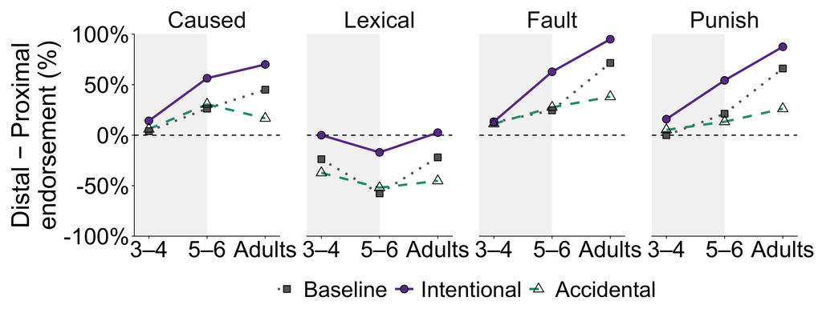

```r
# Reveal Accidental before Intentional in this all-measure build family only.
role_all_reveal_order = c("Baseline", "Accidental", "Intentional")
df.role.preference.all.plot = df.role.preference.all.summary %>%
  transmute(panel = as.character(measure), series = as.character(condition), stage,
            mean = mean_pp, lower = lower_pp, upper = upper_pp,
            reveal_step = if_else(stage == "Adults", 4L, match(condition, role_all_reveal_order)))
plot_role_preference_all = function(step = 4L, with_ci = FALSE) {
  limit = if (with_ci) role_all_ci_limit else role_all_main_limit
  plot_causal_verbs_talk(df.role.preference.all.plot, measure_order, talk_v2_contexts,
                         c(-limit, limit), seq(-limit, limit, length.out = 5),
                         "Distal − Proximal\nendorsement (%)", 0, step, with_ci)
}
p.role.preference.all = save_presentation_v2_family(
  plot_role_preference_all, "role_preference_all_measures_talk_v2", "role_preference_all_measures",
  c("build00_blank", "build01_baseline_childhood", "build02_add_accidental_childhood",
    "build03_add_intentional_childhood", "build04_add_adults_full"))
p.role.preference.all$main
```

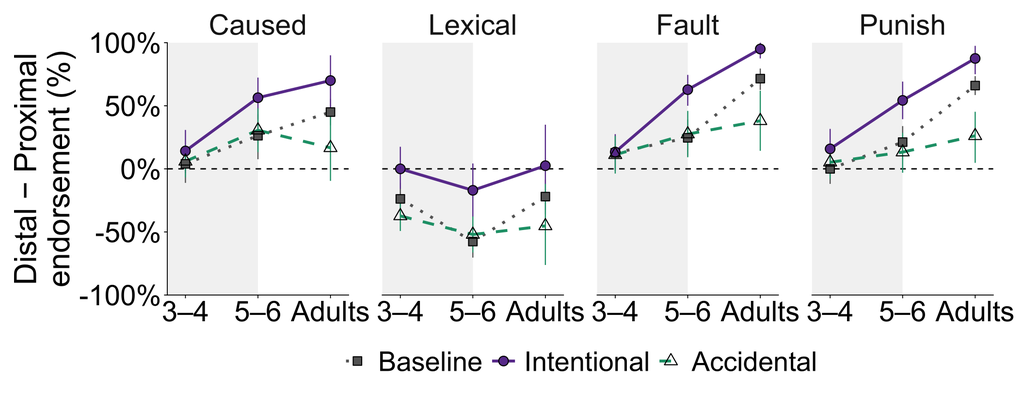

```r
p.role.preference.all$backup
```

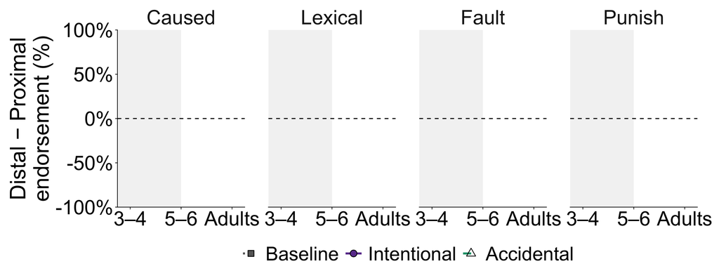

```r
p.role.preference.all$builds[[1]]
```

```r
write_csv(df.role.preference.all.summary,
          file.path(presentation_v2_output, "role_preference_all_measures_talk_v2_values.csv"))
kable(select(df.role.preference.all.summary, study, stage, condition, measure, n, mean_pp, lower_pp, upper_pp),
      digits = 4, caption = "All judgments: paired Distal-minus-Proximal mean and 95% CI (pp); participant N; CSV retains full precision")
```

All judgments: paired Distal-minus-Proximal mean and 95% CI (pp); participant N; CSV retains full precision

| study | stage | condition | measure | n | mean_pp | lower_pp | upper_pp |
| --- | --- | --- | --- | --- | --- | --- | --- |
| Study 1 | 3–4 | Baseline | Caused | 63 | 3.9683 | -11.1111 | 19.0476 |
| Study 2 | 3–4 | Intentional | Caused | 60 | 14.1667 | -3.3333 | 30.8333 |
| Study 2 | 3–4 | Accidental | Caused | 67 | 5.9701 | -6.7164 | 18.6567 |
| Study 1 | 3–4 | Baseline | Lexical | 63 | -23.8095 | -35.7143 | -11.1111 |
| Study 2 | 3–4 | Intentional | Lexical | 60 | 0.0000 | -15.8542 | 17.5000 |
| Study 2 | 3–4 | Accidental | Lexical | 67 | -37.3134 | -49.2537 | -24.6269 |
| Study 1 | 3–4 | Baseline | Fault | 63 | 12.6984 | 0.0000 | 26.1905 |
| Study 2 | 3–4 | Intentional | Fault | 60 | 13.3333 | -1.6667 | 27.5000 |
| Study 2 | 3–4 | Accidental | Fault | 67 | 11.1940 | -3.7313 | 26.1194 |
| Study 1 | 3–4 | Baseline | Punish | 63 | 0.0000 | -11.9048 | 11.9048 |
| Study 2 | 3–4 | Intentional | Punish | 60 | 15.8333 | 0.0000 | 31.6667 |
| Study 2 | 3–4 | Accidental | Punish | 67 | 5.2239 | -8.2090 | 19.4030 |
| Study 1 | 5–6 | Baseline | Caused | 59 | 26.2712 | 7.6271 | 43.2203 |
| Study 2 | 5–6 | Intentional | Caused | 47 | 56.3830 | 39.3617 | 72.3404 |
| Study 2 | 5–6 | Accidental | Caused | 49 | 30.6122 | 13.2653 | 47.9592 |
| Study 1 | 5–6 | Baseline | Lexical | 59 | -57.6271 | -70.3390 | -44.0678 |
| Study 2 | 5–6 | Intentional | Lexical | 47 | -17.0213 | -38.2979 | 4.2553 |
| Study 2 | 5–6 | Accidental | Lexical | 49 | -52.0408 | -66.3265 | -37.7551 |
| Study 1 | 5–6 | Baseline | Fault | 59 | 24.5763 | 10.1483 | 38.9831 |
| Study 2 | 5–6 | Intentional | Fault | 47 | 62.7660 | 50.0000 | 74.4681 |
| Study 2 | 5–6 | Accidental | Fault | 49 | 27.5510 | 9.1837 | 45.9184 |
| Study 1 | 5–6 | Baseline | Punish | 59 | 21.1864 | 8.4746 | 33.8983 |
| Study 2 | 5–6 | Intentional | Punish | 47 | 54.2553 | 39.3617 | 69.1489 |
| Study 2 | 5–6 | Accidental | Punish | 49 | 13.2653 | -3.0612 | 28.5714 |
| Study 1 | Adults | Baseline | Caused | 100 | 45.0000 | 34.5000 | 55.5000 |
| Study 2 | Adults | Intentional | Caused | 20 | 70.0000 | 47.5000 | 90.0000 |
| Study 2 | Adults | Accidental | Caused | 21 | 16.6667 | -9.5238 | 42.8571 |
| Study 1 | Adults | Baseline | Lexical | 100 | -22.0000 | -36.0000 | -8.5000 |
| Study 2 | Adults | Intentional | Lexical | 20 | 2.5000 | -32.5000 | 35.0000 |
| Study 2 | Adults | Accidental | Lexical | 21 | -45.2381 | -76.1905 | -11.9048 |
| Study 1 | Adults | Baseline | Fault | 100 | 71.5000 | 62.5000 | 79.5000 |
| Study 2 | Adults | Intentional | Fault | 20 | 95.0000 | 87.5000 | 100.0000 |
| Study 2 | Adults | Accidental | Fault | 21 | 38.0952 | 14.2857 | 61.9048 |
| Study 1 | Adults | Baseline | Punish | 100 | 66.0000 | 58.5000 | 73.5000 |
| Study 2 | Adults | Intentional | Punish | 20 | 87.5000 | 75.0000 | 97.5000 |
| Study 2 | Adults | Accidental | Punish | 21 | 26.1905 | 4.7619 | 45.2381 |

## Single Cause: one-panel comparison of intention sensitivity

This additional, preferred talk candidate overlays the four judgments in one panel. It reuses **all 12 existing Single Cause estimates and intervals**; no new scoring, resampling or participant selection occurs. Colors and outlined shapes represent measures, with solid lines for all four. The prior four-panel V2 figure remains available as a separate presentation option.

Start from the observed means with five points of padding, rounded outward to multiples of 25. Expand that range only as needed for the existing interval bounds, then use the **same axes for the main, all builds and CI backup**. Main builds contain no intervals. Small fixed measure offsets separate nearby markers and their CI bars without changing any y-value. The broad childhood band includes both child groups and ends before Adults.

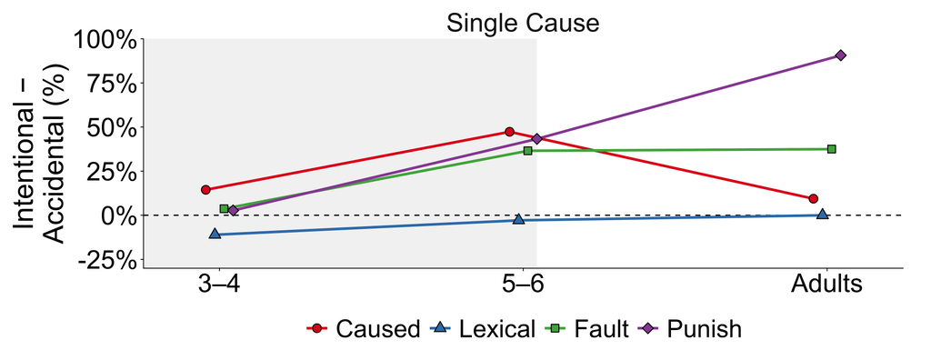

```r
df.single.onepanel = df.v2.sensitivity %>% mutate(panel = "Single Cause")
single_onepanel_main_limits = c(
  floor((min(df.single.onepanel$mean) - 5) / 25) * 25,
  ceiling((max(df.single.onepanel$mean) + 5) / 25) * 25)
single_onepanel_ci_limits = c(
  min(single_onepanel_main_limits[1], floor(min(df.single.onepanel$lower) / 5) * 5),
  max(single_onepanel_main_limits[2], ceiling(max(df.single.onepanel$upper) / 5) * 5))
single_onepanel_offsets = c(Caused = -.045, Lexical = -.015, Fault = .015, Punish = .045)
plot_single_sensitivity_onepanel = function(step = 5L, with_ci = FALSE, mark_settings = talk_v2) {
  plot_causal_verbs_talk(df.single.onepanel, "Single Cause", talk_v2_measures,
                         single_onepanel_ci_limits,
                         seq(single_onepanel_main_limits[1], single_onepanel_main_limits[2], 25),
                         "Intentional −\nAccidental (%)", 0, step, with_ci,
                         x_offsets = single_onepanel_offsets, mark_settings = mark_settings)
}
p.single.onepanel = save_presentation_v2_family(
  plot_single_sensitivity_onepanel, "single_cause_intention_sensitivity_onepanel_talk_v3",
  "single_cause_intention_sensitivity_onepanel",
  c("build00_blank", "build01_caused_childhood", "build02_add_lexical_childhood",
    "build03_add_fault_childhood", "build04_add_punish_childhood", "build05_add_adults_full"))
p.single.onepanel$main
```

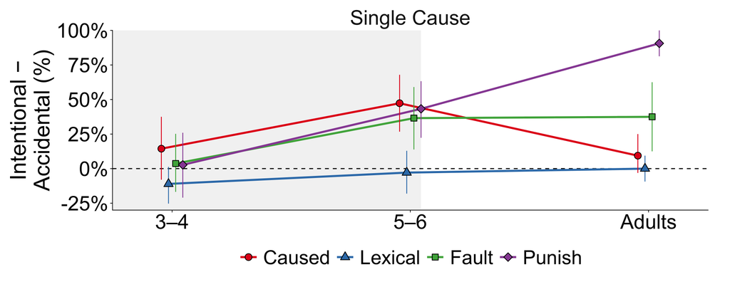

```r
p.single.onepanel$backup
```

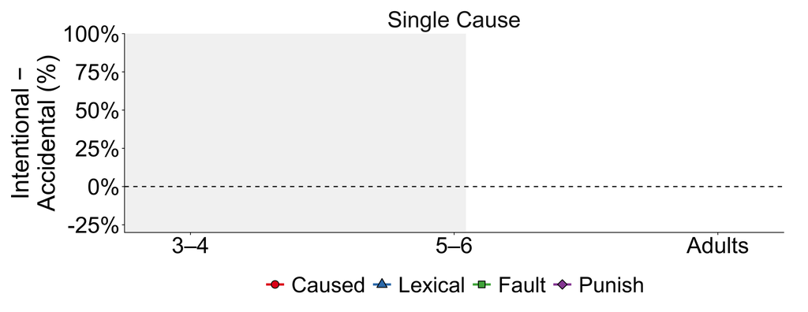

```r
p.single.onepanel$builds[[1]]
```

Observed Single Cause sensitivity ranges from -11.058 to 90.625 percentage points. Both main and backup use a -30% to 100% range: the existing −25.320513 lower CI bound requires the small extension below the −25% major tick. There is no geometry shift when swapping main and backup.

```r
onepanel_source = file.path(presentation_v2_output, "single_cause_intention_sensitivity_talk_v2_values.csv")
onepanel_destination = file.path(presentation_v2_output, "single_cause_intention_sensitivity_onepanel_talk_v3_values.csv")
stopifnot(file.copy(onepanel_source, onepanel_destination, overwrite = TRUE),
          identical(readLines(onepanel_source), readLines(onepanel_destination)),
          identical(df.single.onepanel$mean, df.v2.sensitivity$mean),
          identical(df.single.onepanel$lower, df.v2.sensitivity$lower),
          identical(df.single.onepanel$upper, df.v2.sensitivity$upper))
kable(select(df.single.sensitivity.summary, stage, measure, n_Intentional, n_Accidental, mean_pp, lower_pp, upper_pp),
      digits = 4, caption = "Single Cause: unchanged Intentional-minus-Accidental mean and 95% CI (pp); participant Ns")
```

Single Cause: unchanged Intentional-minus-Accidental mean and 95% CI (pp); participant Ns

| stage | measure | n_Intentional | n_Accidental | mean_pp | lower_pp | upper_pp |
| --- | --- | --- | --- | --- | --- | --- |
| 3–4 | Caused | 24 | 26 | 14.4231 | -8.0128 | 37.5000 |
| 3–4 | Lexical | 24 | 26 | -11.0577 | -25.3205 | 1.2821 |
| 3–4 | Fault | 24 | 26 | 3.6859 | -16.8309 | 25.1643 |
| 3–4 | Punish | 24 | 26 | 2.7244 | -20.9936 | 25.9615 |
| 5–6 | Caused | 26 | 20 | 47.3077 | 26.7308 | 67.8846 |
| 5–6 | Lexical | 26 | 20 | -2.8846 | -18.0817 | 12.8846 |
| 5–6 | Fault | 26 | 20 | 36.5385 | 13.8462 | 59.0385 |
| 5–6 | Punish | 26 | 20 | 43.2692 | 22.3029 | 63.2692 |
| Adults | Caused | 16 | 16 | 9.3750 | -3.1250 | 25.0000 |
| Adults | Lexical | 16 | 16 | 0.0000 | -9.3750 | 9.3750 |
| Adults | Fault | 16 | 16 | 37.5000 | 12.5000 | 62.5000 |
| Adults | Punish | 16 | 16 | 90.6250 | 81.2500 | 100.0000 |

```r
stopifnot(check_presentation_builds(p.role.preference.all, c(0L, 8L, 16L, 24L, 36L)),
          check_presentation_builds(p.single.onepanel, c(0L, 2L, 4L, 6L, 8L, 12L)))
```